# Ferropenia

Andrea

2024-03-21

```r
#Librerías necesarias
library(dplyr)
library(readxl)
library(ggplot2)
library(GGally)
library(kableExtra)
library(corrplot)
library(patchwork)
library(ggpubr)

library(tm)
library(stringr)
library(class)
library(gmodels)
library(ROCR)
library(caret)
library(kernlab)
```

# 1. Creación del dataset

## 1.1 Importación del excel

Partimos de un excel generado por el Sistema Informático del Laboratorio (SIL) en el que se puso como condición que los pacientes tuvieran un VCM por debajo del rango de normalidad, tanto bajo como muy bajo

```r
ferropenia = read_excel("~/aaaatalasemias/TFM/Ferropenia2.xls",
col_types = c("text", "text", "numeric","text", "text", "text", "text", "text", "text", "numeric", "numeric", "numeric", "numeric", "numeric", "numeric", "numeric", "numeric", "numeric", "numeric", "numeric", "numeric", "numeric", "text", "text", "numeric", "numeric", "numeric", "numeric", "numeric", "numeric", "numeric"))
str (ferropenia)
```

```
## tibble [7,977 × 31] (S3: tbl_df/tbl/data.frame)
##  $ Fecha Formato Corto   : chr [1:7977] "17/8/16" "17/8/16" "18/8/16" "18/8/16" ...
##  $ Número                : chr [1:7977] "00821594" "00821548" "00821711" "00821611" ...
##  $ Edad(numero)          : num [1:7977] 32 3 14 4 14 3 2 1 15 15 ...
##  $ Edad(2parte)          : chr [1:7977] "años" "meses" "años" "años" ...
##  $ Sexo del Paciente     : chr [1:7977] "F" "M" "F" "F" ...
##  $ NHC                   : chr [1:7977] "1694934" "564182" "312844" "564323" ...
##  $ Servicio              : chr [1:7977] "CASA" "PEDIATRIA HOSPITALIZACION" "NO CODIFICADO TG" "PEDIATRIA CONSULTA (237)" ...
##  $ Diagnóstico           : chr [1:7977] "NO CONSTA EN TG" "ANEMIA" "NO CONSTA EN TG" "TUBERCULOSIS" ...
##  $ Observaciones petición: chr [1:7977] NA "Control de anemia (Hb de 5 al ingreso)" NA "mantoux poistiivo. Rx normal. previo al inicio del tratamiento." ...
##  $ HTIE                  : num [1:7977] 5.29 4.15 5.17 5.24 5.23 4.86 5.28 4.62 3.74 5.1 ...
##  $ HGB                   : num [1:7977] 13.5 11.1 10.6 13.3 12.8 13.6 8.5 8.8 10.2 14 ...
##  $ VCM                   : num [1:7977] 75.5 74.2 65.8 75.7 71.3 78 56.2 61.6 81.8 80.1 ...
##  $ HCM                   : num [1:7977] 25.5 26.7 20.4 25.4 24.5 28 16.1 19 27.2 27.5 ...
##  $ IDM                   : num [1:7977] 13.8 17.2 17.8 15.8 14.2 13.8 20.3 19.1 14.3 14 ...
```

[output cut: 17 more lines]

## 1.2 Pasos a seguir para conseguir el Dataset objetivo:

### 1.2.1. Excluir a los pacientes que les falte alguna prueba necesaria para filtrar

Necesitaremos los parámetros: Hematíes, hemoglobina, VCM, HCM, ADE, hematocrito, CHCM, PCR, ferritina, IST, además de la edad y sexo del paciente que serán necesarios para tener en cuenta los valores de referencia.

```r
# Definimos las variables necesarias en un vector
pruebas_necesarias = c("HTIE", "HGB", "VCM", "HCM", "IDM", "HTCO", "CHCM", "PCR", "FERR", "ISTR")

# Nos quedamos solo con los pacientes que tengan todas las pruebas
ferropenia_filtrado = ferropenia[complete.cases(ferropenia[, pruebas_necesarias]), ]
```

### 1.2.2. Pasar todas las edades de días (x/365) y meses (x/12) a años

```r
# Hacemos una función para que la edad esté en años
calcular_edad_years=function(numero, letra){
  if (letra == "mes" || letra == "meses") {
    edad_ajustada = numero / 12
  } else if (letra == "días") {
    edad_ajustada = numero / 365
  } else {
    edad_ajustada = numero  # Si no se especifica "mes" o "días", retornar el mismo valor
  }

  return(edad_ajustada)

}

# creamos una columna nueva con la edad ajustada
ferropenia_filtrado$edad_normalizada <- mapply(calcular_edad_years,
                                        ferropenia_filtrado$`Edad(numero)`,
                                        ferropenia_filtrado$`Edad(2parte)`)
```

### 1.2.3. Restringir la edad de los pacientes a >15 días -18 años

Este rango etario se lleva a cabo por ser el rango de edades de los que disponemos bibliografía de rangos de referencia de las variables utilizadas.

```r
ferropenia_filtrado = filter(ferropenia_filtrado, edad_normalizada >= (15/365) & edad_normalizada <=18)
```

### 1.2.4. Excluir a los pacientes con una PCR >1,5

Se realiza para descartar una posible inflamación/infección

```r
ferropenia_filtrado = filter(ferropenia_filtrado, PCR<1.5)
```

### 1.2.5. Eliminar pacientes duplicados

```r
#Seleccionamos los duplicados, quedándonos solo con el primero
duplicados <- duplicated(ferropenia_filtrado$NHC, fromLast = F)

# Filtramos el dataset
ferropenia_sin_duplicados <- ferropenia_filtrado[!duplicados, ]
```

### 1.2.6. Clasificar a los pacientes

Se lleva a cabo la clasificación con las siguientes etiquetas en función de los valores de referencia:

- Ferropenia latente o funcional: ferritina baja, IST normal o bajo y Hb normal.
- Anemia ferropénica: ferritina baja y IST bajo, Hb baja.
- Ausencia ferropenia: ferritina normal, IST normal.

Se añadirán columnas que nos indiquen si cada parámetro está alterado en función de los rangos de referencias por edad y sexo.

```r
#Ferritina
#Rangos de referencia:
#0.1666667- 0.5 años= 15,3 – 375
#0.5 – 1 = 13.3-55.8
#1-16= 10.3-55.8
#>16 años (M): 18.7-102
#>16 años (F): 12-150
ferritina_function = function(ferritina, edad, sexo){
  if (edad >= 0.1666667 & edad<0.5 & ferritina< 15.3){
    return (1)
  } else if (edad >= 0.5 & edad<1 & ferritina< 13.3){
    return (1)
  } else if (edad >= 1 & edad<16 & ferritina< 10.3){
    return (1)
  }  else if (edad >= 15 & edad<= 18 & sexo== "M" & ferritina< 18.7)  {
    return (1)
  } else if (edad >= 15 & edad<= 18 & sexo== "F" & ferritina< 12 ) {
    return (1)
  } else {
    return (0)
  }
}
ferropenia_sin_duplicados$ferritina_baja = mapply(ferritina_function, ferropenia_sin_duplicados$FERR, ferropenia_sin_duplicados$edad_normalizada,ferropenia_sin_duplicados$`Sexo del Paciente`)
```

```r
#IST
#Rangos de referencia:
#0.1666667-0.25 años : 21 - 63
#0.25-0.4166667 años = 7 - 53
#0.4166667-0.5833333 años = 10 - 43
#0.5833333- 2 años = 6 – 38
#2 años - 12 años: 7 - 43
#12 años - 18 años: 18 - 46


IST_function = function(IST, edad, sexo){
  if (edad >= 0.1666667 & edad<0.25 & IST< 23){
    return(1)
  } else if (edad >= 0.25 & edad<0.4166667 & IST< 7){
    return(1)
  } else if (edad >= 0.4166667 & edad<0.5833333 & IST< 10){
    return (1)
  } else if (edad >= 0.5833333 & edad<2 & IST< 6){
    return (1)
  } else if (edad >= 2 & edad<12 & IST< 7){
    return (1)
  } else if (edad >= 12 & edad<= 18 & IST< 18)  {
    return (1)
  } else {
    return (0)
  }
}
ferropenia_sin_duplicados$IST_bajo = mapply(IST_function, ferropenia_sin_duplicados$ISTR, ferropenia_sin_duplicados$edad_normalizada,ferropenia_sin_duplicados$`Sexo del Paciente`)
```

```r
#Hemoglobina
#Rangos de referencia:
#0.25 – 0.5 años: : 9,5 - 13,5
#0.5 – 2 años:  10,5 - 13,5
#2 - 6 años: 11,5 - 13,5
#6 - 12 años: 11,5 - 15,5
#12 - 18 años (M): 13 - 16
#12 - 18 años (F): 12 – 16
hemoglobina_function = function(hemoglobina, edad, sexo){
   if (edad >=0.1666667 & edad<0.25 & hemoglobina< 9){
    return(1)
  } else if (edad >= 0.25 & edad<0.5 & hemoglobina< 9.5){
    return(1)
  } else if (edad >= 0.5 & edad<2 & hemoglobina< 10.5){
    return (1)
  } else if (edad >= 2 & edad<6 & hemoglobina< 11.5){
    return (1)
  } else if (edad >= 6 & edad<12 & hemoglobina< 11.5){
    return (1)
  } else if (edad >= 12 & edad<= 18 & sexo== "M" & hemoglobina< 13)  {
    return (1)
  } else if (edad >= 12 & edad<= 18 & sexo== "F" & hemoglobina< 12 ) {
    return (1)
  } else {
    return (0)
  }
}
ferropenia_sin_duplicados$Hb_baja = mapply(hemoglobina_function, ferropenia_sin_duplicados$HGB, ferropenia_sin_duplicados$edad_normalizada,ferropenia_sin_duplicados$`Sexo del Paciente`)
```

Hacemos la clasificacion en funcion de los parametros alterados

- Si ferritina 1 , IST 0 o 1 , hemoglobina 0 = Ferropenia funcional o latente
- Si ferritina 1 , IST 1, hemoglobina 1 = Anemia ferropénica
- Si ferritina 0 , IST 0 = Ausencia de ferropenia

```r
clasificacion_function = function(ferritina, IST, hemoglobina){
  if (ferritina == 1 & IST==0 & hemoglobina==0){
    return("Ferropenia funcional o latente") #latente
  } else if (ferritina == 1 & IST==1  & hemoglobina==0){
    return ("Ferropenia funcional o latente") #funcional
  } else if (ferritina == 1 & IST==1  & hemoglobina==1){
    return ("Anemia ferropenica")
  } else if (ferritina == 0 & IST==0 ){
    return ("Ausencia de ferropenia")
  }else {
    return ("NA")
}
}
ferropenia_sin_duplicados$Clasificación= mapply(clasificacion_function, ferropenia_sin_duplicados$ferritina_baja, ferropenia_sin_duplicados$IST_bajo , ferropenia_sin_duplicados$Hb_baja)
```

### 1.2.7. Selección de las variables de interés

```r
dataset= ferropenia_sin_duplicados[, c("Sexo del Paciente","edad_normalizada", "HTIE", "HGB", "VCM","HCM", "IDM", "CHCM", "HTCO", "Clasificación")]
dataset=filter(dataset, Clasificación != "NA")

names(dataset)[names(dataset) == "edad_normalizada"] = "Edad"
names(dataset)[names(dataset) == "IDM"] = "ADE"
```

```r
#Se lleva  a cabo un dataset teniendo en cuenta los reticulocitos
dataset_retis= ferropenia_sin_duplicados[, c("Sexo del Paciente","edad_normalizada", "HTIE", "HGB", "VCM","HCM", "IDM", "CHCM", "HTCO",  "REAB", "RETI", "Clasificación")]
dataset_retis=na.omit(dataset_retis)
dataset_retis=filter(dataset_retis, Clasificación != "NA")

names(dataset_retis)[names(dataset_retis) == "edad_normalizada"] = "Edad"
names(dataset_retis)[names(dataset_retis) == "IDM"] = "ADE"
#colnames(dataset)[colnames(dataset)== "clasificacion"] = "Clasificación"
```

# 2. Análisis descriptivo

## 2.1 Lectura de los datos

Las variables que vamos a utilizar:

```r
names(dataset)
```

```
##  [1] "Sexo del Paciente" "Edad"              "HTIE"
##  [4] "HGB"               "VCM"               "HCM"
##  [7] "ADE"               "CHCM"              "HTCO"
## [10] "Clasificación"
```

“clasificacion” contiene las clases a predecir.

El número de observaciones según la clase es:

```r
kable(as.data.frame(table(dataset$Clasificación)),
      col.names= c("Clasificación", "Frecuencia"),
      align= "cc")
```

| Clasificación | Frecuencia |
| --- | --- |
| Anemia ferropenica | 141 |
| Ausencia de ferropenia | 464 |
| Ferropenia funcional o latente | 162 |

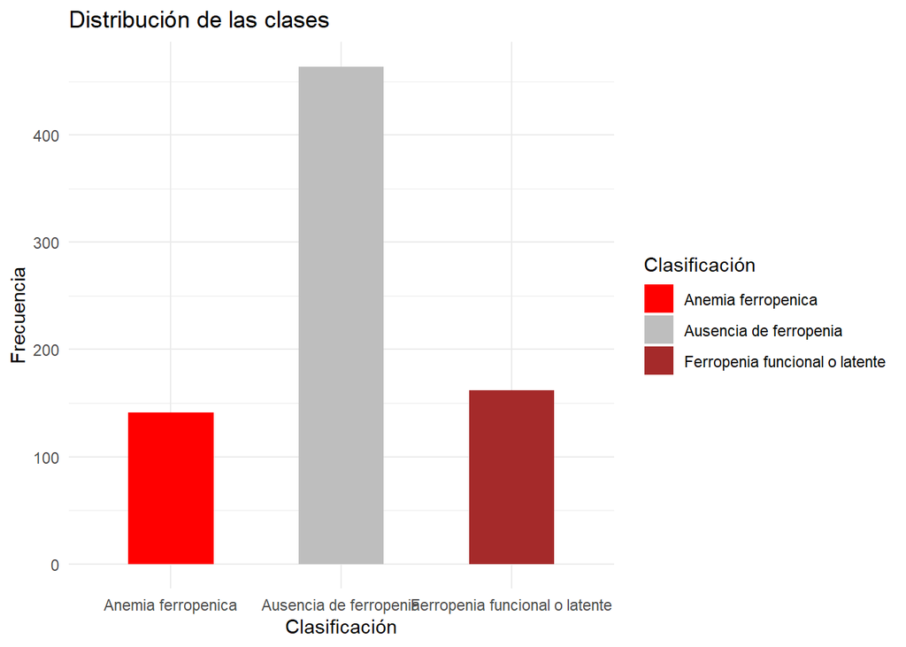

```r
# Crear un data frame a partir de la tabla de frecuencias
df = as.data.frame(table(dataset$Clasificación))
names(df) =c("Clasificación", "Frecuencia")
colores = c("red", "grey", "brown")

# Gráfico utilizando ggplot2
ggplot(df, aes(x = Clasificación, y = Frecuencia, fill = Clasificación)) +
  geom_bar(stat = "identity", width = 0.5) +
  scale_fill_manual(values = colores) +
  labs(x = "Clasificación", y = "Frecuencia", title = "Distribución de las clases") +
  theme_minimal()
```

Tenemos una distribución desbalanceada, se tendrá en cuenta para el tratamiento de los datos.

## 2.2 Exploración de los datos

### 2.2.1 Resumen de las variables:

```r
summary(dataset)
```

```
##  Sexo del Paciente       Edad              HTIE            HGB
##  Length:767         Min.   : 0.1667   Min.   :2.310   Min.   : 4.90
##  Class :character   1st Qu.: 3.0000   1st Qu.:4.750   1st Qu.:10.80
##  Mode  :character   Median : 4.0000   Median :5.060   Median :11.90
##                     Mean   : 6.7211   Mean   :5.076   Mean   :11.71
##                     3rd Qu.:12.0000   3rd Qu.:5.430   3rd Qu.:12.80
##                     Max.   :18.0000   Max.   :6.980   Max.   :16.70
##       VCM             HCM             ADE             CHCM
##  Min.   :50.30   Min.   :13.60   Min.   :12.00   Min.   :23.20
##  1st Qu.:68.50   1st Qu.:21.30   1st Qu.:14.40   1st Qu.:31.30
##  Median :73.40   Median :23.80   Median :15.90   Median :32.30
##  Mean   :72.04   Mean   :23.16   Mean   :16.77   Mean   :32.14
##  3rd Qu.:77.50   3rd Qu.:25.50   3rd Qu.:18.00   3rd Qu.:33.10
##  Max.   :82.50   Max.   :31.40   Max.   :39.80   Max.   :40.10
##       HTCO       Clasificación
##  Min.   :15.70   Length:767
##  1st Qu.:33.90   Class :character
##  Median :36.70   Mode  :character
##  Mean   :36.44
##  3rd Qu.:39.15
##  Max.   :53.40
```

Nuestro dataset no necesita llevar a cabo la eliminación de datos faltantes (NA) ya que se ha llevado a cabo en la realización del dataset.

Por último vemos con tipo de variables estamos trabajando:

```r
str(dataset)
```

```
## tibble [767 × 10] (S3: tbl_df/tbl/data.frame)
##  $ Sexo del Paciente: chr [1:767] "F" "M" "M" "M" ...
##  $ Edad             : num [1:767] 15 3 14 5 0.583 ...
##  $ HTIE             : num [1:767] 4.91 4.86 4.33 5.21 5.4 5.05 5.53 5.09 5.51 4.88 ...
##  $ HGB              : num [1:767] 11.2 12.7 13.6 13.1 11.9 11.6 15.4 13.4 15 13.3 ...
##  $ VCM              : num [1:767] 70.3 78.4 80.6 78.6 70.2 73.5 82.2 81.2 80.5 76.9 ...
##  $ HCM              : num [1:767] 22.8 26.2 31.4 25.2 22.1 23 27.9 26.3 27.3 27.2 ...
##  $ ADE              : num [1:767] 14.9 12.9 17.2 14.3 14.9 14.3 13.4 15.8 14.1 12.7 ...
##  $ CHCM             : num [1:767] 33.1 34.5 40.1 32.9 32.1 32.3 34.1 32.7 33.4 35 ...
##  $ HTCO             : num [1:767] 34.5 38.1 34.9 40.9 37.9 37.1 45.4 41.3 44.3 37.5 ...
##  $ Clasificación    : chr [1:767] "Ausencia de ferropenia" "Ausencia de ferropenia" "Ausencia de ferropenia" "Ausencia de ferropenia" ...
```

Podemos ver que todas las variables son numéricas excepto el “Sexo del Paciente” y la “clasificacion”, que convertiremos a factor:

```r
dataset$`Sexo del Paciente`= as.factor(dataset$`Sexo del Paciente`)
dataset$Clasificación <- factor(dataset$Clasificación,
                                levels = c("Anemia ferropenica", "Ferropenia funcional o latente", "Ausencia de ferropenia"),
                                labels = c("AF", "FF/FL", "NF"))

dataset$`Sexo del Paciente`= as.factor(dataset$`Sexo del Paciente`)

str(dataset)
```

```
## tibble [767 × 10] (S3: tbl_df/tbl/data.frame)
##  $ Sexo del Paciente: Factor w/ 2 levels "F","M": 1 2 2 2 2 1 2 1 2 1 ...
##  $ Edad             : num [1:767] 15 3 14 5 0.583 ...
##  $ HTIE             : num [1:767] 4.91 4.86 4.33 5.21 5.4 5.05 5.53 5.09 5.51 4.88 ...
##  $ HGB              : num [1:767] 11.2 12.7 13.6 13.1 11.9 11.6 15.4 13.4 15 13.3 ...
##  $ VCM              : num [1:767] 70.3 78.4 80.6 78.6 70.2 73.5 82.2 81.2 80.5 76.9 ...
##  $ HCM              : num [1:767] 22.8 26.2 31.4 25.2 22.1 23 27.9 26.3 27.3 27.2 ...
##  $ ADE              : num [1:767] 14.9 12.9 17.2 14.3 14.9 14.3 13.4 15.8 14.1 12.7 ...
##  $ CHCM             : num [1:767] 33.1 34.5 40.1 32.9 32.1 32.3 34.1 32.7 33.4 35 ...
##  $ HTCO             : num [1:767] 34.5 38.1 34.9 40.9 37.9 37.1 45.4 41.3 44.3 37.5 ...
##  $ Clasificación    : Factor w/ 3 levels "AF","FF/FL","NF": 3 3 3 3 2 3 3 2 2 3 ...
```

```r
#En paralelo para el dataset_retis
dataset_retis$`Sexo del Paciente`= as.factor(dataset_retis$`Sexo del Paciente`)
dataset_retis$Clasificación <- factor(dataset_retis$Clasificación,
                                levels = c("Anemia ferropenica", "Ferropenia funcional o latente", "Ausencia de ferropenia"),
                                labels = c("AF", "FF/FL", "NF"))
dataset_retis$`Sexo del Paciente` <- factor(dataset_retis$`Sexo del Paciente`,
                                levels = c("F", "M"),
                                labels = c(1,0))
```

Podemos ver lo primeros registros:

```r
head(dataset)
```

```
## # A tibble: 6 × 10
##   `Sexo del Paciente`   Edad  HTIE   HGB   VCM   HCM   ADE  CHCM  HTCO
##   <fct>                <dbl> <dbl> <dbl> <dbl> <dbl> <dbl> <dbl> <dbl>
## 1 F                   15      4.91  11.2  70.3  22.8  14.9  33.1  34.5
## 2 M                    3      4.86  12.7  78.4  26.2  12.9  34.5  38.1
## 3 M                   14      4.33  13.6  80.6  31.4  17.2  40.1  34.9
## 4 M                    5      5.21  13.1  78.6  25.2  14.3  32.9  40.9
## 5 M                    0.583  5.4   11.9  70.2  22.1  14.9  32.1  37.9
## 6 F                    0.917  5.05  11.6  73.5  23    14.3  32.3  37.1
## # ℹ 1 more variable: Clasificación <fct>
```

### 2.2.2 Gráficos exploratorios

#### Visualización de las variables cuantitativas en forma de boxplot

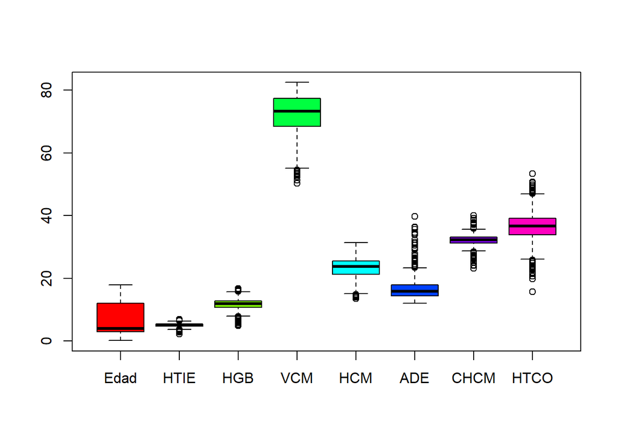

```r
#seleccionamos solo las variables cuantitativas
variables_cuantitativas <- dataset[, !(names(dataset) %in% c("Sexo del Paciente", "Clasificación"))]
colores= rainbow(ncol(variables_cuantitativas))
boxplot(variables_cuantitativas, col= colores)
```

Como se observa en el gráfico el rango de variabilidad entre variables es muy grande por eso en algunos casos con rango de valores muy estrechos queda reducida la caja a una linea. Esto nos indica que será necesaria la normalización de los datos para que las variables tengan el mismo peso.

#### Histogramas y boxplot en función de la clase y sexo:

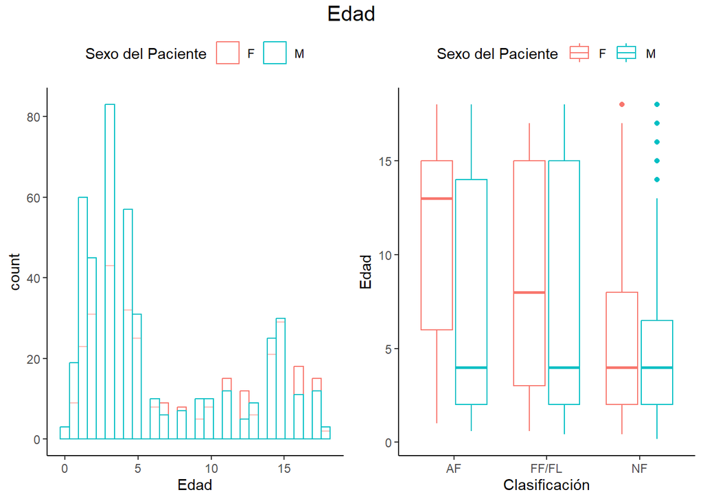

```r
# Gráfico 1: Histograma
p1= ggplot(dataset, aes(x = Edad, color = `Sexo del Paciente`)) +
    geom_histogram(fill = "white", alpha = 0.5, position = "identity") +
    theme_classic()


# Gráfico 2: Gráfico de cajas
p2= ggplot(data = dataset, aes(x = Clasificación, y = Edad, col = `Sexo del Paciente`)) +
    geom_boxplot()+
    theme_classic()

final_plot = ggarrange(p1, p2, legend = "top")
final_plot = annotate_figure(final_plot, top = text_grob("Edad", size =15))
final_plot
```

Se observa que hay más frecuencia de pacientes en edades comprendidas entre 0-5 años. Además, presentan el grupo de Anemia ferropénica se ve más prevalencia en el género femenino a edades más avanzadas, probablemente coincidiendo con la menstruación.

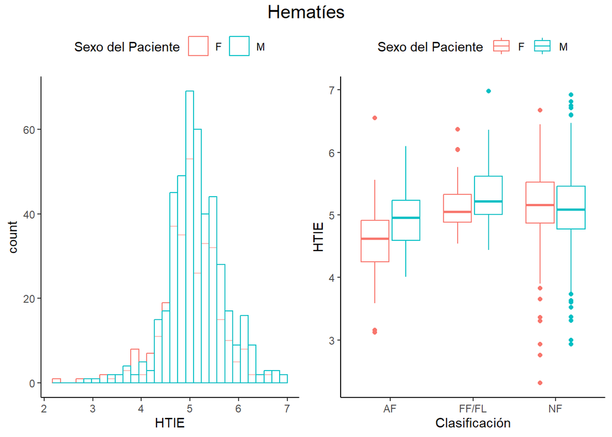

```r
# Gráfico 1: Histograma
p1= ggplot(dataset, aes(x = HTIE, color = `Sexo del Paciente`)) +
    geom_histogram(fill = "white", alpha = 0.5, position = "identity") +
    theme_classic()


# Gráfico 2: Gráfico de cajas
p2= ggplot(data = dataset, aes(x = Clasificación, y = HTIE, col = `Sexo del Paciente`)) +
    geom_boxplot()+
    theme_classic()

final_plot = ggarrange(p1, p2, legend = "top")
final_plot = annotate_figure(final_plot, top = text_grob("Hematíes", size =15))
final_plot
```

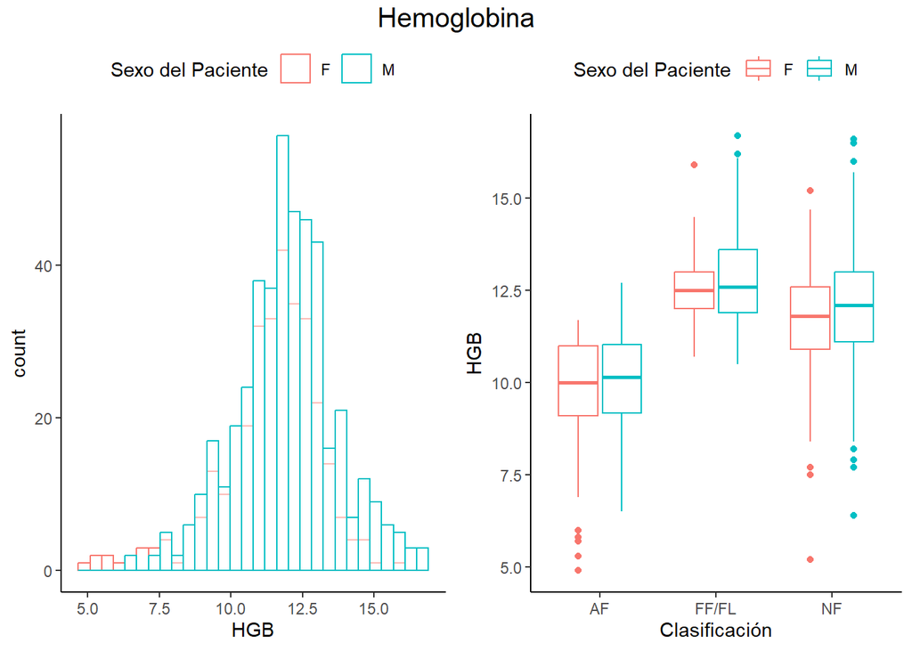

```r
# Gráfico 1: Histograma
p1= ggplot(dataset, aes(x = HGB, color = `Sexo del Paciente`)) +
    geom_histogram(fill = "white", alpha = 0.5, position = "identity") +
    theme_classic()

# Gráfico 2: Gráfico de cajas
p2= ggplot(data = dataset, aes(x = Clasificación, y = HGB, col = `Sexo del Paciente`)) +
    geom_boxplot()+
    theme_classic()

final_plot = ggarrange(p1, p2, legend = "top")
final_plot = annotate_figure(final_plot, top = text_grob("Hemoglobina", size =15))
final_plot
```

El parámetro Hemoglobina presenta una distribución normal, con medidas más bajas en la clase de Anemia ferropénica como cabe esperar.

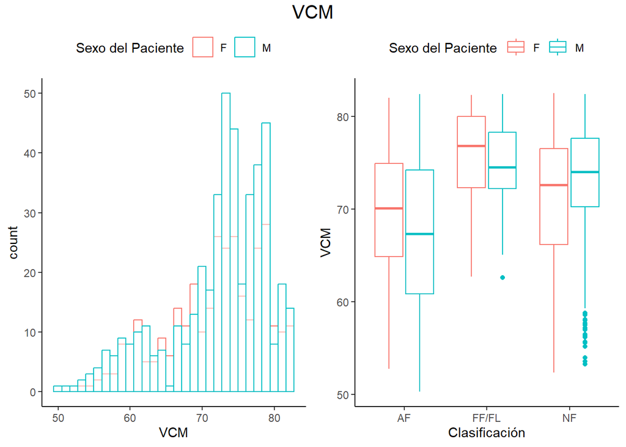

```r
# Gráfico 1: Histograma
p1=ggplot(dataset, aes(x = VCM, color = `Sexo del Paciente`)) +
    geom_histogram(fill = "white", alpha = 0.5, position = "identity") +
    theme_classic()


# Gráfico 2: Gráfico de cajas
p2=ggplot(data = dataset, aes(x = Clasificación, y = VCM, col = `Sexo del Paciente`)) +
    geom_boxplot()+
    theme_classic()

final_plot <- ggarrange(p1, p2, legend = "top")
final_plot <- annotate_figure(final_plot, top = text_grob("VCM", size =15))
final_plot
```

Distribución del Volumen Corpuscular Medio con cola hacia la izquierda. En cuanto a las clases se puede ver cómo en la anemia ferropénica el VCM marcadamente más bajo.

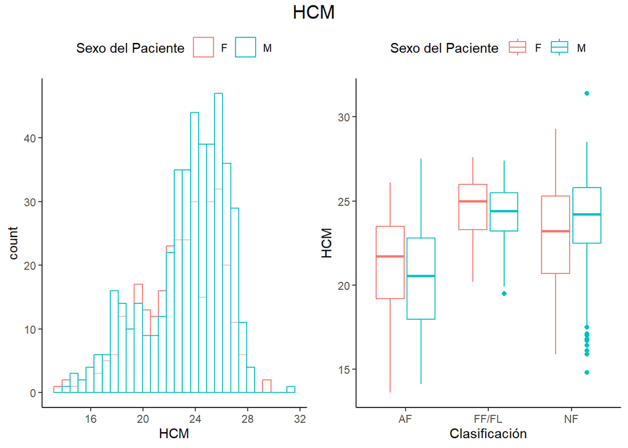

```r
# Gráfico 1: Histograma
p1=ggplot(dataset, aes(x = HCM, color = `Sexo del Paciente`)) +
    geom_histogram(fill = "white", alpha = 0.5, position = "identity") +
    theme_classic()

# Gráfico 2: Gráfico de cajas
p2=ggplot(data = dataset, aes(x = Clasificación, y = HCM, col = `Sexo del Paciente`)) +
    geom_boxplot()+
    theme_classic()

final_plot = ggarrange(p1, p2, legend = "top")
final_plot = annotate_figure(final_plot, top = text_grob("HCM", size =15))
final_plot
```

La Heglobina Corpuscular Media presenta una distribución casi normal, con valores más bajo en los pacientes con Anemia Ferropénica, ya que los hematíes son hipocrómicos.

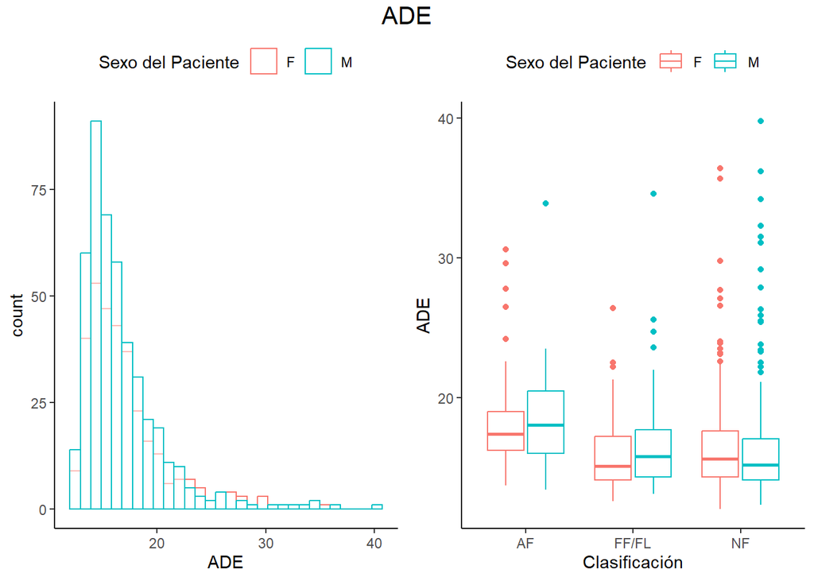

```r
# Gráfico 1: Histograma
p1=ggplot(dataset, aes(x = ADE, color = `Sexo del Paciente`)) +
    geom_histogram(fill = "white", alpha = 0.5, position = "identity") +
    theme_classic()

# Gráfico 2: Gráfico de cajas
p2=ggplot(data = dataset, aes(x = Clasificación, y = ADE, col = `Sexo del Paciente`)) +
    geom_boxplot()+
    theme_classic()

final_plot = ggarrange(p1, p2, legend = "top")
final_plot = annotate_figure(final_plot, top = text_grob("ADE", size =15))
final_plot
```

El Ancho de Distribución Eritrocitaria presenta una cola hacia la derecha, presentando valores más altos en Anemia Ferropénica que se corresponde a la anisocitosis que presentan los pacientes.

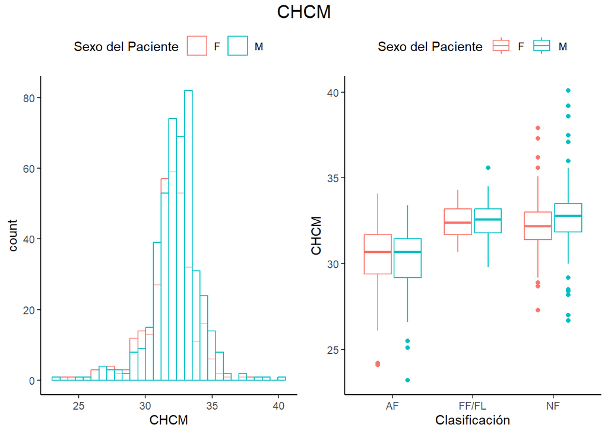

```r
# Gráfico 1: Histograma
p1=ggplot(dataset, aes(x = CHCM, color = `Sexo del Paciente`)) +
    geom_histogram(fill = "white", alpha = 0.5, position = "identity") +
    theme_classic()

# Gráfico 2: Gráfico de cajas
p2=ggplot(data = dataset, aes(x = Clasificación, y = CHCM, col = `Sexo del Paciente`)) +
    geom_boxplot()+
    theme_classic()

final_plot = ggarrange(p1, p2, legend = "top")
final_plot = annotate_figure(final_plot, top = text_grob("CHCM", size =15))
final_plot
```

La concentración de hemoglobina corpuscular media presenta una distribución normal, con valores más bajos en anemia ferropénica.

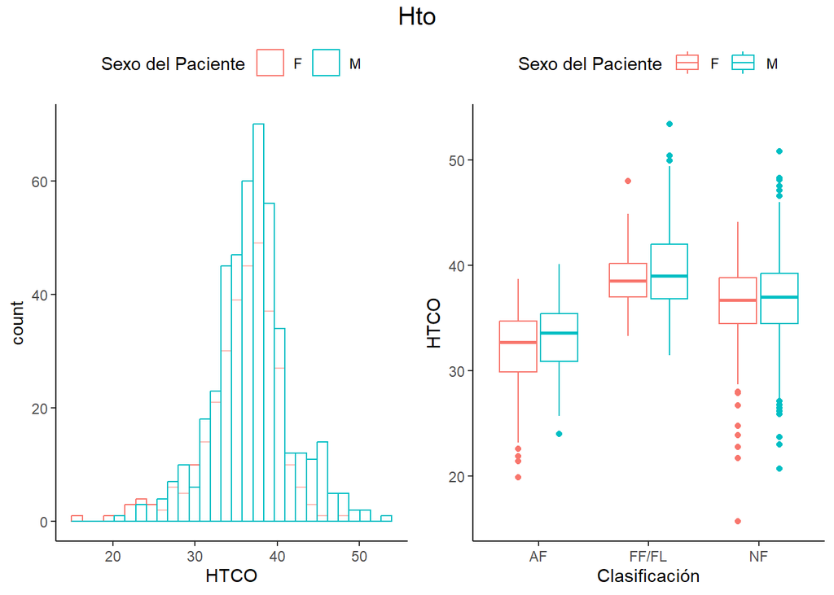

```r
# Gráfico 1: Histograma
p1=ggplot(dataset, aes(x = HTCO, color = `Sexo del Paciente`)) +
    geom_histogram(fill = "white", alpha = 0.5, position = "identity") +
    theme_classic()

# Gráfico 2: Gráfico de cajas
p2=ggplot(data = dataset, aes(x = Clasificación, y = HTCO, col = `Sexo del Paciente`)) +
    geom_boxplot()+
    theme_classic()

final_plot = ggarrange(p1, p2, legend = "top")
final_plot = annotate_figure(final_plot, top = text_grob("Hto", size =15))
final_plot
```

El hematocrito presenta una distribución normal y en la clase de anemia ferropénica presenta valores más bajos.

```r
#Asignamos el valor 1 al sexo femenino y 0 al género masculino
dataset$`Sexo del Paciente` <- factor(dataset$`Sexo del Paciente`,
                                levels = c("F", "M"),
                                labels = c(1,0))
```

# 3. Preprocesamiento de datos

## 3.1 División del dataset en train y test

Hacemos la partición del dataset: 70% de los pacientes para el entrenamiento y el 30% para el testeo.

```r
#Dejamos las variables categóricas como variables dummy
dummy <- model.matrix(~ `Sexo del Paciente` - 1, data = dataset)
dataset <- as.data.frame(cbind(dummy, dataset[2:ncol(dataset)]))
colnames(dataset)[colnames(dataset)== "`Sexo del Paciente`1"] = "Sexo_1"
colnames(dataset)[colnames(dataset)== "`Sexo del Paciente`0"] = "Sexo_0"
str(dataset)
```

```
## 'data.frame':    767 obs. of  11 variables:
##  $ Sexo_1       : num  1 0 0 0 0 1 0 1 0 1 ...
##  $ Sexo_0       : num  0 1 1 1 1 0 1 0 1 0 ...
##  $ Edad         : num  15 3 14 5 0.583 ...
##  $ HTIE         : num  4.91 4.86 4.33 5.21 5.4 5.05 5.53 5.09 5.51 4.88 ...
##  $ HGB          : num  11.2 12.7 13.6 13.1 11.9 11.6 15.4 13.4 15 13.3 ...
##  $ VCM          : num  70.3 78.4 80.6 78.6 70.2 73.5 82.2 81.2 80.5 76.9 ...
##  $ HCM          : num  22.8 26.2 31.4 25.2 22.1 23 27.9 26.3 27.3 27.2 ...
##  $ ADE          : num  14.9 12.9 17.2 14.3 14.9 14.3 13.4 15.8 14.1 12.7 ...
##  $ CHCM         : num  33.1 34.5 40.1 32.9 32.1 32.3 34.1 32.7 33.4 35 ...
##  $ HTCO         : num  34.5 38.1 34.9 40.9 37.9 37.1 45.4 41.3 44.3 37.5 ...
##  $ Clasificación: Factor w/ 3 levels "AF","FF/FL","NF": 3 3 3 3 2 3 3 2 2 3 ...
```

```r
# para dataset_retis

dummy <- model.matrix(~ `Sexo del Paciente` - 1, data = dataset_retis)
dataset_retis <- as.data.frame(cbind(dummy, dataset_retis[2:ncol(dataset_retis)]))
colnames(dataset_retis)[colnames(dataset_retis)== "`Sexo del Paciente`1"] = "Sexo_1"
colnames(dataset_retis)[colnames(dataset_retis)== "`Sexo del Paciente`0"] = "Sexo_0"
```

```r
n = nrow(dataset)
# Separamos los datos en Train y Test aleatoriamente
set.seed(29)
train = createDataPartition(dataset$Clasificación,p = 0.7, list = FALSE)
dataset.train = dataset[train,] #70%
dataset.test  = dataset[-train,] #30%

x.train= dataset.train[1:(ncol(dataset.train)-1)]
y.train= dataset.train[ncol(dataset.train)]
x.test= dataset.test[1:(ncol(dataset.train)-1)]
y.test= dataset.test[ncol(dataset.train)]
```

```r
# para dataset_retis
n = nrow(dataset_retis)
# Separamos los datos en Train y Test aleatoriamente
set.seed(29)
train = createDataPartition(dataset_retis$Clasificación,p = 0.7, list = FALSE)
dataset.train_retis = dataset_retis[train,] #70%
dataset.test_retis  = dataset_retis[-train,] #30%

x.train_retis= dataset.train_retis[1:(ncol(dataset.train_retis)-1)]
y.train_retis= dataset.train_retis[ncol(dataset.train_retis)]
x.test_retis= dataset.test_retis[1:(ncol(dataset.test_retis)-1)]
y.test_retis= dataset.test_retis[ncol(dataset.test_retis)]
```

Comprobamos que la los casos están distribuidos equitativamente entre el dataset train y test

```r
porcentajes_train=round(table(dataset.train$Clasificación)/nrow(dataset.train)*100,2)
porcentajes_test=round(table(dataset.test$Clasificación)/nrow(dataset.test)*100,2)
```

```r
kable(rbind(porcentajes_train,porcentajes_test))
```

|  | AF | FF/FL | NF |
| --- | --- | --- | --- |
| porcentajes_train | 18.40 | 21.19 | 60.41 |
| porcentajes_test | 18.34 | 20.96 | 60.70 |

Efectivamente, las clases se encuentran proporcionados en cada partición.

## 3.2 Prueba de los diferentes modelos - modelos basales

```r
# Normalización de las variables para los métodos que lo requieren:

preProcValues = preProcess(x.train, method = c("center", "scale"))

trainTransformed_basal = cbind(predict(preProcValues, x.train), y.train)
testTransformed_basal = cbind(predict(preProcValues, x.test), y.test)
```

Especificamos el método de validación que se van a utilizar en todos los modelos del paquete caret:

```r
set.seed(29)
fitControl <- trainControl(method = "cv",
                           number = 10,
                           summaryFunction = multiClassSummary
                           )
```

### 3.2.1 k-Nearest Neighbour

Para ello utilizamos los datos normalizados

```r
# modelo
set.seed(29)
modelo_knn_basal <- train(Clasificación ~ ., data = trainTransformed_basal,
                    method = "knn",
                    metric = "Kappa",
                    trControl= fitControl)

modelo_knn_basal
```

```
## k-Nearest Neighbors
##
## 538 samples
##  10 predictor
##   3 classes: 'AF', 'FF/FL', 'NF'
##
## No pre-processing
## Resampling: Cross-Validated (10 fold)
## Summary of sample sizes: 485, 484, 484, 485, 483, 484, ...
## Resampling results across tuning parameters:
##
##   k  Accuracy   Kappa      Mean_F1    Mean_Sensitivity  Mean_Specificity
##   5  0.6804523  0.3944835  0.6120101  0.6063131         0.7856782
##   7  0.7008278  0.4124316  0.6128283  0.6054104         0.7885080
##   9  0.7099511  0.4288952  0.6194965  0.6139268         0.7932330
##   Mean_Pos_Pred_Value  Mean_Neg_Pred_Value  Mean_Precision  Mean_Recall
##   0.6417451            0.8007070            0.6417451       0.6063131
##   0.6634022            0.8186931            0.6634022       0.6054104
##   0.6837387            0.8284737            0.6837387       0.6139268
##   Mean_Detection_Rate  Mean_Balanced_Accuracy
##   0.2268174            0.6959957
##   0.2336093            0.6969592
##   0.2366504            0.7035799
##
## Kappa was used to select the optimal model using the largest value.
## The final value used for the model was k = 9.
```

```r
# Predicciones
p <- predict(modelo_knn_basal, newdata = testTransformed_basal[,-(ncol(testTransformed_basal))])

# Evaluación
(mconfusion_knn_basal <- confusionMatrix(p, testTransformed_basal$Clasificación, mode="everything", positive="AF"))
```

```
## Confusion Matrix and Statistics
##
##           Reference
## Prediction  AF FF/FL  NF
##      AF     24     1   6
##      FF/FL   2    16   3
##      NF     16    31 130
##
## Overall Statistics
##
##                Accuracy : 0.7424
##                  95% CI : (0.6806, 0.7977)
##     No Information Rate : 0.607
##     P-Value [Acc > NIR] : 1.135e-05
##
##                   Kappa : 0.4707
##
##  Mcnemar's Test P-Value : 3.743e-06
##
## Statistics by Class:
##
##                      Class: AF Class: FF/FL Class: NF
## Sensitivity             0.5714      0.33333    0.9353
## Specificity             0.9626      0.97238    0.4778
## Pos Pred Value          0.7742      0.76190    0.7345
## Neg Pred Value          0.9091      0.84615    0.8269
## Precision               0.7742      0.76190    0.7345
## Recall                  0.5714      0.33333    0.9353
## F1                      0.6575      0.46377    0.8228
## Prevalence              0.1834      0.20961    0.6070
## Detection Rate          0.1048      0.06987    0.5677
## Detection Prevalence    0.1354      0.09170    0.7729
## Balanced Accuracy       0.7670      0.65285    0.7065
```

```r
resultados_knn_basal <- data.frame(
  Modelo              = "KNN_basal",
  Precisión           = round((ifelse(is.na(mconfusion_knn_basal$byClass[1,5]), 0, mconfusion_knn_basal$byClass[1,5]) +
                              ifelse(is.na(mconfusion_knn_basal$byClass[2,5]), 0, mconfusion_knn_basal$byClass[2,5]) +
                              ifelse(is.na(mconfusion_knn_basal$byClass[3,5]), 0, mconfusion_knn_basal$byClass[3,5]) ) / 3, 3),
  Sensibilidad        = round((ifelse(is.na(mconfusion_knn_basal$byClass[1,1]), 0, mconfusion_knn_basal$byClass[1,1]) +
                              ifelse(is.na(mconfusion_knn_basal$byClass[2,1]), 0, mconfusion_knn_basal$byClass[2,1]) +
                              ifelse(is.na(mconfusion_knn_basal$byClass[3,1]), 0, mconfusion_knn_basal$byClass[3,1]) ) / 3, 3),
  Especificidad       = round((ifelse(is.na(mconfusion_knn_basal$byClass[1,2]), 0, mconfusion_knn_basal$byClass[1,2]) +
                              ifelse(is.na(mconfusion_knn_basal$byClass[2,2]), 0, mconfusion_knn_basal$byClass[2,2]) +
                              ifelse(is.na(mconfusion_knn_basal$byClass[3,2]), 0, mconfusion_knn_basal$byClass[3,2]) ) / 3, 3),
  kappa               = round(mconfusion_knn_basal[["overall"]][["Kappa"]], 3),
  F1                  = round((ifelse(is.na(mconfusion_knn_basal$byClass[1,7]), 0, mconfusion_knn_basal$byClass[1,7]) +
                              ifelse(is.na(mconfusion_knn_basal$byClass[2,7]), 0, mconfusion_knn_basal$byClass[2,7]) +
                              ifelse(is.na(mconfusion_knn_basal$byClass[3,7]), 0, mconfusion_knn_basal$byClass[3,7]) ) / 3, 3),
  Error_clasificación = round((1 - mconfusion_knn_basal[["overall"]][["Accuracy"]]) * 100, 3),
  Accuracy            = round(mconfusion_knn_basal[["overall"]][["Accuracy"]], 3)
)

# Mostrar resultados
resultados_knn_basal
```

```
##      Modelo Precisión Sensibilidad Especificidad kappa    F1
## 1 KNN_basal     0.757        0.613         0.804 0.471 0.648
##   Error_clasificación Accuracy
## 1              25.764    0.742
```

### 3.2.2 Naive Bayes

```r
# Ajuste del modelo
set.seed(29)
(modelo_bayes_basal = train(Clasificación ~ ., data = dataset.train,
                   method = "nb",
                   metric = "Kappa",
                    trControl= fitControl))
```

```
## Naive Bayes
##
## 538 samples
##  10 predictor
##   3 classes: 'AF', 'FF/FL', 'NF'
##
## No pre-processing
## Resampling: Cross-Validated (10 fold)
## Summary of sample sizes: 485, 484, 484, 485, 483, 484, ...
## Resampling results across tuning parameters:
##
##   usekernel  Accuracy   Kappa      Mean_F1    Mean_Sensitivity
##   FALSE      0.5410914  0.2854721  0.5452468  0.5904524
##    TRUE      0.6209421  0.3022949  0.5496944  0.5552694
##   Mean_Specificity  Mean_Pos_Pred_Value  Mean_Neg_Pred_Value  Mean_Precision
##   0.7625074         0.5706414            0.7576244            0.5706414
##   0.7580455         0.5695916            0.7652009            0.5695916
##   Mean_Recall  Mean_Detection_Rate  Mean_Balanced_Accuracy
##   0.5904524    0.1803638            0.6764799
##   0.5552694    0.2069807            0.6566574
##
## Tuning parameter 'fL' was held constant at a value of 0
## Tuning
##  parameter 'adjust' was held constant at a value of 1
## Kappa was used to select the optimal model using the largest value.
## The final values used for the model were fL = 0, usekernel = TRUE and adjust
##  = 1.
```

```r
# Predicciones
p <- predict(modelo_bayes_basal, dataset.test[1:(ncol(dataset.test)-1)])

# Evaluación
(mconfusion_Bayes_basal <- confusionMatrix(p, dataset.test$Clasificación, mode="everything", positive="AF"))
```

```
## Confusion Matrix and Statistics
##
##           Reference
## Prediction  AF FF/FL  NF
##      AF     27     2  17
##      FF/FL   2    19  13
##      NF     13    27 109
##
## Overall Statistics
##
##                Accuracy : 0.6769
##                  95% CI : (0.6121, 0.737)
##     No Information Rate : 0.607
##     P-Value [Acc > NIR] : 0.01714
##
##                   Kappa : 0.3984
##
##  Mcnemar's Test P-Value : 0.14268
##
## Statistics by Class:
##
##                      Class: AF Class: FF/FL Class: NF
## Sensitivity             0.6429      0.39583    0.7842
## Specificity             0.8984      0.91713    0.5556
## Pos Pred Value          0.5870      0.55882    0.7315
## Neg Pred Value          0.9180      0.85128    0.6250
## Precision               0.5870      0.55882    0.7315
## Recall                  0.6429      0.39583    0.7842
## F1                      0.6136      0.46341    0.7569
## Prevalence              0.1834      0.20961    0.6070
## Detection Rate          0.1179      0.08297    0.4760
## Detection Prevalence    0.2009      0.14847    0.6507
## Balanced Accuracy       0.7706      0.65648    0.6699
```

```r
resultados_NaiveBayes_basal <- data.frame(
  Modelo              = "Bayes_basal",
  Precisión           = round((ifelse(is.na(mconfusion_Bayes_basal$byClass[1,5]), 0, mconfusion_Bayes_basal$byClass[1,5]) +
                               ifelse(is.na(mconfusion_Bayes_basal$byClass[2,5]), 0, mconfusion_Bayes_basal$byClass[2,5]) +
                               ifelse(is.na(mconfusion_Bayes_basal$byClass[3,5]), 0, mconfusion_Bayes_basal$byClass[3,5]) ) / 3, 3),
  Sensibilidad        = round((ifelse(is.na(mconfusion_Bayes_basal$byClass[1,1]), 0, mconfusion_Bayes_basal$byClass[1,1]) +
                               ifelse(is.na(mconfusion_Bayes_basal$byClass[2,1]), 0, mconfusion_Bayes_basal$byClass[2,1]) +
                               ifelse(is.na(mconfusion_Bayes_basal$byClass[3,1]), 0, mconfusion_Bayes_basal$byClass[3,1]) ) / 3, 3),
  Especificidad       = round((ifelse(is.na(mconfusion_Bayes_basal$byClass[1,2]), 0, mconfusion_Bayes_basal$byClass[1,2]) +
                               ifelse(is.na(mconfusion_Bayes_basal$byClass[2,2]), 0, mconfusion_Bayes_basal$byClass[2,2]) +
                               ifelse(is.na(mconfusion_Bayes_basal$byClass[3,2]), 0, mconfusion_Bayes_basal$byClass[3,2])  ) / 3, 3),
  kappa               = round(mconfusion_Bayes_basal[["overall"]][["Kappa"]], 3),
  F1                  = round((ifelse(is.na(mconfusion_Bayes_basal$byClass[1,7]), 0, mconfusion_Bayes_basal$byClass[1,7]) +
                               ifelse(is.na(mconfusion_Bayes_basal$byClass[2,7]), 0, mconfusion_Bayes_basal$byClass[2,7]) +
                               ifelse(is.na(mconfusion_Bayes_basal$byClass[3,7]), 0, mconfusion_Bayes_basal$byClass[3,7])  ) / 3, 3),
  Error_clasificación = round((1 - mconfusion_Bayes_basal[["overall"]][["Accuracy"]]) * 100, 3),
  Accuracy            = round(mconfusion_Bayes_basal[["overall"]][["Accuracy"]], 3)
)

resultados_NaiveBayes_basal
```

```
##        Modelo Precisión Sensibilidad Especificidad kappa    F1
## 1 Bayes_basal     0.626        0.608          0.79 0.398 0.611
##   Error_clasificación Accuracy
## 1              32.314    0.677
```

### 3.2.4 ANN

```r
# Ajuste del modelo
set.seed(29)

(modelo_ann_basal <- train(Clasificación ~ ., data = trainTransformed_basal,
                    method = "nnet",
                    metric = "Kappa",
                    trControl= fitControl,
                    trace = FALSE))
```

```
## Neural Network
##
## 538 samples
##  10 predictor
##   3 classes: 'AF', 'FF/FL', 'NF'
##
## No pre-processing
## Resampling: Cross-Validated (10 fold)
## Summary of sample sizes: 485, 484, 484, 485, 483, 484, ...
## Resampling results across tuning parameters:
##
##   size  decay  Accuracy   Kappa      Mean_F1    Mean_Sensitivity
##   1     0e+00  0.6711956  0.2935854        NaN  0.5230703
##   1     1e-04  0.6639229  0.2722807        NaN  0.5120286
##   1     1e-01  0.6768198  0.3157265        NaN  0.5347790
##   3     0e+00  0.7138257  0.4495929  0.6240823  0.6289604
##   3     1e-04  0.6752709  0.3740506  0.5910251  0.5883228
##   3     1e-01  0.7253859  0.4792711  0.6576462  0.6505640
##   5     0e+00  0.6768833  0.3993858  0.6113843  0.6110774
##   5     1e-04  0.6806956  0.3975202  0.6005313  0.6033270
##   5     1e-01  0.7119389  0.4579217  0.6482199  0.6439604
##   Mean_Specificity  Mean_Pos_Pred_Value  Mean_Neg_Pred_Value  Mean_Precision
##   0.7464447               NaN            0.8127452                  NaN
##   0.7420083               NaN            0.8108708                  NaN
##   0.7521983               NaN            0.8110580                  NaN
##   0.8037015         0.6896317            0.8339850            0.6896317
##   0.7761025         0.6645230            0.8028891            0.6645230
##   0.8138949         0.7240778            0.8381217            0.7240778
##   0.7882005         0.6505853            0.8033955            0.6505853
##   0.7888183         0.6320038            0.8059593            0.6320038
##   0.8082813         0.6878860            0.8293690            0.6878860
##   Mean_Recall  Mean_Detection_Rate  Mean_Balanced_Accuracy
##   0.5230703    0.2237319            0.6347575
##   0.5120286    0.2213076            0.6270185
##   0.5347790    0.2256066            0.6434887
##   0.6289604    0.2379419            0.7163310
##   0.5883228    0.2250903            0.6822127
##   0.6505640    0.2417953            0.7322294
##   0.6110774    0.2256278            0.6996390
##   0.6033270    0.2268985            0.6960727
##   0.6439604    0.2373130            0.7261209
##
## Kappa was used to select the optimal model using the largest value.
## The final values used for the model were size = 3 and decay = 0.1.
```

```r
# Predicciones
p <- predict(modelo_ann_basal, newdata = testTransformed_basal[1:(ncol(testTransformed_basal)-1)])

# Evaluación
res = table(p, testTransformed_basal$Clasificación)
(mconfusion_ann_basal = confusionMatrix(res, mode="everything", positive="AF"))
```

```
## Confusion Matrix and Statistics
##
##
## p        AF FF/FL  NF
##   AF     29     0   7
##   FF/FL   0    18   8
##   NF     13    30 124
##
## Overall Statistics
##
##                Accuracy : 0.7467
##                  95% CI : (0.6852, 0.8017)
##     No Information Rate : 0.607
##     P-Value [Acc > NIR] : 5.907e-06
##
##                   Kappa : 0.4982
##
##  Mcnemar's Test P-Value : NA
##
## Statistics by Class:
##
##                      Class: AF Class: FF/FL Class: NF
## Sensitivity             0.6905       0.3750    0.8921
## Specificity             0.9626       0.9558    0.5222
## Pos Pred Value          0.8056       0.6923    0.7425
## Neg Pred Value          0.9326       0.8522    0.7581
## Precision               0.8056       0.6923    0.7425
## Recall                  0.6905       0.3750    0.8921
## F1                      0.7436       0.4865    0.8105
## Prevalence              0.1834       0.2096    0.6070
## Detection Rate          0.1266       0.0786    0.5415
## Detection Prevalence    0.1572       0.1135    0.7293
## Balanced Accuracy       0.8265       0.6654    0.7072
```

```r
resultados_ann_basal <- data.frame(
  Modelo              = "ANN_basal",
  Precisión           = round((ifelse(is.na(mconfusion_ann_basal$byClass[1,5]), 0, mconfusion_ann_basal$byClass[1,5]) +
                               ifelse(is.na(mconfusion_ann_basal$byClass[2,5]), 0, mconfusion_ann_basal$byClass[2,5]) +
                               ifelse(is.na(mconfusion_ann_basal$byClass[3,5]), 0, mconfusion_ann_basal$byClass[3,5])  ) / 3, 3),
  Sensibilidad        = round((ifelse(is.na(mconfusion_ann_basal$byClass[1,1]), 0, mconfusion_ann_basal$byClass[1,1]) +
                               ifelse(is.na(mconfusion_ann_basal$byClass[2,1]), 0, mconfusion_ann_basal$byClass[2,1]) +
                               ifelse(is.na(mconfusion_ann_basal$byClass[3,1]), 0, mconfusion_ann_basal$byClass[3,1])  ) /3, 3),
  Especificidad       = round((ifelse(is.na(mconfusion_ann_basal$byClass[1,2]), 0, mconfusion_ann_basal$byClass[1,2]) +
                               ifelse(is.na(mconfusion_ann_basal$byClass[2,2]), 0, mconfusion_ann_basal$byClass[2,2]) +
                               ifelse(is.na(mconfusion_ann_basal$byClass[3,2]), 0, mconfusion_ann_basal$byClass[3,2])  ) / 3 , 3),
  kappa               = round(mconfusion_ann_basal[["overall"]][["Kappa"]], 3),
  F1                  = round((ifelse(is.na(mconfusion_ann_basal$byClass[1,7]), 0, mconfusion_ann_basal$byClass[1,7]) +
                               ifelse(is.na(mconfusion_ann_basal$byClass[2,7]), 0, mconfusion_ann_basal$byClass[2,7]) +
                               ifelse(is.na(mconfusion_ann_basal$byClass[3,7]), 0, mconfusion_ann_basal$byClass[3,7]) ) / 3, 3),
  Error_clasificación = round((1 - mconfusion_ann_basal[["overall"]][["Accuracy"]]) * 100, 3),
  Accuracy            = round(mconfusion_ann_basal[["overall"]][["Accuracy"]], 3)
)

resultados_ann_basal
```

```
##      Modelo Precisión Sensibilidad Especificidad kappa   F1 Error_clasificación
## 1 ANN_basal     0.747        0.653         0.814 0.498 0.68              25.328
##   Accuracy
## 1    0.747
```

### 3.2.5 Support Vector Machine

#### 3.2.5.1 SVM-lineal

```r
# Ajuste del modelo
set.seed(29)
(modelo_svmlineal_basal = train(Clasificación ~ ., data = trainTransformed_basal,
                          method = "svmLinear",
                          metric = "Kappa",
                    trControl= fitControl
                          ))
```

```
## Support Vector Machines with Linear Kernel
##
## 538 samples
##  10 predictor
##   3 classes: 'AF', 'FF/FL', 'NF'
##
## No pre-processing
## Resampling: Cross-Validated (10 fold)
## Summary of sample sizes: 485, 484, 484, 485, 483, 484, ...
## Resampling results:
##
##   Accuracy   Kappa     Mean_F1  Mean_Sensitivity  Mean_Specificity
##   0.6823753  0.332276  NaN      0.5405661         0.7584577
##   Mean_Pos_Pred_Value  Mean_Neg_Pred_Value  Mean_Precision  Mean_Recall
##   NaN                  0.8271267            NaN             0.5405661
##   Mean_Detection_Rate  Mean_Balanced_Accuracy
##   0.2274584            0.6495119
##
## Tuning parameter 'C' was held constant at a value of 1
```

```r
# Predicciones
p = predict(modelo_svmlineal_basal, newdata = testTransformed_basal[1:(ncol(testTransformed_basal)-1)])

# Evaluación
(mconfusion_svmlineal_basal = confusionMatrix(p, testTransformed_basal$Clasificación, mode="everything", positive="AF"))
```

```
## Confusion Matrix and Statistics
##
##           Reference
## Prediction  AF FF/FL  NF
##      AF     23     2   7
##      FF/FL   0     0   0
##      NF     19    46 132
##
## Overall Statistics
##
##                Accuracy : 0.6769
##                  95% CI : (0.6121, 0.737)
##     No Information Rate : 0.607
##     P-Value [Acc > NIR] : 0.01714
##
##                   Kappa : 0.2854
##
##  Mcnemar's Test P-Value : 1.407e-11
##
## Statistics by Class:
##
##                      Class: AF Class: FF/FL Class: NF
## Sensitivity             0.5476       0.0000    0.9496
## Specificity             0.9519       1.0000    0.2778
## Pos Pred Value          0.7188          NaN    0.6701
## Neg Pred Value          0.9036       0.7904    0.7812
## Precision               0.7188           NA    0.6701
## Recall                  0.5476       0.0000    0.9496
## F1                      0.6216           NA    0.7857
## Prevalence              0.1834       0.2096    0.6070
## Detection Rate          0.1004       0.0000    0.5764
## Detection Prevalence    0.1397       0.0000    0.8603
## Balanced Accuracy       0.7497       0.5000    0.6137
```

```r
resultados_svmlineal_basal <- data.frame(
  Modelo              = "SVM lineal_basal",
  Precisión           = round((ifelse(is.na(mconfusion_svmlineal_basal$byClass[1,5]), 0, mconfusion_svmlineal_basal$byClass[1,5]) +
                              ifelse(is.na(mconfusion_svmlineal_basal$byClass[2,5]), 0, mconfusion_svmlineal_basal$byClass[2,5]) +
                              ifelse(is.na(mconfusion_svmlineal_basal$byClass[3,5]), 0, mconfusion_svmlineal_basal$byClass[3,5])  ) / 3, 3),
  Sensibilidad        = round((ifelse(is.na(mconfusion_svmlineal_basal$byClass[1,1]), 0, mconfusion_svmlineal_basal$byClass[1,1]) +
                              ifelse(is.na(mconfusion_svmlineal_basal$byClass[2,1]), 0, mconfusion_svmlineal_basal$byClass[2,1]) +
                              ifelse(is.na(mconfusion_svmlineal_basal$byClass[3,1]), 0, mconfusion_svmlineal_basal$byClass[3,1])  ) / 3, 3),
  Especificidad       = round((ifelse(is.na(mconfusion_svmlineal_basal$byClass[1,2]), 0, mconfusion_svmlineal_basal$byClass[1,2]) +
                              ifelse(is.na(mconfusion_svmlineal_basal$byClass[2,2]), 0, mconfusion_svmlineal_basal$byClass[2,2]) +
                              ifelse(is.na(mconfusion_svmlineal_basal$byClass[3,2]), 0, mconfusion_svmlineal_basal$byClass[3,2])  ) / 3, 3),
  kappa               = round(mconfusion_svmlineal_basal[["overall"]][["Kappa"]], 3),
  F1                  = round((ifelse(is.na(mconfusion_svmlineal_basal$byClass[1,7]), 0, mconfusion_svmlineal_basal$byClass[1,7]) +
                              ifelse(is.na(mconfusion_svmlineal_basal$byClass[2,7]), 0, mconfusion_svmlineal_basal$byClass[2,7]) +
                              ifelse(is.na(mconfusion_svmlineal_basal$byClass[3,7]), 0, mconfusion_svmlineal_basal$byClass[3,7])  ) / 3, 3),
  Error_clasificación = round((1 - mconfusion_svmlineal_basal[["overall"]][["Accuracy"]]) * 100, 3),
  Accuracy            = round(mconfusion_svmlineal_basal[["overall"]][["Accuracy"]], 3)
)

# Mostrar resultados
resultados_svmlineal_basal
```

```
##             Modelo Precisión Sensibilidad Especificidad kappa    F1
## 1 SVM lineal_basal     0.463        0.499         0.743 0.285 0.469
##   Error_clasificación Accuracy
## 1              32.314    0.677
```

#### 3.2.5.2 SVM-RBF o función gaussiana

```r
# Ajuste del modelo
set.seed(29)
(modelo_svmradial_basal = train(Clasificación ~ ., data = trainTransformed_basal,
                          method = "svmRadial",
                         metric = "Kappa",
                    trControl= fitControl))
```

```
## Support Vector Machines with Radial Basis Function Kernel
##
## 538 samples
##  10 predictor
##   3 classes: 'AF', 'FF/FL', 'NF'
##
## No pre-processing
## Resampling: Cross-Validated (10 fold)
## Summary of sample sizes: 485, 484, 484, 485, 483, 484, ...
## Resampling results across tuning parameters:
##
##   C     Accuracy   Kappa      Mean_F1    Mean_Sensitivity  Mean_Specificity
##   0.25  0.7252513  0.4007509  0.5887461  0.5664436         0.7765664
##   0.50  0.7290236  0.4243265  0.5983338  0.5881481         0.7854040
##   1.00  0.7269297  0.4370033  0.6100911  0.6051999         0.7908698
##   Mean_Pos_Pred_Value  Mean_Neg_Pred_Value  Mean_Precision  Mean_Recall
##   0.8399882            0.8803637            0.8399882       0.5664436
##   0.8192853            0.8645339            0.8192853       0.5881481
##   0.7860444            0.8541034            0.7860444       0.6051999
##   Mean_Detection_Rate  Mean_Balanced_Accuracy
##   0.2417504            0.6715050
##   0.2430079            0.6867761
##   0.2423099            0.6980348
##
## Tuning parameter 'sigma' was held constant at a value of 0.1393163
## Kappa was used to select the optimal model using the largest value.
## The final values used for the model were sigma = 0.1393163 and C = 1.
```

```r
# Predicciones
p = predict(modelo_svmradial_basal, newdata = testTransformed_basal[1:(ncol(testTransformed_basal)-1)])

# Evaluación
(mconfusion_svmradial_basal = confusionMatrix(p, testTransformed_basal$Clasificación, mode="everything", positive="AF"))
```

```
## Confusion Matrix and Statistics
##
##           Reference
## Prediction  AF FF/FL  NF
##      AF     23     1   4
##      FF/FL   0    10   2
##      NF     19    37 133
##
## Overall Statistics
##
##                Accuracy : 0.7249
##                  95% CI : (0.6622, 0.7817)
##     No Information Rate : 0.607
##     P-Value [Acc > NIR] : 0.0001246
##
##                   Kappa : 0.4092
##
##  Mcnemar's Test P-Value : 3.651e-09
##
## Statistics by Class:
##
##                      Class: AF Class: FF/FL Class: NF
## Sensitivity             0.5476      0.20833    0.9568
## Specificity             0.9733      0.98895    0.3778
## Pos Pred Value          0.8214      0.83333    0.7037
## Neg Pred Value          0.9055      0.82488    0.8500
## Precision               0.8214      0.83333    0.7037
## Recall                  0.5476      0.20833    0.9568
## F1                      0.6571      0.33333    0.8110
## Prevalence              0.1834      0.20961    0.6070
## Detection Rate          0.1004      0.04367    0.5808
## Detection Prevalence    0.1223      0.05240    0.8253
## Balanced Accuracy       0.7604      0.59864    0.6673
```

```r
resultados_SVM_radial_basal <- data.frame(
  Modelo              = "SVM-Radial_basal",
  Precisión           = round((ifelse(is.na(mconfusion_svmradial_basal$byClass[1,5]), 0, mconfusion_svmradial_basal$byClass[1,5]) +
                               ifelse(is.na(mconfusion_svmradial_basal$byClass[2,5]), 0, mconfusion_svmradial_basal$byClass[2,5]) +
                               ifelse(is.na(mconfusion_svmradial_basal$byClass[3,5]), 0, mconfusion_svmradial_basal$byClass[3,5])  ) / 3, 3),
  Sensibilidad        = round((ifelse(is.na(mconfusion_svmradial_basal$byClass[1,1]), 0, mconfusion_svmradial_basal$byClass[1,1]) +
                               ifelse(is.na(mconfusion_svmradial_basal$byClass[2,1]), 0, mconfusion_svmradial_basal$byClass[2,1]) +
                               ifelse(is.na(mconfusion_svmradial_basal$byClass[3,1]), 0, mconfusion_svmradial_basal$byClass[3,1])  ) / 3, 3),
  Especificidad       = round((ifelse(is.na(mconfusion_svmradial_basal$byClass[1,2]), 0, mconfusion_svmradial_basal$byClass[1,2]) +
                               ifelse(is.na(mconfusion_svmradial_basal$byClass[2,2]), 0, mconfusion_svmradial_basal$byClass[2,2]) +
                               ifelse(is.na(mconfusion_svmradial_basal$byClass[3,2]), 0, mconfusion_svmradial_basal$byClass[3,2])  ) / 3, 3),
  kappa               = round(mconfusion_svmradial_basal[["overall"]][["Kappa"]], 3),
  F1                  = round((ifelse(is.na(mconfusion_svmradial_basal$byClass[1,7]), 0, mconfusion_svmradial_basal$byClass[1,7]) +
                               ifelse(is.na(mconfusion_svmradial_basal$byClass[2,7]), 0, mconfusion_svmradial_basal$byClass[2,7]) +
                               ifelse(is.na(mconfusion_svmradial_basal$byClass[3,7]), 0, mconfusion_svmradial_basal$byClass[3,7])  ) / 3, 3),
  Error_clasificación = round((1 - mconfusion_svmradial_basal[["overall"]][["Accuracy"]]) * 100, 3),
  Accuracy            = round(mconfusion_svmradial_basal[["overall"]][["Accuracy"]], 3)
)

# Mostrar resultados
resultados_SVM_radial_basal
```

```
##             Modelo Precisión Sensibilidad Especificidad kappa  F1
## 1 SVM-Radial_basal     0.786        0.571          0.78 0.409 0.6
##   Error_clasificación Accuracy
## 1              27.511    0.725
```

#### 3.2.5.3 SVM-polynomial

```r
# Ajuste del modelo
set.seed(29)
(modelo_svmpoly_basal = train(Clasificación ~ ., data = trainTransformed_basal,
                          method = "svmPoly",
                          metric = "Kappa",
                    trControl= fitControl))
```

```
## Support Vector Machines with Polynomial Kernel
##
## 538 samples
##  10 predictor
##   3 classes: 'AF', 'FF/FL', 'NF'
##
## No pre-processing
## Resampling: Cross-Validated (10 fold)
## Summary of sample sizes: 485, 484, 484, 485, 483, 484, ...
## Resampling results across tuning parameters:
##
##   degree  scale  C     Accuracy   Kappa       Mean_F1    Mean_Sensitivity
##   1       0.001  0.25  0.6041020  0.00000000        NaN  0.3333333
##   1       0.001  0.50  0.6041020  0.00000000        NaN  0.3333333
##   1       0.001  1.00  0.6041020  0.00000000        NaN  0.3333333
##   1       0.010  0.25  0.6209097  0.05897871        NaN  0.3640741
##   1       0.010  0.50  0.6450575  0.14942971        NaN  0.4146843
##   1       0.010  1.00  0.6581227  0.20262739        NaN  0.4476178
##   1       0.100  0.25  0.6712293  0.26973414        NaN  0.4921359
##   1       0.100  0.50  0.6786367  0.29315572        NaN  0.5054377
##   1       0.100  1.00  0.6730112  0.29376462        NaN  0.5115741
##   2       0.001  0.25  0.6041020  0.00000000        NaN  0.3333333
##   2       0.001  0.50  0.6041020  0.00000000        NaN  0.3333333
##   2       0.001  1.00  0.6078756  0.01329807        NaN  0.3403704
##   2       0.010  0.25  0.6469443  0.15197782        NaN  0.4156944
##   2       0.010  0.50  0.6580541  0.20849837        NaN  0.4522327
##   2       0.010  1.00  0.6787066  0.28320168        NaN  0.4989015
##   2       0.100  0.25  0.7215113  0.41361330  0.5974320  0.5862226
##   2       0.100  0.50  0.7270332  0.43192886  0.6114483  0.6000105
##   2       0.100  1.00  0.7361591  0.46211590  0.6359401  0.6236848
##   3       0.001  0.25  0.6041020  0.00000000        NaN  0.3333333
##   3       0.001  0.50  0.6041020  0.00000000        NaN  0.3333333
##   3       0.001  1.00  0.6227965  0.06509811        NaN  0.3674074
##   3       0.010  0.25  0.6563058  0.19356305        NaN  0.4419928
##   3       0.010  0.50  0.6824103  0.28808472        NaN  0.5009217
##   3       0.010  1.00  0.6842272  0.31086746        NaN  0.5161469
##   3       0.100  0.25  0.7232959  0.42271197  0.6031764  0.5936785
##   3       0.100  0.50  0.7232609  0.43300954  0.6106632  0.6046444
##   3       0.100  1.00  0.7232272  0.45169207  0.6254369  0.6267066
##   Mean_Specificity  Mean_Pos_Pred_Value  Mean_Neg_Pred_Value  Mean_Precision
```

[output cut: 43 more lines]

```
##   0.5862226    0.2405038            0.6845788
##   0.6000105    0.2423444            0.6946024
##   0.6236848    0.2453864            0.7114720
##   0.3333333    0.2013673            0.5000000
##   0.3333333    0.2013673            0.5000000
##   0.3674074    0.2075988            0.5249375
##   0.4419928    0.2187686            0.5786884
##   0.5009217    0.2274701            0.6215908
##   0.5161469    0.2280757            0.6339922
##   0.5936785    0.2410986            0.6899028
##   0.6046444    0.2410870            0.6974151
##   0.6267066    0.2410757            0.7123684
##
## Kappa was used to select the optimal model using the largest value.
## The final values used for the model were degree = 2, scale = 0.1 and C = 1.
```

```r
# Predicciones
p = predict(modelo_svmpoly_basal, newdata = testTransformed_basal[1:(ncol(testTransformed_basal)-1)])

# Evaluación
(mconfusion_svmpoly_basal = confusionMatrix(p, testTransformed_basal$Clasificación, mode="everything", positive="AF"))
```

```
## Confusion Matrix and Statistics
##
##           Reference
## Prediction  AF FF/FL  NF
##      AF     25     0   5
##      FF/FL   0    13   3
##      NF     17    35 131
##
## Overall Statistics
##
##                Accuracy : 0.738
##                  95% CI : (0.676, 0.7937)
##     No Information Rate : 0.607
##     P-Value [Acc > NIR] : 2.133e-05
##
##                   Kappa : 0.4499
##
##  Mcnemar's Test P-Value : NA
##
## Statistics by Class:
##
##                      Class: AF Class: FF/FL Class: NF
## Sensitivity             0.5952      0.27083    0.9424
## Specificity             0.9733      0.98343    0.4222
## Pos Pred Value          0.8333      0.81250    0.7158
## Neg Pred Value          0.9146      0.83568    0.8261
## Precision               0.8333      0.81250    0.7158
## Recall                  0.5952      0.27083    0.9424
## F1                      0.6944      0.40625    0.8137
## Prevalence              0.1834      0.20961    0.6070
## Detection Rate          0.1092      0.05677    0.5721
## Detection Prevalence    0.1310      0.06987    0.7991
## Balanced Accuracy       0.7843      0.62713    0.6823
```

```r
resultados_SVM_poly_basal <- data.frame(
  Modelo              = "SVM-poly_basal",
  Precisión           = round((ifelse(is.na(mconfusion_svmpoly_basal$byClass[1,5]), 0, mconfusion_svmpoly_basal$byClass[1,5]) +
                               ifelse(is.na(mconfusion_svmpoly_basal$byClass[2,5]), 0, mconfusion_svmpoly_basal$byClass[2,5]) +
                               ifelse(is.na(mconfusion_svmpoly_basal$byClass[3,5]), 0, mconfusion_svmpoly_basal$byClass[3,5]) ) / 3, 3),
  Sensibilidad        = round((ifelse(is.na(mconfusion_svmpoly_basal$byClass[1,1]), 0, mconfusion_svmpoly_basal$byClass[1,1]) +
                               ifelse(is.na(mconfusion_svmpoly_basal$byClass[2,1]), 0, mconfusion_svmpoly_basal$byClass[2,1]) +
                               ifelse(is.na(mconfusion_svmpoly_basal$byClass[3,1]), 0, mconfusion_svmpoly_basal$byClass[3,1]) ) / 3, 3),
  Especificidad       = round((ifelse(is.na(mconfusion_svmpoly_basal$byClass[1,2]), 0, mconfusion_svmpoly_basal$byClass[1,2]) +
                               ifelse(is.na(mconfusion_svmpoly_basal$byClass[2,2]), 0, mconfusion_svmpoly_basal$byClass[2,2]) +
                               ifelse(is.na(mconfusion_svmpoly_basal$byClass[3,2]), 0, mconfusion_svmpoly_basal$byClass[3,2])  ) / 3, 3),
  kappa               = round(mconfusion_svmpoly_basal[["overall"]][["Kappa"]], 3),
  F1                  = round((ifelse(is.na(mconfusion_svmpoly_basal$byClass[1,7]), 0, mconfusion_svmpoly_basal$byClass[1,7]) +
                               ifelse(is.na(mconfusion_svmpoly_basal$byClass[2,7]), 0, mconfusion_svmpoly_basal$byClass[2,7]) +
                               ifelse(is.na(mconfusion_svmpoly_basal$byClass[3,7]), 0, mconfusion_svmpoly_basal$byClass[3,7])  ) / 3, 3),
  Error_clasificación = round((1 - mconfusion_svmpoly_basal[["overall"]][["Accuracy"]]) * 100, 3),
  Accuracy            = round(mconfusion_svmpoly_basal[["overall"]][["Accuracy"]], 3)
)

resultados_SVM_poly_basal
```

```
##           Modelo Precisión Sensibilidad Especificidad kappa    F1
## 1 SVM-poly_basal     0.787        0.603         0.793  0.45 0.638
##   Error_clasificación Accuracy
## 1              26.201    0.738
```

### 3.2.6 Árbol de decisión

```r
# Ajuste del modelo
set.seed(29)
(modelo_C5.0_basal<- train(Clasificación ~ ., data = dataset.train,
                     method = "C5.0",
                     metric = "Kappa",
                    trControl= fitControl
                     ))
```

```
## C5.0
##
## 538 samples
##  10 predictor
##   3 classes: 'AF', 'FF/FL', 'NF'
##
## No pre-processing
## Resampling: Cross-Validated (10 fold)
## Summary of sample sizes: 485, 484, 484, 485, 483, 484, ...
## Resampling results across tuning parameters:
##
##   model  winnow  trials  Accuracy   Kappa      Mean_F1    Mean_Sensitivity
##   rules  FALSE    1      0.6970542  0.4308426  0.6389030  0.6322790
##   rules  FALSE   10      0.6656699  0.3518473  0.5842630  0.5757765
##   rules  FALSE   20      0.6823741  0.3808899  0.5974586  0.5903788
##   rules   TRUE    1      0.7064507  0.4334513  0.6272604  0.6218182
##   rules   TRUE   10      0.6638193  0.3388929  0.5620153  0.5591035
##   rules   TRUE   20      0.6786367  0.3679070  0.5847408  0.5748653
##   tree   FALSE    1      0.6951998  0.4258777  0.6344173  0.6269571
##   tree   FALSE   10      0.6694086  0.3563776  0.5853065  0.5772222
##   tree   FALSE   20      0.6803164  0.3833372  0.6018914  0.5937058
##   tree    TRUE    1      0.7137895  0.4482241  0.6335306  0.6304735
##   tree    TRUE   10      0.6769208  0.3546988  0.5749313  0.5666625
##   tree    TRUE   20      0.6896792  0.3782808  0.5936447  0.5811616
##   Mean_Specificity  Mean_Pos_Pred_Value  Mean_Neg_Pred_Value  Mean_Precision
##   0.7982180         0.6690024            0.8122928            0.6690024
##   0.7699202         0.6431091            0.7892602            0.6431091
##   0.7793878         0.6614176            0.8042870            0.6614176
##   0.7948774         0.6822737            0.8247434            0.6822737
##   0.7653730         0.6180466            0.7949525            0.6180466
##   0.7753440         0.6141532            0.8091703            0.6141532
##   0.7959421         0.6685636            0.8115294            0.6685636
##   0.7720293         0.6410729            0.7940612            0.6410729
##   0.7806864         0.6408268            0.8031347            0.6408268
##   0.7996032         0.6907507            0.8311215            0.6907507
##   0.7691400         0.6511661            0.8001512            0.6511661
##   0.7759028         0.6755925            0.8099833            0.6755925
##   Mean_Recall  Mean_Detection_Rate  Mean_Balanced_Accuracy
##   0.6322790    0.2323514            0.7152485
##   0.5757765    0.2218900            0.6728484
##   0.5903788    0.2274580            0.6848833
##   0.6218182    0.2354836            0.7083478
##   0.5591035    0.2212731            0.6622383
##   0.5748653    0.2262122            0.6751046
##   0.6269571    0.2317333            0.7114496
##   0.5772222    0.2231362            0.6746258
##   0.5937058    0.2267721            0.6871961
##   0.6304735    0.2379298            0.7150383
##   0.5666625    0.2256403            0.6679012
##   0.5811616    0.2298931            0.6785322
##
## Kappa was used to select the optimal model using the largest value.
## The final values used for the model were trials = 1, model = tree and winnow
##  = TRUE.
```

```r
# Predicciones
p <- predict(modelo_C5.0_basal, dataset.test[1:(ncol(dataset.test)-1)])

# Evaluación
(mconfusion_arbol_basal = confusionMatrix(data = p, reference = dataset.test$Clasificación, mode="everything", positive="AF"))
```

```
## Confusion Matrix and Statistics
##
##           Reference
## Prediction  AF FF/FL  NF
##      AF     25     0   9
##      FF/FL   1    15   2
##      NF     16    33 128
##
## Overall Statistics
##
##                Accuracy : 0.7336
##                  95% CI : (0.6714, 0.7897)
##     No Information Rate : 0.607
##     P-Value [Acc > NIR] : 3.924e-05
##
##                   Kappa : 0.4532
##
##  Mcnemar's Test P-Value : 1.128e-06
##
## Statistics by Class:
##
##                      Class: AF Class: FF/FL Class: NF
## Sensitivity             0.5952       0.3125    0.9209
## Specificity             0.9519       0.9834    0.4556
## Pos Pred Value          0.7353       0.8333    0.7232
## Neg Pred Value          0.9128       0.8436    0.7885
## Precision               0.7353       0.8333    0.7232
## Recall                  0.5952       0.3125    0.9209
## F1                      0.6579       0.4545    0.8101
## Prevalence              0.1834       0.2096    0.6070
## Detection Rate          0.1092       0.0655    0.5590
## Detection Prevalence    0.1485       0.0786    0.7729
## Balanced Accuracy       0.7736       0.6480    0.6882
```

```r
resultados_arbol_basal <- data.frame(
  Modelo              = "Árbol_basal",
  Precisión           = round((ifelse(is.na(mconfusion_arbol_basal$byClass[1,5]), 0, mconfusion_arbol_basal$byClass[1,5]) +
                               ifelse(is.na(mconfusion_arbol_basal$byClass[2,5]), 0, mconfusion_arbol_basal$byClass[2,5]) +
                               ifelse(is.na(mconfusion_arbol_basal$byClass[3,5]), 0, mconfusion_arbol_basal$byClass[3,5])  ) / 3, 3),
  Sensibilidad        = round((ifelse(is.na(mconfusion_arbol_basal$byClass[1,1]), 0, mconfusion_arbol_basal$byClass[1,1]) +
                               ifelse(is.na(mconfusion_arbol_basal$byClass[2,1]), 0, mconfusion_arbol_basal$byClass[2,1]) +
                               ifelse(is.na(mconfusion_arbol_basal$byClass[3,1]), 0, mconfusion_arbol_basal$byClass[3,1])  ) / 3, 3),
  Especificidad       = round((ifelse(is.na(mconfusion_arbol_basal$byClass[1,2]), 0, mconfusion_arbol_basal$byClass[1,2]) +
                               ifelse(is.na(mconfusion_arbol_basal$byClass[2,2]), 0, mconfusion_arbol_basal$byClass[2,2]) +
                               ifelse(is.na(mconfusion_arbol_basal$byClass[3,2]), 0, mconfusion_arbol_basal$byClass[3,2])  ) / 3, 3),
  kappa               = round(mconfusion_arbol_basal[["overall"]][["Kappa"]], 3),
  F1                  = round((ifelse(is.na(mconfusion_arbol_basal$byClass[1,7]), 0, mconfusion_arbol_basal$byClass[1,7]) +
                               ifelse(is.na(mconfusion_arbol_basal$byClass[2,7]), 0, mconfusion_arbol_basal$byClass[2,7]) +
                               ifelse(is.na(mconfusion_arbol_basal$byClass[3,7]), 0, mconfusion_arbol_basal$byClass[3,7])  ) / 3, 3),
  Error_clasificación = round((1 - mconfusion_arbol_basal[["overall"]][["Accuracy"]]) * 100, 3),
  Accuracy            = round(mconfusion_arbol_basal[["overall"]][["Accuracy"]], 3)
)

# Mostrar resultados
resultados_arbol_basal
```

```
##        Modelo Precisión Sensibilidad Especificidad kappa    F1
## 1 Árbol_basal     0.764         0.61         0.797 0.453 0.641
##   Error_clasificación Accuracy
## 1              26.638    0.734
```

### 3.2.7 Random Forest

```r
# Ajuste del modelo
set.seed(29)
(modelo_forest_basal <- train(Clasificación ~ ., data = dataset.train,
                   method = "ranger",
                   metric = "Kappa",
                    trControl= fitControl
                   ))
```

```
## Random Forest
##
## 538 samples
##  10 predictor
##   3 classes: 'AF', 'FF/FL', 'NF'
##
## No pre-processing
## Resampling: Cross-Validated (10 fold)
## Summary of sample sizes: 485, 484, 484, 485, 483, 484, ...
## Resampling results across tuning parameters:
##
##   mtry  splitrule   Accuracy   Kappa      Mean_F1    Mean_Sensitivity
##    2    gini        0.7193488  0.4472293  0.6353393  0.6277820
##    2    extratrees  0.7195210  0.4224943  0.6031314  0.5988363
##    6    gini        0.7009663  0.4293887  0.6347896  0.6283123
##    6    extratrees  0.7193488  0.4534658  0.6428454  0.6351052
##   10    gini        0.6991131  0.4244243  0.6294515  0.6225379
##   10    extratrees  0.7230563  0.4645575  0.6563060  0.6442403
##   Mean_Specificity  Mean_Pos_Pred_Value  Mean_Neg_Pred_Value  Mean_Precision
##   0.7979807         0.7283757            0.8328341            0.7283757
##   0.7869032         0.7315472            0.8418594            0.7315472
##   0.7958372         0.6800130            0.8170240            0.6800130
##   0.8011562         0.7052537            0.8319889            0.7052537
##   0.7950444         0.6693849            0.8157232            0.6693849
##   0.8049641         0.7154554            0.8325218            0.7154554
##   Mean_Recall  Mean_Detection_Rate  Mean_Balanced_Accuracy
##   0.6277820    0.2397829            0.7128813
##   0.5988363    0.2398403            0.6928697
##   0.6283123    0.2336554            0.7120748
##   0.6351052    0.2397829            0.7181307
##   0.6225379    0.2330377            0.7087911
##   0.6442403    0.2410188            0.7246022
##
## Tuning parameter 'min.node.size' was held constant at a value of 1
## Kappa was used to select the optimal model using the largest value.
## The final values used for the model were mtry = 10, splitrule = extratrees
##  and min.node.size = 1.
```

```r
# Predicciones
p <- predict(modelo_forest_basal, newdata = dataset.test)


# Evaluación
(mconfusion_forest_basal <- confusionMatrix(data = p, reference = dataset.test$Clasificación, mode="everything", positive="AF"))
```

```
## Confusion Matrix and Statistics
##
##           Reference
## Prediction  AF FF/FL  NF
##      AF     29     0   4
##      FF/FL   0    23   2
##      NF     13    25 133
##
## Overall Statistics
##
##                Accuracy : 0.8079
##                  95% CI : (0.7508, 0.8568)
##     No Information Rate : 0.607
##     P-Value [Acc > NIR] : 5.297e-11
##
##                   Kappa : 0.6137
##
##  Mcnemar's Test P-Value : NA
##
## Statistics by Class:
##
##                      Class: AF Class: FF/FL Class: NF
## Sensitivity             0.6905       0.4792    0.9568
## Specificity             0.9786       0.9890    0.5778
## Pos Pred Value          0.8788       0.9200    0.7778
## Neg Pred Value          0.9337       0.8775    0.8966
## Precision               0.8788       0.9200    0.7778
## Recall                  0.6905       0.4792    0.9568
## F1                      0.7733       0.6301    0.8581
## Prevalence              0.1834       0.2096    0.6070
## Detection Rate          0.1266       0.1004    0.5808
## Detection Prevalence    0.1441       0.1092    0.7467
## Balanced Accuracy       0.8345       0.7341    0.7673
```

```r
resultados_RF_basal <- data.frame(
  Modelo              = "Random Forest_basal",
  Precisión           = round((ifelse(is.na(mconfusion_forest_basal$byClass[1,5]), 0, mconfusion_forest_basal$byClass[1,5]) +
                               ifelse(is.na(mconfusion_forest_basal$byClass[2,5]), 0, mconfusion_forest_basal$byClass[2,5]) +
                               ifelse(is.na(mconfusion_forest_basal$byClass[3,5]), 0, mconfusion_forest_basal$byClass[3,5])  ) / 3, 3),
  Sensibilidad        = round((ifelse(is.na(mconfusion_forest_basal$byClass[1,1]), 0, mconfusion_forest_basal$byClass[1,1]) +
                               ifelse(is.na(mconfusion_forest_basal$byClass[2,1]), 0, mconfusion_forest_basal$byClass[2,1]) +
                               ifelse(is.na(mconfusion_forest_basal$byClass[3,1]), 0, mconfusion_forest_basal$byClass[3,1])  ) / 3, 3),
  Especificidad       = round((ifelse(is.na(mconfusion_forest_basal$byClass[1,2]), 0, mconfusion_forest_basal$byClass[1,2]) +
                               ifelse(is.na(mconfusion_forest_basal$byClass[2,2]), 0, mconfusion_forest_basal$byClass[2,2]) +
                               ifelse(is.na(mconfusion_forest_basal$byClass[3,2]), 0, mconfusion_forest_basal$byClass[3,2])  ) /3, 3),
  kappa               = round(mconfusion_forest_basal[["overall"]][["Kappa"]], 3),
  F1                  = round((ifelse(is.na(mconfusion_forest_basal$byClass[1,7]), 0, mconfusion_forest_basal$byClass[1,7]) +
                               ifelse(is.na(mconfusion_forest_basal$byClass[2,7]), 0, mconfusion_forest_basal$byClass[2,7]) +
                               ifelse(is.na(mconfusion_forest_basal$byClass[3,7]), 0, mconfusion_forest_basal$byClass[3,7])  ) / 3, 3),
  Error_clasificación = round((1 - mconfusion_forest_basal[["overall"]][["Accuracy"]]) * 100, 3),
  Accuracy            = round(mconfusion_forest_basal[["overall"]][["Accuracy"]], 3)
)

# Mostrar resultados
resultados_RF_basal
```

```
##                Modelo Precisión Sensibilidad Especificidad kappa    F1
## 1 Random Forest_basal     0.859        0.709         0.848 0.614 0.754
##   Error_clasificación Accuracy
## 1              19.214    0.808
```

### 3.2.8 Boosting

```r
# Ajuste del modelo
set.seed(29)
modelo_Gboosting <- train(Clasificación ~ ., data = dataset.train,
                   method = "gbm",
                   metric = "Kappa",
                    trControl= fitControl
                   )
modelo_Gboosting
```

```
## Stochastic Gradient Boosting
##
## 538 samples
##  10 predictor
##   3 classes: 'AF', 'FF/FL', 'NF'
##
## No pre-processing
## Resampling: Cross-Validated (10 fold)
## Summary of sample sizes: 485, 484, 484, 485, 483, 484, ...
## Resampling results across tuning parameters:
##
##   interaction.depth  n.trees  Accuracy   Kappa      Mean_F1    Mean_Sensitivity
##   1                   50      0.7028518  0.3971160  0.5946043  0.5832050
##   1                  100      0.6917369  0.3888073  0.6131926  0.5842403
##   1                  150      0.6953770  0.4085513  0.6115094  0.6025295
##   2                   50      0.6991818  0.4118590  0.6091883  0.6003893
##   2                  100      0.6896144  0.3981584  0.6118051  0.5977273
##   2                  150      0.6989423  0.4237007  0.6258098  0.6178956
##   3                   50      0.7212369  0.4635424  0.6466681  0.6371949
##   3                  100      0.7026123  0.4356930  0.6358805  0.6305661
##   3                  150      0.6951325  0.4250388  0.6292111  0.6249158
##   Mean_Specificity  Mean_Pos_Pred_Value  Mean_Neg_Pred_Value  Mean_Precision
##   0.7824128         0.6846968            0.8300500            0.6846968
##   0.7822681         0.6504645            0.8154548            0.6504645
##   0.7900301         0.6624407            0.8183814            0.6624407
##   0.7919612         0.6720289            0.8205573            0.6720289
##   0.7851412         0.6417980            0.8114562            0.6417980
##   0.7947733         0.6618840            0.8166249            0.6618840
##   0.8087529         0.6953486            0.8362739            0.6953486
##   0.8009245         0.6700272            0.8197219            0.6700272
##   0.7970267         0.6635146            0.8150283            0.6635146
##   Mean_Recall  Mean_Detection_Rate  Mean_Balanced_Accuracy
##   0.5832050    0.2342839            0.6828089
##   0.5842403    0.2305790            0.6832542
##   0.6025295    0.2317923            0.6962798
##   0.6003893    0.2330606            0.6961752
##   0.5977273    0.2298715            0.6914342
##   0.6178956    0.2329808            0.7063345
##   0.6371949    0.2404123            0.7229739
##   0.6305661    0.2342041            0.7157453
##   0.6249158    0.2317108            0.7109712
##
## Tuning parameter 'shrinkage' was held constant at a value of 0.1
##
## Tuning parameter 'n.minobsinnode' was held constant at a value of 10
## Kappa was used to select the optimal model using the largest value.
## The final values used for the model were n.trees = 50, interaction.depth =
##  3, shrinkage = 0.1 and n.minobsinnode = 10.
```

```r
# Predicciones
p <- predict(modelo_Gboosting, newdata = dataset.test)


# Evaluación
(mconfusion_boosting_basal <- confusionMatrix(data = p, reference = dataset.test$Clasificación, mode="everything", positive="AF"))
```

```
## Confusion Matrix and Statistics
##
##           Reference
## Prediction  AF FF/FL  NF
##      AF     25     0   6
##      FF/FL   2    19   8
##      NF     15    29 125
##
## Overall Statistics
##
##                Accuracy : 0.738
##                  95% CI : (0.676, 0.7937)
##     No Information Rate : 0.607
##     P-Value [Acc > NIR] : 2.133e-05
##
##                   Kappa : 0.4767
##
##  Mcnemar's Test P-Value : 0.0004892
##
## Statistics by Class:
##
##                      Class: AF Class: FF/FL Class: NF
## Sensitivity             0.5952      0.39583    0.8993
## Specificity             0.9679      0.94475    0.5111
## Pos Pred Value          0.8065      0.65517    0.7396
## Neg Pred Value          0.9141      0.85500    0.7667
## Precision               0.8065      0.65517    0.7396
## Recall                  0.5952      0.39583    0.8993
## F1                      0.6849      0.49351    0.8117
## Prevalence              0.1834      0.20961    0.6070
## Detection Rate          0.1092      0.08297    0.5459
## Detection Prevalence    0.1354      0.12664    0.7380
## Balanced Accuracy       0.7816      0.67029    0.7052
```

```r
resultados_boosting_basal <- data.frame(
  Modelo              = "Boosting_basal",
  Precisión           = round((ifelse(is.na(mconfusion_boosting_basal$byClass[1,5]), 0, mconfusion_boosting_basal$byClass[1,5]) +
                               ifelse(is.na(mconfusion_boosting_basal$byClass[2,5]), 0, mconfusion_boosting_basal$byClass[2,5]) +
                               ifelse(is.na(mconfusion_boosting_basal$byClass[3,5]), 0, mconfusion_boosting_basal$byClass[3,5])  ) / 3, 3),
  Sensibilidad        = round((ifelse(is.na(mconfusion_boosting_basal$byClass[1,1]), 0, mconfusion_boosting_basal$byClass[1,1]) +
                               ifelse(is.na(mconfusion_boosting_basal$byClass[2,1]), 0, mconfusion_boosting_basal$byClass[2,1]) +
                               ifelse(is.na(mconfusion_boosting_basal$byClass[3,1]), 0, mconfusion_boosting_basal$byClass[3,1])  ) / 3, 3),
  Especificidad       = round((ifelse(is.na(mconfusion_boosting_basal$byClass[1,2]), 0, mconfusion_boosting_basal$byClass[1,2]) +
                               ifelse(is.na(mconfusion_boosting_basal$byClass[2,2]), 0, mconfusion_boosting_basal$byClass[2,2]) +
                               ifelse(is.na(mconfusion_boosting_basal$byClass[3,2]), 0, mconfusion_boosting_basal$byClass[3,2])  ) / 3, 3),
  kappa               = round(mconfusion_boosting_basal[["overall"]][["Kappa"]], 3),
  F1                  = round((ifelse(is.na(mconfusion_boosting_basal$byClass[1,7]), 0, mconfusion_boosting_basal$byClass[1,7]) +
                               ifelse(is.na(mconfusion_boosting_basal$byClass[2,7]), 0, mconfusion_boosting_basal$byClass[2,7]) +
                               ifelse(is.na(mconfusion_boosting_basal$byClass[3,7]), 0, mconfusion_boosting_basal$byClass[3,7])  ) / 3, 3),
  Error_clasificación = round((1 - mconfusion_boosting_basal[["overall"]][["Accuracy"]]) * 100, 3),
  Accuracy            = round(mconfusion_boosting_basal[["overall"]][["Accuracy"]], 3)
)

# Mostrar resultados
resultados_boosting_basal
```

```
##           Modelo Precisión Sensibilidad Especificidad kappa    F1
## 1 Boosting_basal     0.734         0.63         0.808 0.477 0.663
##   Error_clasificación Accuracy
## 1              26.201    0.738
```

### 3.2.9 Bagging

```r
# Ajuste del modelo
set.seed(29)
(modelo_Bagging_basal <- train(Clasificación ~ ., data = dataset.train,
                   method = "parRF",
                   metric = "Kappa",
                    trControl= fitControl
                   ))
```

```
## Parallel Random Forest
##
## 538 samples
##  10 predictor
##   3 classes: 'AF', 'FF/FL', 'NF'
##
## No pre-processing
## Resampling: Cross-Validated (10 fold)
## Summary of sample sizes: 485, 484, 484, 485, 483, 484, ...
## Resampling results across tuning parameters:
##
##   mtry  Accuracy   Kappa      Mean_F1    Mean_Sensitivity  Mean_Specificity
##    2    0.7083038  0.4268988  0.6244224  0.6149726         0.7917758
##    6    0.7064856  0.4420604  0.6427800  0.6359701         0.8005262
##   10    0.6954082  0.4235121  0.6286851  0.6254714         0.7959463
##   Mean_Pos_Pred_Value  Mean_Neg_Pred_Value  Mean_Precision  Mean_Recall
##   0.7093538            0.8260466            0.7093538       0.6149726
##   0.6819765            0.8195043            0.6819765       0.6359701
##   0.6626716            0.8126158            0.6626716       0.6254714
##   Mean_Detection_Rate  Mean_Balanced_Accuracy
##   0.2361013            0.7033742
##   0.2354952            0.7182482
##   0.2318027            0.7107089
##
## Kappa was used to select the optimal model using the largest value.
## The final value used for the model was mtry = 6.
```

```r
# Predicciones
p <- predict(modelo_Bagging_basal, newdata = dataset.test)


# Evaluación
(mconfusion_Bagging_basal<- confusionMatrix(data = p, reference = dataset.test$Clasificación, mode="everything", positive="AF"))
```

```
## Confusion Matrix and Statistics
##
##           Reference
## Prediction  AF FF/FL  NF
##      AF     28     0   5
##      FF/FL   0    23   5
##      NF     14    25 129
##
## Overall Statistics
##
##                Accuracy : 0.786
##                  95% CI : (0.7272, 0.8373)
##     No Information Rate : 0.607
##     P-Value [Acc > NIR] : 5.875e-09
##
##                   Kappa : 0.5743
##
##  Mcnemar's Test P-Value : NA
##
## Statistics by Class:
##
##                      Class: AF Class: FF/FL Class: NF
## Sensitivity             0.6667       0.4792    0.9281
## Specificity             0.9733       0.9724    0.5667
## Pos Pred Value          0.8485       0.8214    0.7679
## Neg Pred Value          0.9286       0.8756    0.8361
## Precision               0.8485       0.8214    0.7679
## Recall                  0.6667       0.4792    0.9281
## F1                      0.7467       0.6053    0.8404
## Prevalence              0.1834       0.2096    0.6070
## Detection Rate          0.1223       0.1004    0.5633
## Detection Prevalence    0.1441       0.1223    0.7336
## Balanced Accuracy       0.8200       0.7258    0.7474
```

```r
resultados_bagging_basal <- data.frame(
  Modelo              = "Bagging_basal",
  Precisión           = round((ifelse(is.na(mconfusion_Bagging_basal$byClass[1,5]), 0, mconfusion_Bagging_basal$byClass[1,5]) +
                               ifelse(is.na(mconfusion_Bagging_basal$byClass[2,5]), 0, mconfusion_Bagging_basal$byClass[2,5]) +
                               ifelse(is.na(mconfusion_Bagging_basal$byClass[3,5]), 0, mconfusion_Bagging_basal$byClass[3,5])  ) / 3, 3),
  Sensibilidad        = round((ifelse(is.na(mconfusion_Bagging_basal$byClass[1,1]), 0, mconfusion_Bagging_basal$byClass[1,1]) +
                               ifelse(is.na(mconfusion_Bagging_basal$byClass[2,1]), 0, mconfusion_Bagging_basal$byClass[2,1]) +
                               ifelse(is.na(mconfusion_Bagging_basal$byClass[3,1]), 0, mconfusion_Bagging_basal$byClass[3,1])  ) / 3, 3),
  Especificidad       = round((ifelse(is.na(mconfusion_Bagging_basal$byClass[1,2]), 0, mconfusion_Bagging_basal$byClass[1,2]) +
                               ifelse(is.na(mconfusion_Bagging_basal$byClass[2,2]), 0, mconfusion_Bagging_basal$byClass[2,2]) +
                               ifelse(is.na(mconfusion_Bagging_basal$byClass[3,2]), 0, mconfusion_Bagging_basal$byClass[3,2])  ) / 3, 3),
  kappa               = round(mconfusion_Bagging_basal[["overall"]][["Kappa"]], 3),
  F1                  = round((ifelse(is.na(mconfusion_Bagging_basal$byClass[1,7]), 0, mconfusion_Bagging_basal$byClass[1,7]) +
                               ifelse(is.na(mconfusion_Bagging_basal$byClass[2,7]), 0, mconfusion_Bagging_basal$byClass[2,7]) +
                               ifelse(is.na(mconfusion_Bagging_basal$byClass[3,7]), 0, mconfusion_Bagging_basal$byClass[3,7])  ) / 3, 3),
  Error_clasificación = round((1 - mconfusion_Bagging_basal[["overall"]][["Accuracy"]]) * 100, 3),
  Accuracy            = round(mconfusion_Bagging_basal[["overall"]][["Accuracy"]], 3)
)

# Mostrar resultados
resultados_bagging_basal
```

```
##          Modelo Precisión Sensibilidad Especificidad kappa    F1
## 1 Bagging_basal     0.813        0.691         0.837 0.574 0.731
##   Error_clasificación Accuracy
## 1              21.397    0.786
```

### 3.2.10 Tabla resumen del rendimiento de los distintos modelos basales

```r
tabla_resumen_basal= rbind(resultados_knn_basal,
                     resultados_NaiveBayes_basal,
                     resultados_ann_basal,
                     resultados_SVM_radial_basal,
                     resultados_svmlineal_basal,
                     resultados_SVM_poly_basal,
                     resultados_arbol_basal,
                     resultados_RF_basal,
                     resultados_boosting_basal,
                     resultados_bagging_basal
                     )

#Establecemos el orden por valores de Accuracy
orden = order(tabla_resumen_basal$Sensibilidad, decreasing = TRUE)
tabla_resumen_ordenada_basal <- tabla_resumen_basal[orden, ]

kable(tabla_resumen_ordenada_basal, digits = 3, caption = "Rendimiento de los modelos")
```

Rendimiento de los modelos

|  | Modelo | Precisión | Sensibilidad | Especificidad | kappa | F1 | Error_clasificación | Accuracy |
| --- | --- | --- | --- | --- | --- | --- | --- | --- |
| 8 | Random Forest_basal | 0.859 | 0.709 | 0.848 | 0.614 | 0.754 | 19.214 | 0.808 |
| 10 | Bagging_basal | 0.813 | 0.691 | 0.837 | 0.574 | 0.731 | 21.397 | 0.786 |
| 3 | ANN_basal | 0.747 | 0.653 | 0.814 | 0.498 | 0.680 | 25.328 | 0.747 |
| 9 | Boosting_basal | 0.734 | 0.630 | 0.808 | 0.477 | 0.663 | 26.201 | 0.738 |
| 1 | KNN_basal | 0.757 | 0.613 | 0.804 | 0.471 | 0.648 | 25.764 | 0.742 |
| 7 | Árbol_basal | 0.764 | 0.610 | 0.797 | 0.453 | 0.641 | 26.638 | 0.734 |
| 2 | Bayes_basal | 0.626 | 0.608 | 0.790 | 0.398 | 0.611 | 32.314 | 0.677 |
| 6 | SVM-poly_basal | 0.787 | 0.603 | 0.793 | 0.450 | 0.638 | 26.201 | 0.738 |
| 4 | SVM-Radial_basal | 0.786 | 0.571 | 0.780 | 0.409 | 0.600 | 27.511 | 0.725 |
| 5 | SVM lineal_basal | 0.463 | 0.499 | 0.743 | 0.285 | 0.469 | 32.314 | 0.677 |

## 3.3 Eliminación de correlaciones altas

Vemos también la matriz de correlación a para ver si hay relación entre los parámetros:

```r
dataset.train_cor= dataset.train
dataset.train_cor$Clasificación= as.numeric(dataset.train_cor$Clasificación)
```

```r
cor(dataset.train_cor[2:ncol(dataset.train_cor)])
```

```
##                    Sexo_0        Edad        HTIE        HGB         VCM
## Sexo_0         1.00000000 -0.18691588  0.12424615  0.1569211  0.04239533
## Edad          -0.18691588  1.00000000  0.07197302  0.2076002  0.26722365
## HTIE           0.12424615  0.07197302  1.00000000  0.5095087 -0.33386067
## HGB            0.15692111  0.20760017  0.50950873  1.0000000  0.59081091
## VCM            0.04239533  0.26722365 -0.33386067  0.5908109  1.00000000
## HCM            0.06987733  0.15285528 -0.29352047  0.6645112  0.93467795
## ADE           -0.01920048 -0.07721807 -0.11987819 -0.4751606 -0.38817684
## CHCM           0.12151123 -0.09097316 -0.11142056  0.5630514  0.51665384
## HTCO           0.14948419  0.27651199  0.66229595  0.9437963  0.47892830
## Clasificación  0.18468718 -0.33480731  0.19235546  0.3225043  0.08069108
##                       HCM         ADE        CHCM       HTCO Clasificación
## Sexo_0         0.06987733 -0.01920048  0.12151123  0.1494842    0.18468718
## Edad           0.15285528 -0.07721807 -0.09097316  0.2765120   -0.33480731
## HTIE          -0.29352047 -0.11987819 -0.11142056  0.6622959    0.19235546
## HGB            0.66451120 -0.47516062  0.56305137  0.9437963    0.32250435
## VCM            0.93467795 -0.38817684  0.51665384  0.4789283    0.08069108
## HCM            1.00000000 -0.41935742  0.76040189  0.4604557    0.22522002
## ADE           -0.41935742  1.00000000 -0.32718562 -0.4140126   -0.11588181
## CHCM           0.76040189 -0.32718562  1.00000000  0.2905802    0.41206306
## HTCO           0.46045570 -0.41401255  0.29058016  1.0000000    0.22824612
## Clasificación  0.22522002 -0.11588181  0.41206306  0.2282461    1.00000000
```

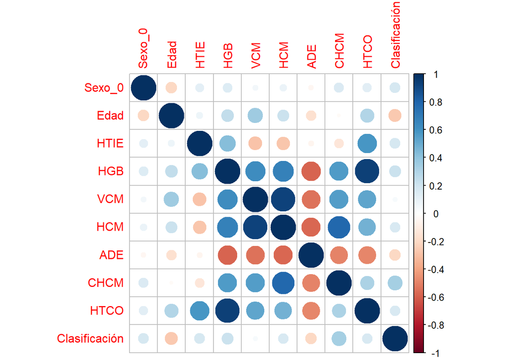

```r
corrplot(cor(dataset.train_cor[2:ncol(dataset.train_cor)],method="spearman"))
```

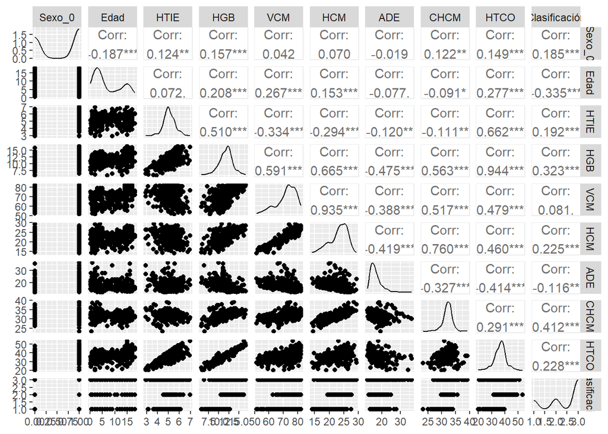

```r
ggpairs(dataset.train_cor[2:ncol(dataset.train)])
```

```r
descrCor <-  cor(x.train, method="spearman")
highCorr <- sum(abs(descrCor[upper.tri(descrCor)]) > .999)
summary(descrCor[upper.tri(descrCor)])
```

```
##     Min.  1st Qu.   Median     Mean  3rd Qu.     Max.
## -1.00000 -0.14270  0.07440  0.08773  0.35208  0.93207
```

```r
#Eliminamos las correlaciones >0.80
highlyCorDescr <- findCorrelation(descrCor, cutoff = .90)
x.train_filtered <- x.train[,-highlyCorDescr]
descrCor2 <- cor(x.train_filtered, method="spearman")
summary(descrCor2[upper.tri(descrCor2)])
```

```
##     Min.  1st Qu.   Median     Mean  3rd Qu.     Max.
## -0.54030 -0.15117 -0.05180  0.01523  0.29957  0.58296
```

Resultado es la eliminación de 3 variables: uno de los sexos (estaba repetido), Hb y HCM.

```r
# Para dataset_retis
descrCor <-  cor(x.train_retis, method="spearman")
highCorr <- sum(abs(descrCor[upper.tri(descrCor)]) > .999)
summary(descrCor[upper.tri(descrCor)])
```

```
##     Min.  1st Qu.   Median     Mean  3rd Qu.     Max.
## -1.00000 -0.17708 -0.06349  0.04207  0.21001  0.96973
```

```r
#Eliminamos las correlaciones >0.80
highlyCorDescr <- findCorrelation(descrCor, cutoff = .90)
x.train_filtered_retis <- x.train_retis[,-highlyCorDescr]
descrCor2 <- cor(x.train_filtered_retis, method="spearman")
summary(descrCor2[upper.tri(descrCor2)])
```

```
##      Min.   1st Qu.    Median      Mean   3rd Qu.      Max.
## -0.483985 -0.172521 -0.088085 -0.005188  0.203917  0.554595
```

```r
#Quitamos estas variables también del dataset.test
x.test_filtered= x.test[, colnames(x.train_filtered)]


#dataset_retis
x.test_filtered_retis= x.test_retis[, colnames(x.train_filtered_retis)]
```

```r
#Cambio de nombre de la columna Sexo
names(x.train_filtered)[names(x.train_filtered) == "Sexo_1"] = "Sexo"
names(x.train_filtered_retis)[names(x.train_filtered_retis) == "Sexo_1"] = "Sexo"

names(x.test_filtered)[names(x.test_filtered) == "Sexo_1"] = "Sexo"
names(x.test_filtered_retis)[names(x.test_filtered_retis) == "Sexo_1"] = "Sexo"
```

## 3.4 Análisis de componentes principales

Por último, se puede realizar una representación en dimensión reducida:

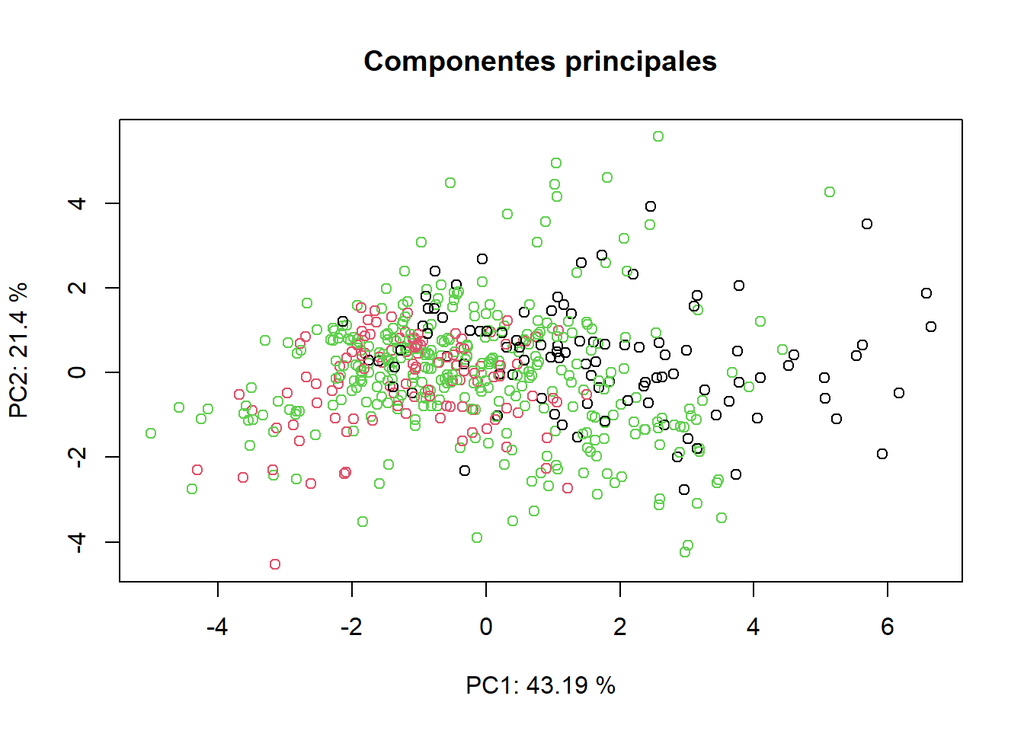

```r
PCA = prcomp(dataset.train[2:(ncol(dataset.train)-1)],center = TRUE,scale. = TRUE)

# Obtener las varianzas explicadas por cada componente principal
varianza_explicada = PCA$sdev^2

# Calcular el porcentaje de variabilidad explicada por PC1 y PC2
porcentaje_explicado_PC1 <- varianza_explicada[1] / sum(varianza_explicada) * 100
porcentaje_explicado_PC2 <- varianza_explicada[2] / sum(varianza_explicada) * 100


PCA.raw = PCA$x[,1:2]
plot(PCA.raw[,1], PCA.raw[,2],main = "Componentes principales",xlab = paste("PC1:", round(porcentaje_explicado_PC1, 2), "%"),ylab = paste("PC2:", round(porcentaje_explicado_PC2, 2), "%"),type="n")
points(PCA.raw[,1], PCA.raw[,2],col=as.factor(dataset.train$Clasificación))
```

No se ven grupos según la clasificación.

## 3.6 Normalizamos

Realizamos la normalización de los datos basándonos en los datos de entrenamiento y será esta normalización la que utilicemos para la partición test.

```r
preProcValues = preProcess(x.train_filtered, method = c("center", "scale"))

trainTransformed = predict(preProcValues, x.train_filtered)
testTransformed = predict(preProcValues, x.test_filtered)
dataset.test=cbind(testTransformed, y.test)
dataset.train= cbind(trainTransformed, y.train)
```

```r
#dataset_retis

preProcValues_retis = preProcess(x.train_filtered_retis, method = c("center", "scale"))

trainTransformed = predict(preProcValues_retis, x.train_filtered_retis)
testTransformed = predict(preProcValues_retis, x.test_filtered_retis)
dataset.test_retis=cbind(testTransformed, y.test_retis)
dataset.train_retis= cbind(trainTransformed, y.train_retis)

names(dataset.train_retis)[names(dataset.train_retis) == "Sexo_1"] = "Sexo"
names(dataset.test_retis)[names(dataset.test_retis) == "Sexo_1"] = "Sexo"
```

Vemos el resultado de la normalización:

```r
summary(trainTransformed)
```

```
##       Sexo              Edad              HTIE               VCM
##  Min.   :-0.9199   Min.   :-1.2817   Min.   :-4.23051   Min.   :-2.6305
##  1st Qu.:-0.9199   1st Qu.:-0.9682   1st Qu.:-0.45841   1st Qu.:-0.7449
##  Median :-0.9199   Median :-0.4309   Median : 0.02407   Median : 0.2806
##  Mean   : 0.0000   Mean   : 0.0000   Mean   : 0.00000   Mean   : 0.0000
##  3rd Qu.: 1.0827   3rd Qu.: 1.0021   3rd Qu.: 0.56137   3rd Qu.: 0.6875
##  Max.   : 1.0827   Max.   : 1.8977   Max.   : 2.50956   Max.   : 1.6170
##       ADE               CHCM                HTCO               REAB
##  Min.   :-1.2036   Min.   :-4.278576   Min.   :-3.93924   Min.   :-0.98655
##  1st Qu.:-0.6464   1st Qu.:-0.346642   1st Qu.:-0.52708   1st Qu.:-0.46870
##  Median :-0.2830   Median :-0.002597   Median : 0.04479   Median :-0.23722
##  Mean   : 0.0000   Mean   : 0.000000   Mean   : 0.00000   Mean   : 0.00000
##  3rd Qu.: 0.2681   3rd Qu.: 0.488894   3rd Qu.: 0.55471   3rd Qu.: 0.08949
##  Max.   : 4.5863   Max.   : 4.027636   Max.   : 2.75164   Max.   : 6.41011
```

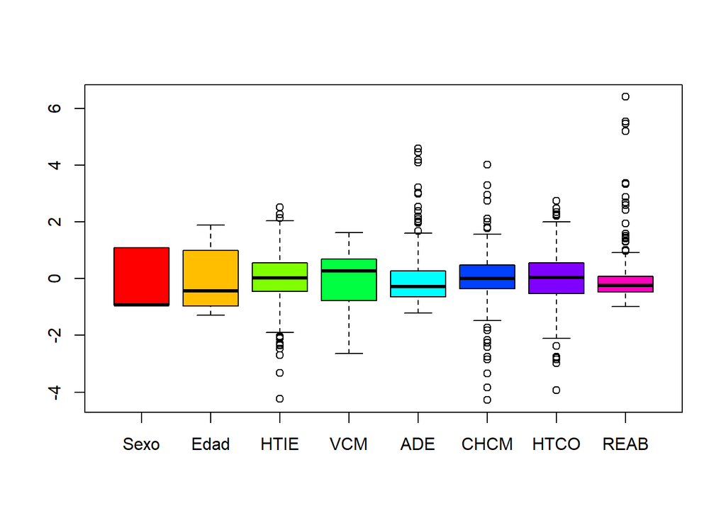

```r
#Volvemos a representar el boxplot de las variables cuantitativas del conjunto de entrenamiento
boxplot(trainTransformed, col= colores)
```

```r
names(dataset.train)
```

```
## [1] "Sexo"          "Edad"          "HTIE"          "VCM"
## [5] "ADE"           "CHCM"          "HTCO"          "Clasificación"
```

## 3.6 Balanceo de los datos de entrenamiento

Como hemos visto previamente, tenemos unos datos desbalanceados, por lo que vamos a utilizar la función SMOTE que crea nuevos casos sintéticos basados en los casos minoritarios.

```r
dataset.train_SMOTE=dataset.train
library(smotefamily)
#oversampling AF
set.seed(29)
for (i in 1:nrow(dataset.train_SMOTE)){
  dataset.train_SMOTE$AF[i] <- ifelse(dataset.train_SMOTE$Clasificación[i] == "AF","AF",0)
}
TRAINSET123.2 <- dataset.train_SMOTE[,-(ncol(dataset.train_SMOTE)-1)]
smote_result_AF = SMOTE(TRAINSET123.2[,-ncol(TRAINSET123.2)],target = TRAINSET123.2$AF, K = 18, dup_size = 1)

oversampled_AF = smote_result_AF$data
str(oversampled_AF)
```

```
## 'data.frame':    637 obs. of  8 variables:
##  $ Sexo : num  1.192 -0.837 1.192 1.192 -0.837 ...
##  $ Edad : num  1.849 1.301 1.483 0.935 -0.894 ...
##  $ HTIE : num  -0.741 -0.473 -1.226 -0.757 0.799 ...
##  $ VCM  : num  0.121 -0.881 -2.502 -0.483 -3.077 ...
##  $ ADE  : num  -0.0139 0.0446 1.5357 -0.1016 2.0035 ...
##  $ CHCM : num  -1.557 -0.246 -1.785 -0.816 -2.64 ...
##  $ HTCO : num  -0.583 -1.042 -2.751 -1.021 -1.743 ...
##  $ class: chr  "AF" "AF" "AF" "AF" ...
```

```r
extra_AF<- filter(oversampled_AF, oversampled_AF$class == "AF")
nrow(extra_AF)
```

```
## [1] 198
```

```r
length(extra_AF)
```

```
## [1] 8
```

```r
str(extra_AF)
```

```
## 'data.frame':    198 obs. of  8 variables:
##  $ Sexo : num  1.192 -0.837 1.192 1.192 -0.837 ...
##  $ Edad : num  1.849 1.301 1.483 0.935 -0.894 ...
##  $ HTIE : num  -0.741 -0.473 -1.226 -0.757 0.799 ...
##  $ VCM  : num  0.121 -0.881 -2.502 -0.483 -3.077 ...
##  $ ADE  : num  -0.0139 0.0446 1.5357 -0.1016 2.0035 ...
##  $ CHCM : num  -1.557 -0.246 -1.785 -0.816 -2.64 ...
##  $ HTCO : num  -0.583 -1.042 -2.751 -1.021 -1.743 ...
##  $ class: chr  "AF" "AF" "AF" "AF" ...
```

```r
#oversampling FF/FL
for (i in 1:nrow(dataset.train_SMOTE)){
  dataset.train_SMOTE$FF[i] <- ifelse(dataset.train_SMOTE$Clasificación[i] == "FF/FL","FF/FL",0)
}
TRAINSET123.3 <- dataset.train_SMOTE[,-c(ncol(dataset.train_SMOTE)-1, (ncol(dataset.train_SMOTE)-2))]
smote_result_FF = SMOTE(TRAINSET123.3[,-ncol(TRAINSET123.3)],target = TRAINSET123.3$FF, K = 18, dup_size = 1)

oversampled_FF = smote_result_FF$data
extra_FF_FL<- filter(oversampled_FF, oversampled_FF$class == "FF/FL")
str(extra_FF_FL)
```

```
## 'data.frame':    228 obs. of  8 variables:
##  $ Sexo : num  1.192 -0.837 -0.837 -0.837 -0.837 ...
##  $ Edad : num  -0.528 1.118 1.483 -0.528 -1.077 ...
##  $ HTIE : num  -0.1048 0.5813 3.2085 0.0626 0.9327 ...
##  $ VCM  : num  1.005 0.136 0.622 0.298 -1.058 ...
##  $ ADE  : num  0.571 -0.102 0.395 -0.599 0.249 ...
##  $ CHCM : num  0.0954 0.4944 -0.7024 -0.1895 -0.5884 ...
##  $ HTCO : num  0.6657 0.6876 3.7097 0.3153 0.0307 ...
##  $ class: chr  "FF/FL" "FF/FL" "FF/FL" "FF/FL" ...
```

```r
#create NEWTRAIN SET
data.train= subset(dataset.train_SMOTE, Clasificación == "NF")
#Nos quedamos con 200 pacientes de NF
#data.train= data.train[sample(nrow(data.train), 200),]

data.train= data.train[,-c(ncol(data.train), (ncol(data.train)-1))]

#Cambiamos el nombre a la columna de clasificación para poder fusionarlas
colnames(extra_AF)[colnames(extra_AF) == "class"]="Clasificación"
colnames(extra_FF_FL)[colnames(extra_FF_FL) == "class"] = "Clasificación"


data.train2 <- rbind(data.train,extra_AF, extra_FF_FL)
dataset.train_SMOTE=data.train2

# Aletorizamos el orden
dataset.train_SMOTE=dataset.train_SMOTE[sample(nrow(dataset.train_SMOTE)), ]
```

```r
#vemos cómo queda la distribución
table(dataset.train$Clasificación)
```

```
##
##    AF FF/FL    NF
##    99   114   325
```

```r
table(dataset.train_SMOTE$Clasificación)
```

```
##
##    AF FF/FL    NF
##   198   228   325
```

```r
round(table(dataset.train_SMOTE$Clasificación)/nrow(dataset.train_SMOTE)*100,2)
```

```
##
##    AF FF/FL    NF
## 26.36 30.36 43.28
```

```r
#repetimos el proceso para tener en cuenta los reticulocitos
dataset.train_SMOTE_retis=dataset.train_retis
library(smotefamily)
#oversampling AF
set.seed(29)
for (i in 1:nrow(dataset.train_SMOTE_retis)){
  dataset.train_SMOTE_retis$AF[i] <- ifelse(dataset.train_SMOTE_retis$Clasificación[i] == "AF","AF",0)
}
TRAINSET123.2 <- dataset.train_SMOTE_retis[,-(ncol(dataset.train_SMOTE_retis)-1)]
smote_result_AF = SMOTE(TRAINSET123.2[,-ncol(TRAINSET123.2)],target = TRAINSET123.2$AF, K = 18, dup_size = 1)

oversampled_AF = smote_result_AF$data
str(oversampled_AF)
```

```
## 'data.frame':    283 obs. of  9 variables:
##  $ Sexo : num  1.08 1.08 -0.92 1.08 -0.92 ...
##  $ Edad : num  1.36 -0.61 -1.222 1.36 -0.789 ...
##  $ HTIE : num  -0.59 -0.488 -1.072 -0.882 -0.371 ...
##  $ VCM  : num  -0.222 -2.3 -0.897 0.876 -0.368 ...
##  $ ADE  : num  0.00768 1.29165 0.46797 -0.065 -0.08922 ...
##  $ CHCM : num  -1.477 -2.263 -4.279 -0.15 -0.347 ...
##  $ HTCO : num  -0.661 -2.033 -1.537 -0.203 -0.565 ...
##  $ REAB : num  0.1827 -0.2723 0.6259 0.0716 -0.0646 ...
##  $ class: chr  "AF" "AF" "AF" "AF" ...
```

```r
extra_AF<- filter(oversampled_AF, oversampled_AF$class == "AF")
nrow(extra_AF)
```

```
## [1] 74
```

```r
length(extra_AF)
```

```
## [1] 9
```

```r
str(extra_AF)
```

```
## 'data.frame':    74 obs. of  9 variables:
##  $ Sexo : num  1.08 1.08 -0.92 1.08 -0.92 ...
##  $ Edad : num  1.36 -0.61 -1.222 1.36 -0.789 ...
##  $ HTIE : num  -0.59 -0.488 -1.072 -0.882 -0.371 ...
##  $ VCM  : num  -0.222 -2.3 -0.897 0.876 -0.368 ...
##  $ ADE  : num  0.00768 1.29165 0.46797 -0.065 -0.08922 ...
##  $ CHCM : num  -1.477 -2.263 -4.279 -0.15 -0.347 ...
##  $ HTCO : num  -0.661 -2.033 -1.537 -0.203 -0.565 ...
##  $ REAB : num  0.1827 -0.2723 0.6259 0.0716 -0.0646 ...
##  $ class: chr  "AF" "AF" "AF" "AF" ...
```

```r
#oversampling FF/FL
for (i in 1:nrow(dataset.train_SMOTE_retis)){
  dataset.train_SMOTE_retis$FF[i] <- ifelse(dataset.train_SMOTE_retis$Clasificación[i] == "FF/FL","FF/FL",0)
}
TRAINSET123.3 <- dataset.train_SMOTE_retis[,-c(ncol(dataset.train_SMOTE_retis)-1, (ncol(dataset.train_SMOTE_retis)-2))]
smote_result_FF = SMOTE(TRAINSET123.3[,-ncol(TRAINSET123.3)],target = TRAINSET123.3$FF, K = 18, dup_size = 1)

oversampled_FF = smote_result_FF$data
extra_FF_FL<- filter(oversampled_FF, oversampled_FF$class == "FF/FL")
str(extra_FF_FL)
```

```
## 'data.frame':    90 obs. of  9 variables:
##  $ Sexo : num  -0.92 -0.92 1.08 -0.92 -0.92 ...
##  $ Edad : num  -0.789 1.36 1.181 1.36 1.719 ...
##  $ HTIE : num  -0.371 1.34 -0.868 0.302 -0.473 ...
##  $ VCM  : num  0.651 0.81 1.591 0.982 1.617 ...
##  $ ADE  : num  -0.768 1.534 -0.816 -0.501 2.018 ...
##  $ CHCM : num  0.9804 0.194 0.0466 0.538 0.2431 ...
##  $ HTCO : num  0.159 1.97 0.293 1.074 0.731 ...
##  $ REAB : num  -0.549 -0.82 -0.641 -0.509 -0.763 ...
##  $ class: chr  "FF/FL" "FF/FL" "FF/FL" "FF/FL" ...
```

```r
#create NEWTRAIN SET
data.train= subset(dataset.train_SMOTE_retis, Clasificación == "NF")

data.train= data.train[,-c(ncol(data.train), (ncol(data.train)-1))]

#Cambiamos el nombre a la columna de clasificación para poder fusionarlas
colnames(extra_AF)[colnames(extra_AF) == "class"]="Clasificación"
colnames(extra_FF_FL)[colnames(extra_FF_FL) == "class"] = "Clasificación"



data.train2 <- rbind(data.train,extra_AF, extra_FF_FL)
table(data.train2$Clasificación)
```

```
##
##    AF FF/FL    NF
##    74    90   164
```

```r
dataset.train_SMOTE_retis=data.train2

# Aletorizamos el orden
dataset.train_SMOTE_retis=dataset.train_SMOTE_retis[sample(nrow(dataset.train_SMOTE_retis)), ]
```

# 4. Aplicación de cada algoritmo para la clasificación

## 4.1. Clases equilibradas

### 4.1.1 k-Nearest Neighbour

```r
# modelo
set.seed(29)
modelo_knn <- train(Clasificación ~ ., data = dataset.train_SMOTE,
                    method = "knn",
                    metric = "Kappa",
                    trControl= fitControl)

modelo_knn
```

```
## k-Nearest Neighbors
##
## 751 samples
##   7 predictor
##   3 classes: 'AF', 'FF/FL', 'NF'
##
## No pre-processing
## Resampling: Cross-Validated (10 fold)
## Summary of sample sizes: 675, 676, 676, 675, 676, 676, ...
## Resampling results across tuning parameters:
##
##   k  Accuracy   Kappa      Mean_F1    Mean_Sensitivity  Mean_Specificity
##   5  0.7228554  0.5798352  0.7331449  0.7445092         0.8581967
##   7  0.7204016  0.5762438  0.7301223  0.7412107         0.8568296
##   9  0.6937862  0.5366609  0.7048620  0.7174987         0.8429444
##   Mean_Pos_Pred_Value  Mean_Neg_Pred_Value  Mean_Precision  Mean_Recall
##   0.7362035            0.8583868            0.7362035       0.7445092
##   0.7325420            0.8573101            0.7325420       0.7412107
##   0.7068003            0.8439940            0.7068003       0.7174987
##   Mean_Detection_Rate  Mean_Balanced_Accuracy
##   0.2409518            0.8013530
##   0.2401339            0.7990202
##   0.2312621            0.7802216
##
## Kappa was used to select the optimal model using the largest value.
## The final value used for the model was k = 5.
```

```r
# Predicciones
p <- predict(modelo_knn, newdata = dataset.test[,-(ncol(dataset.test))])

# Evaluación
(mconfusion_knn <- confusionMatrix(p, dataset.test$Clasificación, mode="everything", positive="AF"))
```

```
## Confusion Matrix and Statistics
##
##           Reference
## Prediction AF FF/FL NF
##      AF    32     4 11
##      FF/FL  2    33 31
##      NF     8    11 97
##
## Overall Statistics
##
##                Accuracy : 0.7074
##                  95% CI : (0.6439, 0.7655)
##     No Information Rate : 0.607
##     P-Value [Acc > NIR] : 0.0009807
##
##                   Kappa : 0.5078
##
##  Mcnemar's Test P-Value : 0.0136877
##
## Statistics by Class:
##
##                      Class: AF Class: FF/FL Class: NF
## Sensitivity             0.7619       0.6875    0.6978
## Specificity             0.9198       0.8177    0.7889
## Pos Pred Value          0.6809       0.5000    0.8362
## Neg Pred Value          0.9451       0.9080    0.6283
## Precision               0.6809       0.5000    0.8362
## Recall                  0.7619       0.6875    0.6978
## F1                      0.7191       0.5789    0.7608
## Prevalence              0.1834       0.2096    0.6070
## Detection Rate          0.1397       0.1441    0.4236
## Detection Prevalence    0.2052       0.2882    0.5066
## Balanced Accuracy       0.8408       0.7526    0.7434
```

```r
resultados_knn <- data.frame(
  Modelo        = "KNN",
  Precisión     = round((ifelse(is.na(mconfusion_knn$byClass[1,5]), 0, mconfusion_knn$byClass[1,5]) +
                         ifelse(is.na(mconfusion_knn$byClass[2,5]), 0, mconfusion_knn$byClass[2,5]) +
                         ifelse(is.na(mconfusion_knn$byClass[3,5]), 0, mconfusion_knn$byClass[3,5])) / 3, 3),
  Sensibilidad  = round((ifelse(is.na(mconfusion_knn$byClass[1,1]), 0, mconfusion_knn$byClass[1,1]) +
                         ifelse(is.na(mconfusion_knn$byClass[2,1]), 0, mconfusion_knn$byClass[2,1]) +
                         ifelse(is.na(mconfusion_knn$byClass[3,1]), 0, mconfusion_knn$byClass[3,1])) / 3, 3),
  Especificidad = round((ifelse(is.na(mconfusion_knn$byClass[1,2]), 0, mconfusion_knn$byClass[1,2]) +
                         ifelse(is.na(mconfusion_knn$byClass[2,2]), 0, mconfusion_knn$byClass[2,2]) +
                         ifelse(is.na(mconfusion_knn$byClass[3,2]), 0, mconfusion_knn$byClass[3,2])) / 3, 3),
  kappa         = round(mconfusion_knn[["overall"]][["Kappa"]], 3),
  F1            = round((ifelse(is.na(mconfusion_knn$byClass[1,7]), 0, mconfusion_knn$byClass[1,7]) +
                         ifelse(is.na(mconfusion_knn$byClass[2,7]), 0, mconfusion_knn$byClass[2,7]) +
                         ifelse(is.na(mconfusion_knn$byClass[3,7]), 0, mconfusion_knn$byClass[3,7])) / 3, 3),
  Error_clasificación = round((1 - mconfusion_knn[["overall"]][["Accuracy"]]) * 100, 3),
  Accuracy      = round(mconfusion_knn[["overall"]][["Accuracy"]], 3)
)

resultados_knn
```

```
##   Modelo Precisión Sensibilidad Especificidad kappa    F1 Error_clasificación
## 1    KNN     0.672        0.716         0.842 0.508 0.686              29.258
##   Accuracy
## 1    0.707
```

### 4.1.2 Naive Bayes

```r
# Ajuste del modelo
set.seed(29)
(modelo_bayes = train(Clasificación ~ ., data = dataset.train_SMOTE,
                   method = "nb",
                   metric = "Kappa",
                   trControl= fitControl))
```

```
## Naive Bayes
##
## 751 samples
##   7 predictor
##   3 classes: 'AF', 'FF/FL', 'NF'
##
## No pre-processing
## Resampling: Cross-Validated (10 fold)
## Summary of sample sizes: 675, 676, 676, 675, 676, 676, ...
## Resampling results across tuning parameters:
##
##   usekernel  Accuracy   Kappa      Mean_F1    Mean_Sensitivity
##   FALSE      0.6166060  0.4223225  0.6295468  0.6382212
##    TRUE      0.6111849  0.4096577  0.6231199  0.6322340
##   Mean_Specificity  Mean_Pos_Pred_Value  Mean_Neg_Pred_Value  Mean_Precision
##   0.8054636         0.6552491            0.8087513            0.6552491
##   0.7997137         0.6292108            0.8010281            0.6292108
##   Mean_Recall  Mean_Detection_Rate  Mean_Balanced_Accuracy
##   0.6382212    0.2055353            0.7218424
##   0.6322340    0.2037283            0.7159738
##
## Tuning parameter 'fL' was held constant at a value of 0
## Tuning
##  parameter 'adjust' was held constant at a value of 1
## Kappa was used to select the optimal model using the largest value.
## The final values used for the model were fL = 0, usekernel = FALSE and adjust
##  = 1.
```

```r
# Predicciones
p <- predict(modelo_bayes, dataset.test[1:(ncol(dataset.test)-1)])

# Evaluación
(mconfusion_Bayes <- confusionMatrix(p, dataset.test$Clasificación, mode="everything", positive="AF"))
```

```
## Confusion Matrix and Statistics
##
##           Reference
## Prediction AF FF/FL NF
##      AF    28     0 12
##      FF/FL  4    34 58
##      NF    10    14 69
##
## Overall Statistics
##
##                Accuracy : 0.5721
##                  95% CI : (0.5052, 0.637)
##     No Information Rate : 0.607
##     P-Value [Acc > NIR] : 0.8747
##
##                   Kappa : 0.3246
##
##  Mcnemar's Test P-Value : 8.214e-07
##
## Statistics by Class:
##
##                      Class: AF Class: FF/FL Class: NF
## Sensitivity             0.6667       0.7083    0.4964
## Specificity             0.9358       0.6575    0.7333
## Pos Pred Value          0.7000       0.3542    0.7419
## Neg Pred Value          0.9259       0.8947    0.4853
## Precision               0.7000       0.3542    0.7419
## Recall                  0.6667       0.7083    0.4964
## F1                      0.6829       0.4722    0.5948
## Prevalence              0.1834       0.2096    0.6070
## Detection Rate          0.1223       0.1485    0.3013
## Detection Prevalence    0.1747       0.4192    0.4061
## Balanced Accuracy       0.8012       0.6829    0.6149
```

```r
resultados_NaiveBayes <- data.frame(
  Modelo        = "Naive Bayes",
  Precisión     = round((ifelse(is.na(mconfusion_Bayes$byClass[1,5]), 0, mconfusion_Bayes$byClass[1,5]) +
                        ifelse(is.na(mconfusion_Bayes$byClass[2,5]), 0, mconfusion_Bayes$byClass[2,5]) +
                        ifelse(is.na(mconfusion_Bayes$byClass[3,5]), 0, mconfusion_Bayes$byClass[3,5])
                        ) / 3, 3),
  Sensibilidad  = round((ifelse(is.na(mconfusion_Bayes$byClass[1,1]), 0, mconfusion_Bayes$byClass[1,1]) +
                        ifelse(is.na(mconfusion_Bayes$byClass[2,1]), 0, mconfusion_Bayes$byClass[2,1]) +
                        ifelse(is.na(mconfusion_Bayes$byClass[3,1]), 0, mconfusion_Bayes$byClass[3,1])
                        ) / 3, 3),
  Especificidad = round((ifelse(is.na(mconfusion_Bayes$byClass[1,2]), 0, mconfusion_Bayes$byClass[1,2]) +
                        ifelse(is.na(mconfusion_Bayes$byClass[2,2]), 0, mconfusion_Bayes$byClass[2,2]) +
                        ifelse(is.na(mconfusion_Bayes$byClass[3,2]), 0, mconfusion_Bayes$byClass[3,2])
                        ) / 3, 3),
  kappa         = round(mconfusion_Bayes[["overall"]][["Kappa"]], 3),
  F1            = round((ifelse(is.na(mconfusion_Bayes$byClass[1,7]), 0, mconfusion_Bayes$byClass[1,7]) +
                        ifelse(is.na(mconfusion_Bayes$byClass[2,7]), 0, mconfusion_Bayes$byClass[2,7]) +
                        ifelse(is.na(mconfusion_Bayes$byClass[3,7]), 0, mconfusion_Bayes$byClass[3,7])
                        ) / 3, 3),
  Error_clasificación = round((1 - mconfusion_Bayes[["overall"]][["Accuracy"]]) * 100, 3),
  Accuracy      = round(mconfusion_Bayes[["overall"]][["Accuracy"]], 3)
)

resultados_NaiveBayes
```

```
##        Modelo Precisión Sensibilidad Especificidad kappa    F1
## 1 Naive Bayes     0.599        0.624         0.776 0.325 0.583
##   Error_clasificación Accuracy
## 1              42.795    0.572
```

### 4.1.4 ANN

```r
# Ajuste del modelo
set.seed(29)

(modelo_ann <- train(Clasificación ~ ., data = dataset.train_SMOTE,
                    method = "nnet",
                    metric = "Kappa",
                    trControl= fitControl,
                    trace = FALSE))
```

```
## Neural Network
##
## 751 samples
##   7 predictor
##   3 classes: 'AF', 'FF/FL', 'NF'
##
## No pre-processing
## Resampling: Cross-Validated (10 fold)
## Summary of sample sizes: 675, 676, 676, 675, 676, 676, ...
## Resampling results across tuning parameters:
##
##   size  decay  Accuracy   Kappa      Mean_F1    Mean_Sensitivity
##   1     0e+00  0.5458966  0.2911237  0.5015470  0.5516059
##   1     1e-04  0.5670550  0.3116671  0.4462550  0.5572353
##   1     1e-01  0.5417914  0.2896396  0.5497193  0.5539438
##   3     0e+00  0.6551176  0.4664983  0.6596101  0.6610633
##   3     1e-04  0.7167563  0.5651853  0.7204729  0.7267472
##   3     1e-01  0.7445448  0.6073993  0.7499143  0.7510709
##   5     0e+00  0.6644514  0.4858855  0.6710062  0.6780358
##   5     1e-04  0.7137710  0.5617978  0.7213105  0.7252592
##   5     1e-01  0.7351588  0.5939123  0.7415826  0.7458759
##   Mean_Specificity  Mean_Pos_Pred_Value  Mean_Neg_Pred_Value  Mean_Precision
##   0.7548502         0.4866214            0.7803187            0.4866214
##   0.7606378         0.4265873            0.7927999            0.4265873
##   0.7547091         0.5644141            0.7621551            0.5644141
##   0.8166121         0.6760319            0.8195797            0.6760319
##   0.8513103         0.7259654            0.8543077            0.7259654
##   0.8659115         0.7571680            0.8676173            0.7571680
##   0.8238426         0.6781878            0.8275954            0.6781878
##   0.8506098         0.7268807            0.8518394            0.7268807
##   0.8612573         0.7441596            0.8623935            0.7441596
##   Mean_Recall  Mean_Detection_Rate  Mean_Balanced_Accuracy
##   0.5516059    0.1819655            0.6532280
##   0.5572353    0.1890183            0.6589366
##   0.5539438    0.1805971            0.6543264
##   0.6610633    0.2183725            0.7388377
##   0.7267472    0.2389188            0.7890287
##   0.7510709    0.2481816            0.8084912
##   0.6780358    0.2214838            0.7509392
##   0.7252592    0.2379237            0.7879345
##   0.7458759    0.2450529            0.8035666
##
## Kappa was used to select the optimal model using the largest value.
## The final values used for the model were size = 3 and decay = 0.1.
```

```r
# Predicciones
p <- predict(modelo_ann, newdata = dataset.test[1:(ncol(dataset.test)-1)])

# Evaluación
res = table(p, dataset.test$Clasificación)
(mconfusion_ann = confusionMatrix(res, mode="everything", positive="AF"))
```

```
## Confusion Matrix and Statistics
##
##
## p        AF FF/FL  NF
##   AF     29     2   6
##   FF/FL   1    32  21
##   NF     12    14 112
##
## Overall Statistics
##
##                Accuracy : 0.7555
##                  95% CI : (0.6945, 0.8097)
##     No Information Rate : 0.607
##     P-Value [Acc > NIR] : 1.497e-06
##
##                   Kappa : 0.5595
##
##  Mcnemar's Test P-Value : 0.2917
##
## Statistics by Class:
##
##                      Class: AF Class: FF/FL Class: NF
## Sensitivity             0.6905       0.6667    0.8058
## Specificity             0.9572       0.8785    0.7111
## Pos Pred Value          0.7838       0.5926    0.8116
## Neg Pred Value          0.9323       0.9086    0.7033
## Precision               0.7838       0.5926    0.8116
## Recall                  0.6905       0.6667    0.8058
## F1                      0.7342       0.6275    0.8087
## Prevalence              0.1834       0.2096    0.6070
## Detection Rate          0.1266       0.1397    0.4891
## Detection Prevalence    0.1616       0.2358    0.6026
## Balanced Accuracy       0.8238       0.7726    0.7584
```

```r
resultados_ann <- data.frame(
  Modelo        = "ANN caret",
  Precisión     = round((ifelse(is.na(mconfusion_ann$byClass[1,5]), 0, mconfusion_ann$byClass[1,5]) +
                        ifelse(is.na(mconfusion_ann$byClass[2,5]), 0, mconfusion_ann$byClass[2,5]) +
                        ifelse(is.na(mconfusion_ann$byClass[3,5]), 0, mconfusion_ann$byClass[3,5])
                        ) / 3, 3),
  Sensibilidad  = round((ifelse(is.na(mconfusion_ann$byClass[1,1]), 0, mconfusion_ann$byClass[1,1]) +
                        ifelse(is.na(mconfusion_ann$byClass[2,1]), 0, mconfusion_ann$byClass[2,1]) +
                        ifelse(is.na(mconfusion_ann$byClass[3,1]), 0, mconfusion_ann$byClass[3,1])
                        ) / 3, 3),
  Especificidad = round((ifelse(is.na(mconfusion_ann$byClass[1,2]), 0, mconfusion_ann$byClass[1,2]) +
                        ifelse(is.na(mconfusion_ann$byClass[2,2]), 0, mconfusion_ann$byClass[2,2]) +
                        ifelse(is.na(mconfusion_ann$byClass[3,2]), 0, mconfusion_ann$byClass[3,2])
                        ) / 3, 3),
  kappa         = round(mconfusion_ann[["overall"]][["Kappa"]], 3),
  F1            = round((ifelse(is.na(mconfusion_ann$byClass[1,7]), 0, mconfusion_ann$byClass[1,7]) +
                        ifelse(is.na(mconfusion_ann$byClass[2,7]), 0, mconfusion_ann$byClass[2,7]) +
                        ifelse(is.na(mconfusion_ann$byClass[3,7]), 0, mconfusion_ann$byClass[3,7])
                       ) / 3, 3),
  Error_clasificación = round((1 - mconfusion_ann[["overall"]][["Accuracy"]]) * 100, 3),
  Accuracy      = round(mconfusion_ann[["overall"]][["Accuracy"]], 3)
)

resultados_ann
```

```
##      Modelo Precisión Sensibilidad Especificidad kappa    F1
## 1 ANN caret     0.729        0.721         0.849  0.56 0.723
##   Error_clasificación Accuracy
## 1              24.454    0.755
```

### 4.1.5 Support Vector Machine

#### 4.1.5.1 SVM-lineal

```r
# Ajuste del modelo
set.seed(29)
(modelo_svmlineal = train(Clasificación ~ ., data = dataset.train_SMOTE,
                          method = "svmLinear",
                          metric = "Kappa",
                          trControl= fitControl
                          ))
```

```
## Support Vector Machines with Linear Kernel
##
## 751 samples
##   7 predictor
##   3 classes: 'AF', 'FF/FL', 'NF'
##
## No pre-processing
## Resampling: Cross-Validated (10 fold)
## Summary of sample sizes: 675, 676, 676, 675, 676, 676, ...
## Resampling results:
##
##   Accuracy   Kappa      Mean_F1   Mean_Sensitivity  Mean_Specificity
##   0.6497819  0.4461646  0.638715  0.6370097         0.8077112
##   Mean_Pos_Pred_Value  Mean_Neg_Pred_Value  Mean_Precision  Mean_Recall
##   0.6828212            0.820614             0.6828212       0.6370097
##   Mean_Detection_Rate  Mean_Balanced_Accuracy
##   0.216594             0.7223605
##
## Tuning parameter 'C' was held constant at a value of 1
```

```r
# Predicciones
p = predict(modelo_svmlineal, newdata = dataset.test[1:(ncol(dataset.test)-1)])

# Evaluación
(mconfusion_svmlineal = confusionMatrix(p, dataset.test$Clasificación, mode="everything", positive="AF"))
```

```
## Confusion Matrix and Statistics
##
##           Reference
## Prediction  AF FF/FL  NF
##      AF     28     0  10
##      FF/FL   0    22  10
##      NF     14    26 119
##
## Overall Statistics
##
##                Accuracy : 0.738
##                  95% CI : (0.676, 0.7937)
##     No Information Rate : 0.607
##     P-Value [Acc > NIR] : 2.133e-05
##
##                   Kappa : 0.495
##
##  Mcnemar's Test P-Value : NA
##
## Statistics by Class:
##
##                      Class: AF Class: FF/FL Class: NF
## Sensitivity             0.6667      0.45833    0.8561
## Specificity             0.9465      0.94475    0.5556
## Pos Pred Value          0.7368      0.68750    0.7484
## Neg Pred Value          0.9267      0.86802    0.7143
## Precision               0.7368      0.68750    0.7484
## Recall                  0.6667      0.45833    0.8561
## F1                      0.7000      0.55000    0.7987
## Prevalence              0.1834      0.20961    0.6070
## Detection Rate          0.1223      0.09607    0.5197
## Detection Prevalence    0.1659      0.13974    0.6943
## Balanced Accuracy       0.8066      0.70154    0.7058
```

```r
resultados_svmlineal <- data.frame(
  Modelo              = "SVM lineal",
  Precisión           = round((ifelse(is.na(mconfusion_svmlineal$byClass[1,5]), 0, mconfusion_svmlineal$byClass[1,5]) +
                              ifelse(is.na(mconfusion_svmlineal$byClass[2,5]), 0, mconfusion_svmlineal$byClass[2,5]) +
                              ifelse(is.na(mconfusion_svmlineal$byClass[3,5]), 0, mconfusion_svmlineal$byClass[3,5])) / 3, 3),

  Sensibilidad        = round((ifelse(is.na(mconfusion_svmlineal$byClass[1,1]), 0, mconfusion_svmlineal$byClass[1,1]) +
                              ifelse(is.na(mconfusion_svmlineal$byClass[2,1]), 0, mconfusion_svmlineal$byClass[2,1]) +
                              ifelse(is.na(mconfusion_svmlineal$byClass[3,1]), 0, mconfusion_svmlineal$byClass[3,1])) / 3, 3),

  Especificidad       = round((ifelse(is.na(mconfusion_svmlineal$byClass[1,2]), 0, mconfusion_svmlineal$byClass[1,2]) +
                              ifelse(is.na(mconfusion_svmlineal$byClass[2,2]), 0, mconfusion_svmlineal$byClass[2,2]) +
                              ifelse(is.na(mconfusion_svmlineal$byClass[3,2]), 0, mconfusion_svmlineal$byClass[3,2])) / 3, 3),
  kappa               = round(mconfusion_svmlineal[["overall"]][["Kappa"]], 3),

  F1                  = round((ifelse(is.na(mconfusion_svmlineal$byClass[1,7]), 0, mconfusion_svmlineal$byClass[1,7]) +
                              ifelse(is.na(mconfusion_svmlineal$byClass[2,7]), 0, mconfusion_svmlineal$byClass[2,7]) +
                              ifelse(is.na(mconfusion_svmlineal$byClass[3,7]), 0, mconfusion_svmlineal$byClass[3,7])) / 3, 3),
  Error_clasificación = round((1 - mconfusion_svmlineal[["overall"]][["Accuracy"]]) * 100, 3),
  Accuracy            = round(mconfusion_svmlineal[["overall"]][["Accuracy"]], 3)
)

resultados_svmlineal
```

```
##       Modelo Precisión Sensibilidad Especificidad kappa    F1
## 1 SVM lineal     0.724         0.66         0.816 0.495 0.683
##   Error_clasificación Accuracy
## 1              26.201    0.738
```

#### 4.1.5.2 SVM-RBF o función gaussiana

```r
# Ajuste del modelo
set.seed(29)
(modelo_svmradial = train(Clasificación ~ ., data = dataset.train_SMOTE,
                          method = "svmRadial",
                         metric = "Kappa",
                    trControl= fitControl))
```

```
## Support Vector Machines with Radial Basis Function Kernel
##
## 751 samples
##   7 predictor
##   3 classes: 'AF', 'FF/FL', 'NF'
##
## No pre-processing
## Resampling: Cross-Validated (10 fold)
## Summary of sample sizes: 675, 676, 676, 675, 676, 676, ...
## Resampling results across tuning parameters:
##
##   C     Accuracy   Kappa      Mean_F1    Mean_Sensitivity  Mean_Specificity
##   0.25  0.6964523  0.5191298  0.6835707  0.6811451         0.8322758
##   0.50  0.7111560  0.5469159  0.7069417  0.7051015         0.8422313
##   1.00  0.7284908  0.5788255  0.7310902  0.7311443         0.8541757
##   Mean_Pos_Pred_Value  Mean_Neg_Pred_Value  Mean_Precision  Mean_Recall
##   0.7297491            0.8488880            0.7297491       0.6811451
##   0.7369534            0.8526950            0.7369534       0.7051015
##   0.7454414            0.8598753            0.7454414       0.7311443
##   Mean_Detection_Rate  Mean_Balanced_Accuracy
##   0.2321508            0.7567104
##   0.2370520            0.7736664
##   0.2428303            0.7926600
##
## Tuning parameter 'sigma' was held constant at a value of 0.1410022
## Kappa was used to select the optimal model using the largest value.
## The final values used for the model were sigma = 0.1410022 and C = 1.
```

```r
# Predicciones
p = predict(modelo_svmradial, newdata = dataset.test[1:(ncol(dataset.test)-1)])

# Evaluación
(mconfusion_svmradial = confusionMatrix(p, dataset.test$Clasificación, mode="everything", positive="AF"))
```

```
## Confusion Matrix and Statistics
##
##           Reference
## Prediction  AF FF/FL  NF
##      AF     30     0   5
##      FF/FL   1    27  13
##      NF     11    21 121
##
## Overall Statistics
##
##                Accuracy : 0.7773
##                  95% CI : (0.7178, 0.8295)
##     No Information Rate : 0.607
##     P-Value [Acc > NIR] : 3.228e-08
##
##                   Kappa : 0.5789
##
##  Mcnemar's Test P-Value : 0.1624
##
## Statistics by Class:
##
##                      Class: AF Class: FF/FL Class: NF
## Sensitivity             0.7143       0.5625    0.8705
## Specificity             0.9733       0.9227    0.6444
## Pos Pred Value          0.8571       0.6585    0.7908
## Neg Pred Value          0.9381       0.8883    0.7632
## Precision               0.8571       0.6585    0.7908
## Recall                  0.7143       0.5625    0.8705
## F1                      0.7792       0.6067    0.8288
## Prevalence              0.1834       0.2096    0.6070
## Detection Rate          0.1310       0.1179    0.5284
## Detection Prevalence    0.1528       0.1790    0.6681
## Balanced Accuracy       0.8438       0.7426    0.7575
```

```r
resultados_SVM_radial <- data.frame(
  Modelo              = "SVM-Radial",
  Precisión           = round((ifelse(is.na(mconfusion_svmradial$byClass[1,5]), 0, mconfusion_svmradial$byClass[1,5]) +
                              ifelse(is.na(mconfusion_svmradial$byClass[2,5]), 0, mconfusion_svmradial$byClass[2,5]) +
                              ifelse(is.na(mconfusion_svmradial$byClass[3,5]), 0, mconfusion_svmradial$byClass[3,5])) / 3, 3),

  Sensibilidad        = round((ifelse(is.na(mconfusion_svmradial$byClass[1,1]), 0, mconfusion_svmradial$byClass[1,1]) +
                              ifelse(is.na(mconfusion_svmradial$byClass[2,1]), 0, mconfusion_svmradial$byClass[2,1]) +
                              ifelse(is.na(mconfusion_svmradial$byClass[3,1]), 0, mconfusion_svmradial$byClass[3,1]) ) / 3, 3),

  Especificidad       = round((ifelse(is.na(mconfusion_svmradial$byClass[1,2]), 0, mconfusion_svmradial$byClass[1,2]) +
                              ifelse(is.na(mconfusion_svmradial$byClass[2,2]), 0, mconfusion_svmradial$byClass[2,2]) +
                              ifelse(is.na(mconfusion_svmradial$byClass[3,2]), 0, mconfusion_svmradial$byClass[3,2]) ) / 3, 3),
  kappa               = round(mconfusion_svmradial[["overall"]][["Kappa"]], 3),
  F1                  = round((ifelse(is.na(mconfusion_svmradial$byClass[1,7]), 0, mconfusion_svmradial$byClass[1,7]) +
                              ifelse(is.na(mconfusion_svmradial$byClass[2,7]), 0, mconfusion_svmradial$byClass[2,7]) +
                              ifelse(is.na(mconfusion_svmradial$byClass[3,7]), 0, mconfusion_svmradial$byClass[3,7]) ) / 3, 3),
  Error_clasificación = round((1 - mconfusion_svmradial[["overall"]][["Accuracy"]]) * 100, 3),
  Accuracy            = round(mconfusion_svmradial[["overall"]][["Accuracy"]], 3)
)

resultados_SVM_radial
```

```
##       Modelo Precisión Sensibilidad Especificidad kappa    F1
## 1 SVM-Radial     0.769        0.716         0.847 0.579 0.738
##   Error_clasificación Accuracy
## 1              22.271    0.777
```

#### 4.1.5.3 SVM-polynomial

```r
# Ajuste del modelo
set.seed(29)
(modelo_svmpoly = train(Clasificación ~ ., data = dataset.train_SMOTE,
                          method = "svmPoly",
                          metric = "Kappa",
                    trControl= fitControl))
```

```
## Support Vector Machines with Polynomial Kernel
##
## 751 samples
##   7 predictor
##   3 classes: 'AF', 'FF/FL', 'NF'
##
## No pre-processing
## Resampling: Cross-Validated (10 fold)
## Summary of sample sizes: 675, 676, 676, 675, 676, 676, ...
## Resampling results across tuning parameters:
##
##   degree  scale  C     Accuracy   Kappa       Mean_F1    Mean_Sensitivity
##   1       0.001  0.25  0.4327677  0.00000000        NaN  0.3333333
##   1       0.001  0.50  0.4327677  0.00000000        NaN  0.3333333
##   1       0.001  1.00  0.4527520  0.04098120        NaN  0.3586842
##   1       0.010  0.25  0.5311048  0.20450929        NaN  0.4657034
##   1       0.010  0.50  0.5828781  0.31109774  0.5124328  0.5370914
##   1       0.010  1.00  0.6443594  0.43078881  0.6248703  0.6201292
##   1       0.100  0.25  0.6524135  0.44625794  0.6368191  0.6326575
##   1       0.100  0.50  0.6484841  0.44176981  0.6347130  0.6320853
##   1       0.100  1.00  0.6538359  0.45066679  0.6402742  0.6390789
##   2       0.001  0.25  0.4327677  0.00000000        NaN  0.3333333
##   2       0.001  0.50  0.4540678  0.04365122        NaN  0.3603509
##   2       0.001  1.00  0.5124723  0.16483457        NaN  0.4388311
##   2       0.010  0.25  0.5842115  0.31356364  0.5169723  0.5383549
##   2       0.010  0.50  0.6470441  0.43467372  0.6274229  0.6222125
##   2       0.010  1.00  0.6590450  0.45611576  0.6433863  0.6385252
##   2       0.100  0.25  0.6990128  0.52260498  0.6861453  0.6848692
##   2       0.100  0.50  0.7177349  0.55510910  0.7102031  0.7081247
##   2       0.100  1.00  0.7284376  0.57470276  0.7248978  0.7231282
##   3       0.001  0.25  0.4327677  0.00000000        NaN  0.3333333
##   3       0.001  0.50  0.4872788  0.11301174        NaN  0.4048438
##   3       0.001  1.00  0.5470346  0.23583868        NaN  0.4864477
##   3       0.010  0.25  0.6524486  0.44151437  0.6310356  0.6261820
##   3       0.010  0.50  0.6577117  0.45326022  0.6407543  0.6357066
##   3       0.010  1.00  0.6630986  0.46340669  0.6472413  0.6444210
##   3       0.100  0.25  0.7151745  0.55179769  0.7078075  0.7065437
##   3       0.100  0.50  0.7298250  0.58010209  0.7315324  0.7308244
##   3       0.100  1.00  0.7178056  0.56485484  0.7234225  0.7256382
##   Mean_Specificity  Mean_Pos_Pred_Value  Mean_Neg_Pred_Value  Mean_Precision
```

[output cut: 43 more lines]

```
##   0.6848692    0.2330043            0.7586558
##   0.7081247    0.2392450            0.7761575
##   0.7231282    0.2428125            0.7873608
##   0.3333333    0.1442559            0.5000000
##   0.4048438    0.1624263            0.5521117
##   0.4864477    0.1823449            0.6114312
##   0.6261820    0.2174829            0.7155442
##   0.6357066    0.2192372            0.7226156
##   0.6444210    0.2210329            0.7286163
##   0.7065437    0.2383915            0.7749022
##   0.7308244    0.2432750            0.7925338
##   0.7256382    0.2392685            0.7878309
##
## Kappa was used to select the optimal model using the largest value.
## The final values used for the model were degree = 3, scale = 0.1 and C = 0.5.
```

```r
# Predicciones
p = predict(modelo_svmpoly, newdata = dataset.test[1:(ncol(dataset.test)-1)])

# Evaluación
(mconfusion_svmpoly = confusionMatrix(p, dataset.test$Clasificación, mode="everything", positive="AF"))
```

```
## Confusion Matrix and Statistics
##
##           Reference
## Prediction  AF FF/FL  NF
##      AF     30     0   7
##      FF/FL   1    28  13
##      NF     11    20 119
##
## Overall Statistics
##
##                Accuracy : 0.7729
##                  95% CI : (0.7131, 0.8255)
##     No Information Rate : 0.607
##     P-Value [Acc > NIR] : 7.291e-08
##
##                   Kappa : 0.575
##
##  Mcnemar's Test P-Value : 0.3375
##
## Statistics by Class:
##
##                      Class: AF Class: FF/FL Class: NF
## Sensitivity             0.7143       0.5833    0.8561
## Specificity             0.9626       0.9227    0.6556
## Pos Pred Value          0.8108       0.6667    0.7933
## Neg Pred Value          0.9375       0.8930    0.7468
## Precision               0.8108       0.6667    0.7933
## Recall                  0.7143       0.5833    0.8561
## F1                      0.7595       0.6222    0.8235
## Prevalence              0.1834       0.2096    0.6070
## Detection Rate          0.1310       0.1223    0.5197
## Detection Prevalence    0.1616       0.1834    0.6550
## Balanced Accuracy       0.8384       0.7530    0.7558
```

```r
resultados_SVM_poly <- data.frame(
  Modelo              = "SVM-poly",
  Precisión           = round((ifelse(is.na(mconfusion_svmpoly$byClass[1,5]), 0, mconfusion_svmpoly$byClass[1,5]) +
                              ifelse(is.na(mconfusion_svmpoly$byClass[2,5]), 0, mconfusion_svmpoly$byClass[2,5]) +
                              ifelse(is.na(mconfusion_svmpoly$byClass[3,5]), 0, mconfusion_svmpoly$byClass[3,5]) ) / 3, 3),

  Sensibilidad        = round((ifelse(is.na(mconfusion_svmpoly$byClass[1,1]), 0, mconfusion_svmpoly$byClass[1,1]) +
                              ifelse(is.na(mconfusion_svmpoly$byClass[2,1]), 0, mconfusion_svmpoly$byClass[2,1]) +
                              ifelse(is.na(mconfusion_svmpoly$byClass[3,1]), 0, mconfusion_svmpoly$byClass[3,1]) ) / 3, 3),

  Especificidad       = round((ifelse(is.na(mconfusion_svmpoly$byClass[1,2]), 0, mconfusion_svmpoly$byClass[1,2]) +
                              ifelse(is.na(mconfusion_svmpoly$byClass[2,2]), 0, mconfusion_svmpoly$byClass[2,2]) +
                              ifelse(is.na(mconfusion_svmpoly$byClass[3,2]), 0, mconfusion_svmpoly$byClass[3,2]) ) /3, 3),
  kappa               = round(mconfusion_svmpoly[["overall"]][["Kappa"]], 3),
  F1                  = round((ifelse(is.na(mconfusion_svmpoly$byClass[1,7]), 0, mconfusion_svmpoly$byClass[1,7]) +
                              ifelse(is.na(mconfusion_svmpoly$byClass[2,7]), 0, mconfusion_svmpoly$byClass[2,7]) +
                              ifelse(is.na(mconfusion_svmpoly$byClass[3,7]), 0, mconfusion_svmpoly$byClass[3,7]) ) / 3, 3),
  Error_clasificación = round((1 - mconfusion_svmpoly[["overall"]][["Accuracy"]]) * 100, 3),
  Accuracy            = round(mconfusion_svmpoly[["overall"]][["Accuracy"]], 3)
)

resultados_SVM_poly
```

```
##     Modelo Precisión Sensibilidad Especificidad kappa    F1 Error_clasificación
## 1 SVM-poly     0.757        0.718         0.847 0.575 0.735              22.707
##   Accuracy
## 1    0.773
```

### 4.1.6 Árbol de decisión

```r
# Ajuste del modelo
set.seed(29)
(modelo_C5.0 <- train(Clasificación ~ ., data = dataset.train_SMOTE,
                     method = "C5.0",
                     metric = "Kappa",
                    trControl= fitControl
                     ))
```

```
## C5.0
##
## 751 samples
##   7 predictor
##   3 classes: 'AF', 'FF/FL', 'NF'
##
## No pre-processing
## Resampling: Cross-Validated (10 fold)
## Summary of sample sizes: 675, 676, 676, 675, 676, 676, ...
## Resampling results across tuning parameters:
##
##   model  winnow  trials  Accuracy   Kappa      Mean_F1    Mean_Sensitivity
##   rules  FALSE    1      0.6963973  0.5391155  0.7073251  0.7179187
##   rules  FALSE   10      0.7363855  0.5952172  0.7415395  0.7468245
##   rules  FALSE   20      0.7418435  0.6039598  0.7469994  0.7525564
##   rules   TRUE    1      0.6963973  0.5391155  0.7073251  0.7179187
##   rules   TRUE   10      0.7363855  0.5952172  0.7415395  0.7468245
##   rules   TRUE   20      0.7418435  0.6039598  0.7469994  0.7525564
##   tree   FALSE    1      0.6885415  0.5344940  0.7020105  0.7240827
##   tree   FALSE   10      0.7322949  0.5862817  0.7372372  0.7375889
##   tree   FALSE   20      0.7324211  0.5889019  0.7389471  0.7417570
##   tree    TRUE    1      0.6885415  0.5344940  0.7020105  0.7240827
##   tree    TRUE   10      0.7322949  0.5862817  0.7372372  0.7375889
##   tree    TRUE   20      0.7324211  0.5889019  0.7389471  0.7417570
##   Mean_Specificity  Mean_Pos_Pred_Value  Mean_Neg_Pred_Value  Mean_Precision
##   0.8428833         0.7132392            0.8452960            0.7132392
##   0.8615567         0.7505214            0.8652007            0.7505214
##   0.8647168         0.7500553            0.8662652            0.7500553
##   0.8428833         0.7132392            0.8452960            0.7132392
##   0.8615567         0.7505214            0.8652007            0.7505214
##   0.8647168         0.7500553            0.8662652            0.7500553
##   0.8432416         0.7161802            0.8480167            0.7161802
##   0.8573969         0.7462806            0.8611700            0.7462806
##   0.8591711         0.7445259            0.8613556            0.7445259
##   0.8432416         0.7161802            0.8480167            0.7161802
##   0.8573969         0.7462806            0.8611700            0.7462806
##   0.8591711         0.7445259            0.8613556            0.7445259
##   Mean_Recall  Mean_Detection_Rate  Mean_Balanced_Accuracy
##   0.7179187    0.2321324            0.7804010
##   0.7468245    0.2454618            0.8041906
##   0.7525564    0.2472812            0.8086366
##   0.7179187    0.2321324            0.7804010
##   0.7468245    0.2454618            0.8041906
##   0.7525564    0.2472812            0.8086366
##   0.7240827    0.2295138            0.7836621
##   0.7375889    0.2440983            0.7974929
##   0.7417570    0.2441404            0.8004640
##   0.7240827    0.2295138            0.7836621
##   0.7375889    0.2440983            0.7974929
##   0.7417570    0.2441404            0.8004640
##
## Kappa was used to select the optimal model using the largest value.
## The final values used for the model were trials = 20, model = rules and
##  winnow = TRUE.
```

```r
# Predicciones
p <- predict(modelo_C5.0, dataset.test[1:(ncol(dataset.test)-1)])

# Evaluación
(mconfusion_arbol = confusionMatrix(data = p, reference = dataset.test$Clasificación, mode="everything", positive="AF"))
```

```
## Confusion Matrix and Statistics
##
##           Reference
## Prediction  AF FF/FL  NF
##      AF     30     0  11
##      FF/FL   3    30  16
##      NF      9    18 112
##
## Overall Statistics
##
##                Accuracy : 0.7511
##                  95% CI : (0.6899, 0.8057)
##     No Information Rate : 0.607
##     P-Value [Acc > NIR] : 3.007e-06
##
##                   Kappa : 0.5506
##
##  Mcnemar's Test P-Value : 0.3452
##
## Statistics by Class:
##
##                      Class: AF Class: FF/FL Class: NF
## Sensitivity             0.7143       0.6250    0.8058
## Specificity             0.9412       0.8950    0.7000
## Pos Pred Value          0.7317       0.6122    0.8058
## Neg Pred Value          0.9362       0.9000    0.7000
## Precision               0.7317       0.6122    0.8058
## Recall                  0.7143       0.6250    0.8058
## F1                      0.7229       0.6186    0.8058
## Prevalence              0.1834       0.2096    0.6070
## Detection Rate          0.1310       0.1310    0.4891
## Detection Prevalence    0.1790       0.2140    0.6070
## Balanced Accuracy       0.8277       0.7600    0.7529
```

```r
resultados_arbol <- data.frame(
  Modelo              = "Árbol",
  Precisión           = round((ifelse(is.na(mconfusion_arbol$byClass[1,5]), 0, mconfusion_arbol$byClass[1,5]) +
                              ifelse(is.na(mconfusion_arbol$byClass[2,5]), 0, mconfusion_arbol$byClass[2,5]) +
                              ifelse(is.na(mconfusion_arbol$byClass[3,5]), 0, mconfusion_arbol$byClass[3,5]) ) / 3, 3),
  Sensibilidad        = round((ifelse(is.na(mconfusion_arbol$byClass[1,1]), 0, mconfusion_arbol$byClass[1,1]) +
                              ifelse(is.na(mconfusion_arbol$byClass[2,1]), 0, mconfusion_arbol$byClass[2,1]) +
                              ifelse(is.na(mconfusion_arbol$byClass[3,1]), 0, mconfusion_arbol$byClass[3,1]) ) / 3, 3),

  Especificidad       = round((ifelse(is.na(mconfusion_arbol$byClass[1,2]), 0, mconfusion_arbol$byClass[1,2]) +
                              ifelse(is.na(mconfusion_arbol$byClass[2,2]), 0, mconfusion_arbol$byClass[2,2]) +
                              ifelse(is.na(mconfusion_arbol$byClass[3,2]), 0, mconfusion_arbol$byClass[3,2])) / 3, 3),

  kappa               = round(mconfusion_arbol[["overall"]][["Kappa"]], 3),
  F1                  = round((ifelse(is.na(mconfusion_arbol$byClass[1,7]), 0, mconfusion_arbol$byClass[1,7]) +
                              ifelse(is.na(mconfusion_arbol$byClass[2,7]), 0, mconfusion_arbol$byClass[2,7]) +
                              ifelse(is.na(mconfusion_arbol$byClass[3,7]), 0, mconfusion_arbol$byClass[3,7]) ) / 3, 3),
  Error_clasificación = round((1 - mconfusion_arbol[["overall"]][["Accuracy"]]) * 100, 3),
  Accuracy            = round(mconfusion_arbol[["overall"]][["Accuracy"]], 3)
)

resultados_arbol
```

```
##   Modelo Precisión Sensibilidad Especificidad kappa    F1 Error_clasificación
## 1  Árbol     0.717        0.715         0.845 0.551 0.716              24.891
##   Accuracy
## 1    0.751
```

### 4.1.7 Random Forest

```r
# Ajuste del modelo
set.seed(29)
(modelo_forest <- train(Clasificación ~ ., data = dataset.train_SMOTE,
                   method = "ranger",
                   metric = "Kappa",
                    trControl= fitControl
                   ))
```

```
## Random Forest
##
## 751 samples
##   7 predictor
##   3 classes: 'AF', 'FF/FL', 'NF'
##
## No pre-processing
## Resampling: Cross-Validated (10 fold)
## Summary of sample sizes: 675, 676, 676, 675, 676, 676, ...
## Resampling results across tuning parameters:
##
##   mtry  splitrule   Accuracy   Kappa      Mean_F1    Mean_Sensitivity
##   2     gini        0.7775970  0.6597523  0.7840508  0.7885796
##   2     extratrees  0.8215642  0.7269055  0.8280016  0.8324031
##   4     gini        0.7788952  0.6612238  0.7844017  0.7878250
##   4     extratrees  0.8189682  0.7234688  0.8254507  0.8310957
##   7     gini        0.7708938  0.6488093  0.7768080  0.7802301
##   7     extratrees  0.8056159  0.7031787  0.8122520  0.8181860
##   Mean_Specificity  Mean_Pos_Pred_Value  Mean_Neg_Pred_Value  Mean_Precision
##   0.8842335         0.7889582            0.8850017            0.7889582
##   0.9067004         0.8282226            0.9068048            0.8282226
##   0.8846563         0.7887443            0.8856604            0.7887443
##   0.9057152         0.8266341            0.9060623            0.8266341
##   0.8801494         0.7787335            0.8809278            0.7787335
##   0.8987261         0.8113631            0.8988097            0.8113631
##   Mean_Recall  Mean_Detection_Rate  Mean_Balanced_Accuracy
##   0.7885796    0.2591990            0.8364066
##   0.8324031    0.2738547            0.8695518
##   0.7878250    0.2596317            0.8362407
##   0.8310957    0.2729894            0.8684054
##   0.7802301    0.2569646            0.8301898
##   0.8181860    0.2685386            0.8584560
##
## Tuning parameter 'min.node.size' was held constant at a value of 1
## Kappa was used to select the optimal model using the largest value.
## The final values used for the model were mtry = 2, splitrule = extratrees
##  and min.node.size = 1.
```

```r
# Predicciones
p <- predict(modelo_forest, newdata = dataset.test)


# Evaluación
(mconfusion_forest <- confusionMatrix(data = p, reference = dataset.test$Clasificación, mode="everything", positive="AF"))
```

```
## Confusion Matrix and Statistics
##
##           Reference
## Prediction  AF FF/FL  NF
##      AF     33     2   6
##      FF/FL   1    29   9
##      NF      8    17 124
##
## Overall Statistics
##
##                Accuracy : 0.8122
##                  95% CI : (0.7555, 0.8606)
##     No Information Rate : 0.607
##     P-Value [Acc > NIR] : 1.906e-11
##
##                   Kappa : 0.65
##
##  Mcnemar's Test P-Value : 0.3794
##
## Statistics by Class:
##
##                      Class: AF Class: FF/FL Class: NF
## Sensitivity             0.7857       0.6042    0.8921
## Specificity             0.9572       0.9448    0.7222
## Pos Pred Value          0.8049       0.7436    0.8322
## Neg Pred Value          0.9521       0.9000    0.8125
## Precision               0.8049       0.7436    0.8322
## Recall                  0.7857       0.6042    0.8921
## F1                      0.7952       0.6667    0.8611
## Prevalence              0.1834       0.2096    0.6070
## Detection Rate          0.1441       0.1266    0.5415
## Detection Prevalence    0.1790       0.1703    0.6507
## Balanced Accuracy       0.8715       0.7745    0.8072
```

```r
resultados_RF <- data.frame(
  Modelo              = "Random Forest",
  Precisión           = round((ifelse(is.na(mconfusion_forest$byClass[1,5]), 0, mconfusion_forest$byClass[1,5]) +
                              ifelse(is.na(mconfusion_forest$byClass[2,5]), 0, mconfusion_forest$byClass[2,5]) +
                              ifelse(is.na(mconfusion_forest$byClass[3,5]), 0, mconfusion_forest$byClass[3,5]) ) / 3, 3),
  Sensibilidad        = round((ifelse(is.na(mconfusion_forest$byClass[1,1]), 0, mconfusion_forest$byClass[1,1]) +
                              ifelse(is.na(mconfusion_forest$byClass[2,1]), 0, mconfusion_forest$byClass[2,1]) +
                              ifelse(is.na(mconfusion_forest$byClass[3,1]), 0, mconfusion_forest$byClass[3,1]) ) / 3, 3),
  Especificidad       = round((ifelse(is.na(mconfusion_forest$byClass[1,2]), 0, mconfusion_forest$byClass[1,2]) +
                              ifelse(is.na(mconfusion_forest$byClass[2,2]), 0, mconfusion_forest$byClass[2,2]) +
                              ifelse(is.na(mconfusion_forest$byClass[3,2]), 0, mconfusion_forest$byClass[3,2]) ) / 3, 3),
  kappa               = round(mconfusion_forest[["overall"]][["Kappa"]], 3),
  F1                  = round((ifelse(is.na(mconfusion_forest$byClass[1,7]), 0, mconfusion_forest$byClass[1,7]) +
                              ifelse(is.na(mconfusion_forest$byClass[2,7]), 0, mconfusion_forest$byClass[2,7]) +
                              ifelse(is.na(mconfusion_forest$byClass[3,7]), 0, mconfusion_forest$byClass[3,7]) ) / 3, 3),
  Error_clasificación = round((1 - mconfusion_forest[["overall"]][["Accuracy"]]) * 100, 3),
  Accuracy            = round(mconfusion_forest[["overall"]][["Accuracy"]], 3)
)

resultados_RF
```

```
##          Modelo Precisión Sensibilidad Especificidad kappa    F1
## 1 Random Forest     0.794        0.761         0.875  0.65 0.774
##   Error_clasificación Accuracy
## 1              18.777    0.812
```

### 4.1.8 Boosting

```r
# Ajuste del modelo
set.seed(29)
modelo_boosting <- train(Clasificación ~ ., data = dataset.train_SMOTE,
                   method = "gbm",
                  metric = "Kappa",
                    trControl= fitControl
                   )
modelo_boosting
```

```
## Stochastic Gradient Boosting
##
## 751 samples
##   7 predictor
##   3 classes: 'AF', 'FF/FL', 'NF'
##
## No pre-processing
## Resampling: Cross-Validated (10 fold)
## Summary of sample sizes: 675, 676, 676, 675, 676, 676, ...
## Resampling results across tuning parameters:
##
##   interaction.depth  n.trees  Accuracy   Kappa      Mean_F1    Mean_Sensitivity
##   1                   50      0.6671176  0.4846847  0.6732064  0.6706794
##   1                  100      0.6949592  0.5316461  0.7026235  0.7041605
##   1                  150      0.6936425  0.5296030  0.7013755  0.7031965
##   2                   50      0.7204163  0.5696298  0.7276625  0.7273262
##   2                  100      0.7388554  0.5978106  0.7455350  0.7458995
##   2                  150      0.7376648  0.5980847  0.7458442  0.7492697
##   3                   50      0.7189237  0.5678516  0.7269884  0.7261695
##   3                  100      0.7482978  0.6125048  0.7539515  0.7552978
##   3                  150      0.7577202  0.6279905  0.7640047  0.7674901
##   Mean_Specificity  Mean_Pos_Pred_Value  Mean_Neg_Pred_Value  Mean_Precision
##   0.8232704         0.6825120            0.8254072            0.6825120
##   0.8401172         0.7071717            0.8411834            0.7071717
##   0.8392639         0.7081130            0.8409466            0.7081130
##   0.8532663         0.7359514            0.8541931            0.7359514
##   0.8618979         0.7512798            0.8639906            0.7512798
##   0.8624657         0.7476671            0.8634298            0.7476671
##   0.8519940         0.7329184            0.8532130            0.7329184
##   0.8667416         0.7631162            0.8700015            0.7631162
##   0.8723469         0.7716805            0.8750891            0.7716805
##   Mean_Recall  Mean_Detection_Rate  Mean_Balanced_Accuracy
##   0.6706794    0.2223725            0.7469749
##   0.7041605    0.2316531            0.7721389
##   0.7031965    0.2312142            0.7712302
##   0.7273262    0.2401388            0.7902962
##   0.7458995    0.2462851            0.8038987
##   0.7492697    0.2458883            0.8058677
##   0.7261695    0.2396412            0.7890817
##   0.7552978    0.2494326            0.8110197
##   0.7674901    0.2525734            0.8199185
##
## Tuning parameter 'shrinkage' was held constant at a value of 0.1
##
## Tuning parameter 'n.minobsinnode' was held constant at a value of 10
## Kappa was used to select the optimal model using the largest value.
## The final values used for the model were n.trees = 150, interaction.depth =
##  3, shrinkage = 0.1 and n.minobsinnode = 10.
```

```r
# Predicciones
p <- predict(modelo_boosting, newdata = dataset.test)


# Evaluación
(mconfusion_boosting <- confusionMatrix(data = p, reference = dataset.test$Clasificación, mode="everything", positive="AF"))
```

```
## Confusion Matrix and Statistics
##
##           Reference
## Prediction  AF FF/FL  NF
##      AF     27     2   8
##      FF/FL   1    28  22
##      NF     14    18 109
##
## Overall Statistics
##
##                Accuracy : 0.7162
##                  95% CI : (0.653, 0.7736)
##     No Information Rate : 0.607
##     P-Value [Acc > NIR] : 0.000364
##
##                   Kappa : 0.4839
##
##  Mcnemar's Test P-Value : 0.499300
##
## Statistics by Class:
##
##                      Class: AF Class: FF/FL Class: NF
## Sensitivity             0.6429       0.5833    0.7842
## Specificity             0.9465       0.8729    0.6444
## Pos Pred Value          0.7297       0.5490    0.7730
## Neg Pred Value          0.9219       0.8876    0.6591
## Precision               0.7297       0.5490    0.7730
## Recall                  0.6429       0.5833    0.7842
## F1                      0.6835       0.5657    0.7786
## Prevalence              0.1834       0.2096    0.6070
## Detection Rate          0.1179       0.1223    0.4760
## Detection Prevalence    0.1616       0.2227    0.6157
## Balanced Accuracy       0.7947       0.7281    0.7143
```

```r
resultados_boosting <- data.frame(
  Modelo              = "Boosting",
  Precisión           = round((ifelse(is.na(mconfusion_boosting$byClass[1,5]), 0, mconfusion_boosting$byClass[1,5]) +
                              ifelse(is.na(mconfusion_boosting$byClass[2,5]), 0, mconfusion_boosting$byClass[2,5]) +
                              ifelse(is.na(mconfusion_boosting$byClass[3,5]), 0, mconfusion_boosting$byClass[3,5])  ) / 3, 3),
  Sensibilidad        = round((ifelse(is.na(mconfusion_boosting$byClass[1,1]), 0, mconfusion_boosting$byClass[1,1]) +
                              ifelse(is.na(mconfusion_boosting$byClass[2,1]), 0, mconfusion_boosting$byClass[2,1]) +
                              ifelse(is.na(mconfusion_boosting$byClass[3,1]), 0, mconfusion_boosting$byClass[3,1])  ) /3, 3),
  Especificidad       = round((ifelse(is.na(mconfusion_boosting$byClass[1,2]), 0, mconfusion_boosting$byClass[1,2]) +
                              ifelse(is.na(mconfusion_boosting$byClass[2,2]), 0, mconfusion_boosting$byClass[2,2]) +
                              ifelse(is.na(mconfusion_boosting$byClass[3,2]), 0, mconfusion_boosting$byClass[3,2]) ) / 3, 3),
  kappa               = round(mconfusion_boosting[["overall"]][["Kappa"]], 3),
  F1                  = round((ifelse(is.na(mconfusion_boosting$byClass[1,7]), 0, mconfusion_boosting$byClass[1,7]) +
                              ifelse(is.na(mconfusion_boosting$byClass[2,7]), 0, mconfusion_boosting$byClass[2,7]) +
                              ifelse(is.na(mconfusion_boosting$byClass[3,7]), 0, mconfusion_boosting$byClass[3,7])  ) / 3, 3),
  Error_clasificación = round((1 - mconfusion_boosting[["overall"]][["Accuracy"]]) * 100, 3),
  Accuracy            = round(mconfusion_boosting[["overall"]][["Accuracy"]], 3)
)

resultados_boosting
```

```
##     Modelo Precisión Sensibilidad Especificidad kappa    F1 Error_clasificación
## 1 Boosting     0.684         0.67         0.821 0.484 0.676              28.384
##   Accuracy
## 1    0.716
```

### 4.1.9 Bagging

```r
# Ajuste del modelo
set.seed(29)
(modelo_Bagging <- train(Clasificación ~ ., data = dataset.train_SMOTE,
                   method = "parRF",
                   metric = "Kappa",
                    trControl= fitControl
                   ))
```

```
## Parallel Random Forest
##
## 751 samples
##   7 predictor
##   3 classes: 'AF', 'FF/FL', 'NF'
##
## No pre-processing
## Resampling: Cross-Validated (10 fold)
## Summary of sample sizes: 675, 676, 676, 675, 676, 676, ...
## Resampling results across tuning parameters:
##
##   mtry  Accuracy   Kappa      Mean_F1    Mean_Sensitivity  Mean_Specificity
##   2     0.7828592  0.6678499  0.7888421  0.7936815         0.8870869
##   4     0.7721916  0.6511733  0.7778159  0.7823065         0.8812511
##   7     0.7681911  0.6447505  0.7742537  0.7771801         0.8787643
##   Mean_Pos_Pred_Value  Mean_Neg_Pred_Value  Mean_Precision  Mean_Recall
##   0.7925604            0.8877071            0.7925604       0.7936815
##   0.7816112            0.8822880            0.7816112       0.7823065
##   0.7784380            0.8800894            0.7784380       0.7771801
##   Mean_Detection_Rate  Mean_Balanced_Accuracy
##   0.2609531            0.8403842
##   0.2573972            0.8317788
##   0.2560637            0.8279722
##
## Kappa was used to select the optimal model using the largest value.
## The final value used for the model was mtry = 2.
```

```r
# Predicciones
p <- predict(modelo_Bagging, newdata = dataset.test)


# Evaluación
(mconfusion_Bagging <- confusionMatrix(data = p, reference = dataset.test$Clasificación, mode="everything", positive="AF"))
```

```
## Confusion Matrix and Statistics
##
##           Reference
## Prediction  AF FF/FL  NF
##      AF     29     2   7
##      FF/FL   3    32  17
##      NF     10    14 115
##
## Overall Statistics
##
##                Accuracy : 0.7686
##                  95% CI : (0.7085, 0.8216)
##     No Information Rate : 0.607
##     P-Value [Acc > NIR] : 1.608e-07
##
##                   Kappa : 0.5819
##
##  Mcnemar's Test P-Value : 0.7965
##
## Statistics by Class:
##
##                      Class: AF Class: FF/FL Class: NF
## Sensitivity             0.6905       0.6667    0.8273
## Specificity             0.9519       0.8895    0.7333
## Pos Pred Value          0.7632       0.6154    0.8273
## Neg Pred Value          0.9319       0.9096    0.7333
## Precision               0.7632       0.6154    0.8273
## Recall                  0.6905       0.6667    0.8273
## F1                      0.7250       0.6400    0.8273
## Prevalence              0.1834       0.2096    0.6070
## Detection Rate          0.1266       0.1397    0.5022
## Detection Prevalence    0.1659       0.2271    0.6070
## Balanced Accuracy       0.8212       0.7781    0.7803
```

```r
resultados_bagging <- data.frame(
  Modelo              = "Bagging",
  Precisión           = round((ifelse(is.na(mconfusion_Bagging$byClass[1,5]), 0, mconfusion_Bagging$byClass[1,5]) +
                              ifelse(is.na(mconfusion_Bagging$byClass[2,5]), 0, mconfusion_Bagging$byClass[2,5]) +
                              ifelse(is.na(mconfusion_Bagging$byClass[3,5]), 0, mconfusion_Bagging$byClass[3,5])  ) / 3, 3),
  Sensibilidad        = round((ifelse(is.na(mconfusion_Bagging$byClass[1,1]), 0, mconfusion_Bagging$byClass[1,1]) +
                              ifelse(is.na(mconfusion_Bagging$byClass[2,1]), 0, mconfusion_Bagging$byClass[2,1]) +
                              ifelse(is.na(mconfusion_Bagging$byClass[3,1]), 0, mconfusion_Bagging$byClass[3,1])  ) /3, 3),
  Especificidad       = round((ifelse(is.na(mconfusion_Bagging$byClass[1,2]), 0, mconfusion_Bagging$byClass[1,2]) +
                              ifelse(is.na(mconfusion_Bagging$byClass[2,2]), 0, mconfusion_Bagging$byClass[2,2]) +
                              ifelse(is.na(mconfusion_Bagging$byClass[3,2]), 0, mconfusion_Bagging$byClass[3,2])  ) / 3, 3),
  kappa               = round(mconfusion_Bagging[["overall"]][["Kappa"]], 3),
  F1                  = round((ifelse(is.na(mconfusion_Bagging$byClass[1,7]), 0, mconfusion_Bagging$byClass[1,7]) +
                              ifelse(is.na(mconfusion_Bagging$byClass[2,7]), 0, mconfusion_Bagging$byClass[2,7]) +
                              ifelse(is.na(mconfusion_Bagging$byClass[3,7]), 0, mconfusion_Bagging$byClass[3,7])  ) / 3, 3),
  Error_clasificación = round((1 - mconfusion_Bagging[["overall"]][["Accuracy"]]) * 100, 3),
  Accuracy            = round(mconfusion_Bagging[["overall"]][["Accuracy"]], 3)
)

resultados_bagging
```

```
##    Modelo Precisión Sensibilidad Especificidad kappa    F1 Error_clasificación
## 1 Bagging     0.735        0.728         0.858 0.582 0.731              23.144
##   Accuracy
## 1    0.769
```

### 4.1.10 Tabla resumen del rendimiento de los distintos modelos equilibrados

```r
tabla_resumen_equilibrado = rbind(
                    resultados_knn,
                     resultados_NaiveBayes,
                     resultados_ann,
                     resultados_SVM_radial,
                     resultados_svmlineal,
                     resultados_SVM_poly,
                     resultados_arbol,
                     resultados_RF,
                     resultados_boosting,
                     resultados_bagging
                     )

#Establecemos el orden por valores de Accuracy
orden = order(tabla_resumen_equilibrado$Sensibilidad, decreasing = TRUE)
tabla_resumen_equilibrado_ordenada <- tabla_resumen_equilibrado[orden, ]
tabla_final=tabla_resumen_equilibrado_ordenada
kable(tabla_resumen_equilibrado_ordenada, digits = 3, caption = "Rendimiento de los modelos")
```

Rendimiento de los modelos

|  | Modelo | Precisión | Sensibilidad | Especificidad | kappa | F1 | Error_clasificación | Accuracy |
| --- | --- | --- | --- | --- | --- | --- | --- | --- |
| 8 | Random Forest | 0.794 | 0.761 | 0.875 | 0.650 | 0.774 | 18.777 | 0.812 |
| 10 | Bagging | 0.735 | 0.728 | 0.858 | 0.582 | 0.731 | 23.144 | 0.769 |
| 3 | ANN caret | 0.729 | 0.721 | 0.849 | 0.560 | 0.723 | 24.454 | 0.755 |
| 6 | SVM-poly | 0.757 | 0.718 | 0.847 | 0.575 | 0.735 | 22.707 | 0.773 |
| 1 | KNN | 0.672 | 0.716 | 0.842 | 0.508 | 0.686 | 29.258 | 0.707 |
| 4 | SVM-Radial | 0.769 | 0.716 | 0.847 | 0.579 | 0.738 | 22.271 | 0.777 |
| 7 | Árbol | 0.717 | 0.715 | 0.845 | 0.551 | 0.716 | 24.891 | 0.751 |
| 9 | Boosting | 0.684 | 0.670 | 0.821 | 0.484 | 0.676 | 28.384 | 0.716 |
| 5 | SVM lineal | 0.724 | 0.660 | 0.816 | 0.495 | 0.683 | 26.201 | 0.738 |
| 2 | Naive Bayes | 0.599 | 0.624 | 0.776 | 0.325 | 0.583 | 42.795 | 0.572 |

## 4.2. Clases DESequilibradas

### 4.2.1 k-Nearest Neighbour

```r
# modelo
set.seed(29)
modelo_knn <- train(Clasificación ~ ., data = dataset.train,
                    method = "knn",
                   metric = "Kappa",
                    trControl= fitControl)

modelo_knn
```

```
## k-Nearest Neighbors
##
## 538 samples
##   7 predictor
##   3 classes: 'AF', 'FF/FL', 'NF'
##
## No pre-processing
## Resampling: Cross-Validated (10 fold)
## Summary of sample sizes: 485, 484, 484, 485, 483, 484, ...
## Resampling results across tuning parameters:
##
##   k  Accuracy   Kappa      Mean_F1    Mean_Sensitivity  Mean_Specificity
##   5  0.6787028  0.3904220  0.6080063  0.6026094         0.7856187
##   7  0.6971577  0.4027499  0.6053599  0.5962668         0.7861086
##   9  0.7043930  0.4146981  0.6065606  0.6010122         0.7892781
##   Mean_Pos_Pred_Value  Mean_Neg_Pred_Value  Mean_Precision  Mean_Recall
##   0.6360463            0.7986038            0.6360463       0.6026094
##   0.6519340            0.8152808            0.6519340       0.5962668
##   0.6718885            0.8243964            0.6718885       0.6010122
##   Mean_Detection_Rate  Mean_Balanced_Accuracy
##   0.2262343            0.6941140
##   0.2323859            0.6911877
##   0.2347977            0.6951452
##
## Kappa was used to select the optimal model using the largest value.
## The final value used for the model was k = 9.
```

```r
# Predicciones
p <- predict(modelo_knn, newdata = dataset.test[,-(ncol(dataset.test))])

# Evaluación
(mconfusion_knn <- confusionMatrix(p, dataset.test$Clasificación, mode="everything", positive="AF"))
```

```
## Confusion Matrix and Statistics
##
##           Reference
## Prediction  AF FF/FL  NF
##      AF     24     2   5
##      FF/FL   2    15   1
##      NF     16    31 133
##
## Overall Statistics
##
##                Accuracy : 0.7511
##                  95% CI : (0.6899, 0.8057)
##     No Information Rate : 0.607
##     P-Value [Acc > NIR] : 3.007e-06
##
##                   Kappa : 0.4832
##
##  Mcnemar's Test P-Value : 2.093e-07
##
## Statistics by Class:
##
##                      Class: AF Class: FF/FL Class: NF
## Sensitivity             0.5714       0.3125    0.9568
## Specificity             0.9626       0.9834    0.4778
## Pos Pred Value          0.7742       0.8333    0.7389
## Neg Pred Value          0.9091       0.8436    0.8776
## Precision               0.7742       0.8333    0.7389
## Recall                  0.5714       0.3125    0.9568
## F1                      0.6575       0.4545    0.8339
## Prevalence              0.1834       0.2096    0.6070
## Detection Rate          0.1048       0.0655    0.5808
## Detection Prevalence    0.1354       0.0786    0.7860
## Balanced Accuracy       0.7670       0.6480    0.7173
```

```r
resultados_knn <- data.frame(
  Modelo        = "KNN",
  Precisión     = round((ifelse(is.na(mconfusion_knn$byClass[1,5]), 0, mconfusion_knn$byClass[1,5]) +
                         ifelse(is.na(mconfusion_knn$byClass[2,5]), 0, mconfusion_knn$byClass[2,5]) +
                         ifelse(is.na(mconfusion_knn$byClass[3,5]), 0, mconfusion_knn$byClass[3,5])) / 3, 3),
  Sensibilidad  = round((ifelse(is.na(mconfusion_knn$byClass[1,1]), 0, mconfusion_knn$byClass[1,1]) +
                         ifelse(is.na(mconfusion_knn$byClass[2,1]), 0, mconfusion_knn$byClass[2,1]) +
                         ifelse(is.na(mconfusion_knn$byClass[3,1]), 0, mconfusion_knn$byClass[3,1])) / 3, 3),
  Especificidad = round((ifelse(is.na(mconfusion_knn$byClass[1,2]), 0, mconfusion_knn$byClass[1,2]) +
                         ifelse(is.na(mconfusion_knn$byClass[2,2]), 0, mconfusion_knn$byClass[2,2]) +
                         ifelse(is.na(mconfusion_knn$byClass[3,2]), 0, mconfusion_knn$byClass[3,2])) / 3, 3),
  kappa         = round(mconfusion_knn[["overall"]][["Kappa"]], 3),
  F1            = round((ifelse(is.na(mconfusion_knn$byClass[1,7]), 0, mconfusion_knn$byClass[1,7]) +
                         ifelse(is.na(mconfusion_knn$byClass[2,7]), 0, mconfusion_knn$byClass[2,7]) +
                         ifelse(is.na(mconfusion_knn$byClass[3,7]), 0, mconfusion_knn$byClass[3,7])) / 3, 3),
  Error_clasificación = round((1 - mconfusion_knn[["overall"]][["Accuracy"]]) * 100, 3),
  Accuracy      = round(mconfusion_knn[["overall"]][["Accuracy"]], 3)
)

resultados_knn
```

```
##   Modelo Precisión Sensibilidad Especificidad kappa    F1 Error_clasificación
## 1    KNN     0.782        0.614         0.808 0.483 0.649              24.891
##   Accuracy
## 1    0.751
```

### 4.2.2 Naive Bayes

```r
# Ajuste del modelo
set.seed(29)
(modelo_bayes = train(Clasificación ~ ., data = dataset.train,
                   method = "nb",
                   metric = "Kappa",
                    trControl= fitControl))
```

```
## Naive Bayes
##
## 538 samples
##   7 predictor
##   3 classes: 'AF', 'FF/FL', 'NF'
##
## No pre-processing
## Resampling: Cross-Validated (10 fold)
## Summary of sample sizes: 485, 484, 484, 485, 483, 484, ...
## Resampling results across tuning parameters:
##
##   usekernel  Accuracy   Kappa      Mean_F1    Mean_Sensitivity
##   FALSE      0.5930195  0.2989349  0.5708871  0.5673548
##    TRUE      0.6711556  0.3538452  0.5791203  0.5648422
##   Mean_Specificity  Mean_Pos_Pred_Value  Mean_Neg_Pred_Value  Mean_Precision
##   0.7635887         0.6103077            0.7578658            0.6103077
##   0.7702883         0.6410708            0.7968969            0.6410708
##   Mean_Recall  Mean_Detection_Rate  Mean_Balanced_Accuracy
##   0.5673548    0.1976732            0.6654717
##   0.5648422    0.2237185            0.6675652
##
## Tuning parameter 'fL' was held constant at a value of 0
## Tuning
##  parameter 'adjust' was held constant at a value of 1
## Kappa was used to select the optimal model using the largest value.
## The final values used for the model were fL = 0, usekernel = TRUE and adjust
##  = 1.
```

```r
# Predicciones
p <- predict(modelo_bayes, dataset.test[1:(ncol(dataset.test)-1)])

# Evaluación
(mconfusion_Bayes <- confusionMatrix(p, dataset.test$Clasificación, mode="everything", positive="AF"))
```

```
## Confusion Matrix and Statistics
##
##           Reference
## Prediction  AF FF/FL  NF
##      AF     24     0  10
##      FF/FL   1    17   8
##      NF     17    31 121
##
## Overall Statistics
##
##                Accuracy : 0.7074
##                  95% CI : (0.6439, 0.7655)
##     No Information Rate : 0.607
##     P-Value [Acc > NIR] : 0.0009807
##
##                   Kappa : 0.416
##
##  Mcnemar's Test P-Value : 0.0009481
##
## Statistics by Class:
##
##                      Class: AF Class: FF/FL Class: NF
## Sensitivity             0.5714      0.35417    0.8705
## Specificity             0.9465      0.95028    0.4667
## Pos Pred Value          0.7059      0.65385    0.7160
## Neg Pred Value          0.9077      0.84729    0.7000
## Precision               0.7059      0.65385    0.7160
## Recall                  0.5714      0.35417    0.8705
## F1                      0.6316      0.45946    0.7857
## Prevalence              0.1834      0.20961    0.6070
## Detection Rate          0.1048      0.07424    0.5284
## Detection Prevalence    0.1485      0.11354    0.7380
## Balanced Accuracy       0.7590      0.65222    0.6686
```

```r
resultados_NaiveBayes <- data.frame(
  Modelo        = "Naive Bayes",
  Precisión     = round((ifelse(is.na(mconfusion_Bayes$byClass[1,5]), 0, mconfusion_Bayes$byClass[1,5]) +
                        ifelse(is.na(mconfusion_Bayes$byClass[2,5]), 0, mconfusion_Bayes$byClass[2,5]) +
                        ifelse(is.na(mconfusion_Bayes$byClass[3,5]), 0, mconfusion_Bayes$byClass[3,5])
                        ) / 3, 3),
  Sensibilidad  = round((ifelse(is.na(mconfusion_Bayes$byClass[1,1]), 0, mconfusion_Bayes$byClass[1,1]) +
                        ifelse(is.na(mconfusion_Bayes$byClass[2,1]), 0, mconfusion_Bayes$byClass[2,1]) +
                        ifelse(is.na(mconfusion_Bayes$byClass[3,1]), 0, mconfusion_Bayes$byClass[3,1])
                        ) / 3, 3),
  Especificidad = round((ifelse(is.na(mconfusion_Bayes$byClass[1,2]), 0, mconfusion_Bayes$byClass[1,2]) +
                        ifelse(is.na(mconfusion_Bayes$byClass[2,2]), 0, mconfusion_Bayes$byClass[2,2]) +
                        ifelse(is.na(mconfusion_Bayes$byClass[3,2]), 0, mconfusion_Bayes$byClass[3,2])
                        ) / 3, 3),
  kappa         = round(mconfusion_Bayes[["overall"]][["Kappa"]], 3),
  F1            = round((ifelse(is.na(mconfusion_Bayes$byClass[1,7]), 0, mconfusion_Bayes$byClass[1,7]) +
                        ifelse(is.na(mconfusion_Bayes$byClass[2,7]), 0, mconfusion_Bayes$byClass[2,7]) +
                        ifelse(is.na(mconfusion_Bayes$byClass[3,7]), 0, mconfusion_Bayes$byClass[3,7])
                        ) / 3, 3),
  Error_clasificación = round((1 - mconfusion_Bayes[["overall"]][["Accuracy"]]) * 100, 3),
  Accuracy      = round(mconfusion_Bayes[["overall"]][["Accuracy"]], 3)
)

resultados_NaiveBayes
```

```
##        Modelo Precisión Sensibilidad Especificidad kappa    F1
## 1 Naive Bayes     0.692        0.599         0.788 0.416 0.626
##   Error_clasificación Accuracy
## 1              29.258    0.707
```

### 4.2.4 ANN

```r
# Ajuste del modelo
set.seed(29)

(modelo_ann <- train(Clasificación ~ ., data = dataset.train,
                    method = "nnet",
                    metric = "Kappa",
                    trControl= fitControl,
                    trace = FALSE))
```

```
## Neural Network
##
## 538 samples
##   7 predictor
##   3 classes: 'AF', 'FF/FL', 'NF'
##
## No pre-processing
## Resampling: Cross-Validated (10 fold)
## Summary of sample sizes: 485, 484, 484, 485, 483, 484, ...
## Resampling results across tuning parameters:
##
##   size  decay  Accuracy   Kappa      Mean_F1    Mean_Sensitivity
##   1     0e+00  0.6452983  0.2697960        NaN  0.5203241
##   1     1e-04  0.6504383  0.2875733        NaN  0.5232912
##   1     1e-01  0.6768198  0.3170388        NaN  0.5351494
##   3     0e+00  0.6935576  0.3943553  0.6040487  0.5885059
##   3     1e-04  0.7069710  0.4312577  0.6215826  0.6233228
##   3     1e-01  0.7160593  0.4503416  0.6296247  0.6280577
##   5     0e+00  0.6824090  0.3839223  0.5890333  0.5902125
##   5     1e-04  0.6897815  0.4085917  0.6082412  0.6104588
##   5     1e-01  0.7196582  0.4613057  0.6491833  0.6376936
##   Mean_Specificity  Mean_Pos_Pred_Value  Mean_Neg_Pred_Value  Mean_Precision
##   0.7419194               NaN            0.7891712                  NaN
##   0.7447669               NaN            0.7971141                  NaN
##   0.7530104               NaN            0.8171612                  NaN
##   0.7833519         0.6466300            0.8180676            0.6466300
##   0.8000345         0.6608243            0.8207888            0.6608243
##   0.8022746         0.7022676            0.8364770            0.7022676
##   0.7815195         0.6318148            0.8063566            0.6318148
##   0.7912556         0.6545658            0.8129426            0.6545658
##   0.8061121         0.6989204            0.8322470            0.6989204
##   Mean_Recall  Mean_Detection_Rate  Mean_Balanced_Accuracy
##   0.5203241    0.2150994            0.6311217
##   0.5232912    0.2168128            0.6340291
##   0.5351494    0.2256066            0.6440799
##   0.5885059    0.2311859            0.6859289
##   0.6233228    0.2356570            0.7116787
##   0.6280577    0.2386864            0.7151661
##   0.5902125    0.2274697            0.6858660
##   0.6104588    0.2299272            0.7008572
##   0.6376936    0.2398861            0.7219028
##
## Kappa was used to select the optimal model using the largest value.
## The final values used for the model were size = 5 and decay = 0.1.
```

```r
# Predicciones
p <- predict(modelo_ann, newdata = dataset.test[1:(ncol(dataset.test)-1)])

# Evaluación
(mconfusion_ann = confusionMatrix(p, dataset.test$Clasificación, mode="everything", positive="AF"))
```

```
## Confusion Matrix and Statistics
##
##           Reference
## Prediction  AF FF/FL  NF
##      AF     30     0   3
##      FF/FL   0    23   7
##      NF     12    25 129
##
## Overall Statistics
##
##                Accuracy : 0.7948
##                  95% CI : (0.7366, 0.8451)
##     No Information Rate : 0.607
##     P-Value [Acc > NIR] : 9.665e-10
##
##                   Kappa : 0.5945
##
##  Mcnemar's Test P-Value : NA
##
## Statistics by Class:
##
##                      Class: AF Class: FF/FL Class: NF
## Sensitivity             0.7143       0.4792    0.9281
## Specificity             0.9840       0.9613    0.5889
## Pos Pred Value          0.9091       0.7667    0.7771
## Neg Pred Value          0.9388       0.8744    0.8413
## Precision               0.9091       0.7667    0.7771
## Recall                  0.7143       0.4792    0.9281
## F1                      0.8000       0.5897    0.8459
## Prevalence              0.1834       0.2096    0.6070
## Detection Rate          0.1310       0.1004    0.5633
## Detection Prevalence    0.1441       0.1310    0.7249
## Balanced Accuracy       0.8491       0.7202    0.7585
```

```r
resultados_ann <- data.frame(
  Modelo        = "ANN",
  Precisión     = round((ifelse(is.na(mconfusion_ann$byClass[1,5]), 0, mconfusion_ann$byClass[1,5]) +
                        ifelse(is.na(mconfusion_ann$byClass[2,5]), 0, mconfusion_ann$byClass[2,5]) +
                        ifelse(is.na(mconfusion_ann$byClass[3,5]), 0, mconfusion_ann$byClass[3,5])
                        ) / 3, 3),
  Sensibilidad  = round((ifelse(is.na(mconfusion_ann$byClass[1,1]), 0, mconfusion_ann$byClass[1,1]) +
                        ifelse(is.na(mconfusion_ann$byClass[2,1]), 0, mconfusion_ann$byClass[2,1]) +
                        ifelse(is.na(mconfusion_ann$byClass[3,1]), 0, mconfusion_ann$byClass[3,1])
                        ) / 3, 3),
  Especificidad = round((ifelse(is.na(mconfusion_ann$byClass[1,2]), 0, mconfusion_ann$byClass[1,2]) +
                        ifelse(is.na(mconfusion_ann$byClass[2,2]), 0, mconfusion_ann$byClass[2,2]) +
                        ifelse(is.na(mconfusion_ann$byClass[3,2]), 0, mconfusion_ann$byClass[3,2])
                        ) / 3, 3),
  kappa         = round(mconfusion_ann[["overall"]][["Kappa"]], 3),
  F1            = round((ifelse(is.na(mconfusion_ann$byClass[1,7]), 0, mconfusion_ann$byClass[1,7]) +
                        ifelse(is.na(mconfusion_ann$byClass[2,7]), 0, mconfusion_ann$byClass[2,7]) +
                        ifelse(is.na(mconfusion_ann$byClass[3,7]), 0, mconfusion_ann$byClass[3,7])
                       ) / 3, 3),
  Error_clasificación = round((1 - mconfusion_ann[["overall"]][["Accuracy"]]) * 100, 3),
  Accuracy      = round(mconfusion_ann[["overall"]][["Accuracy"]], 3)
)

resultados_ann
```

```
##   Modelo Precisión Sensibilidad Especificidad kappa    F1 Error_clasificación
## 1    ANN     0.818        0.707         0.845 0.594 0.745              20.524
##   Accuracy
## 1    0.795
```

### 4.2.5 Support Vector Machine

#### 4.2.5.1 SVM-lineal

```r
# Ajuste del modelo
set.seed(29)
(modelo_svmlineal = train(Clasificación ~ ., data = dataset.train,
                          method = "svmLinear",
                          metric = "Kappa",
                    trControl= fitControl
                          ))
```

```
## Support Vector Machines with Linear Kernel
##
## 538 samples
##   7 predictor
##   3 classes: 'AF', 'FF/FL', 'NF'
##
## No pre-processing
## Resampling: Cross-Validated (10 fold)
## Summary of sample sizes: 485, 484, 484, 485, 483, 484, ...
## Resampling results:
##
##   Accuracy   Kappa      Mean_F1  Mean_Sensitivity  Mean_Specificity
##   0.6841586  0.3381761  NaN      0.5438994         0.7599729
##   Mean_Pos_Pred_Value  Mean_Neg_Pred_Value  Mean_Precision  Mean_Recall
##   NaN                  0.8296283            NaN             0.5438994
##   Mean_Detection_Rate  Mean_Balanced_Accuracy
##   0.2280529            0.6519361
##
## Tuning parameter 'C' was held constant at a value of 1
```

```r
# Predicciones
p = predict(modelo_svmlineal, newdata = dataset.test[1:(ncol(dataset.test)-1)])

# Evaluación
(mconfusion_svmlineal = confusionMatrix(p, dataset.test$Clasificación, mode="everything", positive="AF"))
```

```
## Confusion Matrix and Statistics
##
##           Reference
## Prediction  AF FF/FL  NF
##      AF     24     2   7
##      FF/FL   0     0   0
##      NF     18    46 132
##
## Overall Statistics
##
##                Accuracy : 0.6812
##                  95% CI : (0.6166, 0.7411)
##     No Information Rate : 0.607
##     P-Value [Acc > NIR] : 0.01204
##
##                   Kappa : 0.2979
##
##  Mcnemar's Test P-Value : 1.983e-11
##
## Statistics by Class:
##
##                      Class: AF Class: FF/FL Class: NF
## Sensitivity             0.5714       0.0000    0.9496
## Specificity             0.9519       1.0000    0.2889
## Pos Pred Value          0.7273          NaN    0.6735
## Neg Pred Value          0.9082       0.7904    0.7879
## Precision               0.7273           NA    0.6735
## Recall                  0.5714       0.0000    0.9496
## F1                      0.6400           NA    0.7881
## Prevalence              0.1834       0.2096    0.6070
## Detection Rate          0.1048       0.0000    0.5764
## Detection Prevalence    0.1441       0.0000    0.8559
## Balanced Accuracy       0.7617       0.5000    0.6193
```

```r
resultados_svmlineal <- data.frame(
  Modelo              = "SVM lineal",
  Precisión           = round((ifelse(is.na(mconfusion_svmlineal$byClass[1,5]), 0, mconfusion_svmlineal$byClass[1,5]) +
                              ifelse(is.na(mconfusion_svmlineal$byClass[2,5]), 0, mconfusion_svmlineal$byClass[2,5]) +
                              ifelse(is.na(mconfusion_svmlineal$byClass[3,5]), 0, mconfusion_svmlineal$byClass[3,5])) / 3, 3),

  Sensibilidad        = round((ifelse(is.na(mconfusion_svmlineal$byClass[1,1]), 0, mconfusion_svmlineal$byClass[1,1]) +
                              ifelse(is.na(mconfusion_svmlineal$byClass[2,1]), 0, mconfusion_svmlineal$byClass[2,1]) +
                              ifelse(is.na(mconfusion_svmlineal$byClass[3,1]), 0, mconfusion_svmlineal$byClass[3,1])) / 3, 3),

  Especificidad       = round((ifelse(is.na(mconfusion_svmlineal$byClass[1,2]), 0, mconfusion_svmlineal$byClass[1,2]) +
                              ifelse(is.na(mconfusion_svmlineal$byClass[2,2]), 0, mconfusion_svmlineal$byClass[2,2]) +
                              ifelse(is.na(mconfusion_svmlineal$byClass[3,2]), 0, mconfusion_svmlineal$byClass[3,2])) / 3, 3),
  kappa               = round(mconfusion_svmlineal[["overall"]][["Kappa"]], 3),

  F1                  = round((ifelse(is.na(mconfusion_svmlineal$byClass[1,7]), 0, mconfusion_svmlineal$byClass[1,7]) +
                              ifelse(is.na(mconfusion_svmlineal$byClass[2,7]), 0, mconfusion_svmlineal$byClass[2,7]) +
                              ifelse(is.na(mconfusion_svmlineal$byClass[3,7]), 0, mconfusion_svmlineal$byClass[3,7])) / 3, 3),
  Error_clasificación = round((1 - mconfusion_svmlineal[["overall"]][["Accuracy"]]) * 100, 3),
  Accuracy            = round(mconfusion_svmlineal[["overall"]][["Accuracy"]], 3)
)

resultados_svmlineal
```

```
##       Modelo Precisión Sensibilidad Especificidad kappa    F1
## 1 SVM lineal     0.467        0.507         0.747 0.298 0.476
##   Error_clasificación Accuracy
## 1              31.878    0.681
```

#### 4.2.5.2 SVM-RBF o función gaussiana

```r
# Ajuste del modelo
set.seed(29)
(modelo_svmradial = train(Clasificación ~ ., data = dataset.train,
                          method = "svmRadial",
                        metric = "Kappa",
                    trControl= fitControl))
```

```
## Support Vector Machines with Radial Basis Function Kernel
##
## 538 samples
##   7 predictor
##   3 classes: 'AF', 'FF/FL', 'NF'
##
## No pre-processing
## Resampling: Cross-Validated (10 fold)
## Summary of sample sizes: 485, 484, 484, 485, 483, 484, ...
## Resampling results across tuning parameters:
##
##   C     Accuracy   Kappa      Mean_F1    Mean_Sensitivity  Mean_Specificity
##   0.25  0.7251814  0.4033435  0.5836862  0.5689878         0.7773231
##   0.50  0.7326587  0.4379852  0.6079850  0.5993981         0.7900383
##   1.00  0.7270332  0.4376051  0.6080487  0.6034954         0.7909579
##   Mean_Pos_Pred_Value  Mean_Neg_Pred_Value  Mean_Precision  Mean_Recall
##   0.8289983            0.8764379            0.8289983       0.5689878
##   0.8031665            0.8633480            0.8031665       0.5993981
##   0.7775704            0.8581037            0.7775704       0.6034954
##   Mean_Detection_Rate  Mean_Balanced_Accuracy
##   0.2417271            0.6731554
##   0.2442196            0.6947182
##   0.2423444            0.6972266
##
## Tuning parameter 'sigma' was held constant at a value of 0.1958621
## Kappa was used to select the optimal model using the largest value.
## The final values used for the model were sigma = 0.1958621 and C = 0.5.
```

```r
# Predicciones
p = predict(modelo_svmradial, newdata = dataset.test[1:(ncol(dataset.test)-1)])

# Evaluación
(mconfusion_svmradial = confusionMatrix(p, dataset.test$Clasificación, mode="everything", positive="AF"))
```

```
## Confusion Matrix and Statistics
##
##           Reference
## Prediction  AF FF/FL  NF
##      AF     22     0   4
##      FF/FL   0     7   1
##      NF     20    41 134
##
## Overall Statistics
##
##                Accuracy : 0.7118
##                  95% CI : (0.6485, 0.7695)
##     No Information Rate : 0.607
##     P-Value [Acc > NIR] : 0.0006035
##
##                   Kappa : 0.3666
##
##  Mcnemar's Test P-Value : NA
##
## Statistics by Class:
##
##                      Class: AF Class: FF/FL Class: NF
## Sensitivity            0.52381      0.14583    0.9640
## Specificity            0.97861      0.99448    0.3222
## Pos Pred Value         0.84615      0.87500    0.6872
## Neg Pred Value         0.90148      0.81448    0.8529
## Precision              0.84615      0.87500    0.6872
## Recall                 0.52381      0.14583    0.9640
## F1                     0.64706      0.25000    0.8024
## Prevalence             0.18341      0.20961    0.6070
## Detection Rate         0.09607      0.03057    0.5852
## Detection Prevalence   0.11354      0.03493    0.8515
## Balanced Accuracy      0.75121      0.57015    0.6431
```

```r
resultados_SVM_radial <- data.frame(
  Modelo              = "SVM-Radial",
  Precisión           = round((ifelse(is.na(mconfusion_svmradial$byClass[1,5]), 0, mconfusion_svmradial$byClass[1,5]) +
                              ifelse(is.na(mconfusion_svmradial$byClass[2,5]), 0, mconfusion_svmradial$byClass[2,5]) +
                              ifelse(is.na(mconfusion_svmradial$byClass[3,5]), 0, mconfusion_svmradial$byClass[3,5])) / 3, 3),

  Sensibilidad        = round((ifelse(is.na(mconfusion_svmradial$byClass[1,1]), 0, mconfusion_svmradial$byClass[1,1]) +
                              ifelse(is.na(mconfusion_svmradial$byClass[2,1]), 0, mconfusion_svmradial$byClass[2,1]) +
                              ifelse(is.na(mconfusion_svmradial$byClass[3,1]), 0, mconfusion_svmradial$byClass[3,1]) ) / 3, 3),

  Especificidad       = round((ifelse(is.na(mconfusion_svmradial$byClass[1,2]), 0, mconfusion_svmradial$byClass[1,2]) +
                              ifelse(is.na(mconfusion_svmradial$byClass[2,2]), 0, mconfusion_svmradial$byClass[2,2]) +
                              ifelse(is.na(mconfusion_svmradial$byClass[3,2]), 0, mconfusion_svmradial$byClass[3,2]) ) / 3, 3),
  kappa               = round(mconfusion_svmradial[["overall"]][["Kappa"]], 3),
  F1                  = round((ifelse(is.na(mconfusion_svmradial$byClass[1,7]), 0, mconfusion_svmradial$byClass[1,7]) +
                              ifelse(is.na(mconfusion_svmradial$byClass[2,7]), 0, mconfusion_svmradial$byClass[2,7]) +
                              ifelse(is.na(mconfusion_svmradial$byClass[3,7]), 0, mconfusion_svmradial$byClass[3,7]) ) / 3, 3),
  Error_clasificación = round((1 - mconfusion_svmradial[["overall"]][["Accuracy"]]) * 100, 3),
  Accuracy            = round(mconfusion_svmradial[["overall"]][["Accuracy"]], 3)
)

resultados_SVM_radial
```

```
##       Modelo Precisión Sensibilidad Especificidad kappa    F1
## 1 SVM-Radial     0.803        0.545         0.765 0.367 0.566
##   Error_clasificación Accuracy
## 1              28.821    0.712
```

#### 4.2.5.3 SVM-polynomial

```r
# Ajuste del modelo
set.seed(29)
(modelo_svmpoly = train(Clasificación ~ ., data = dataset.train,
                          method = "svmPoly",
                          metric = "Kappa",
                    trControl= fitControl))
```

```
## Support Vector Machines with Polynomial Kernel
##
## 538 samples
##   7 predictor
##   3 classes: 'AF', 'FF/FL', 'NF'
##
## No pre-processing
## Resampling: Cross-Validated (10 fold)
## Summary of sample sizes: 485, 484, 484, 485, 483, 484, ...
## Resampling results across tuning parameters:
##
##   degree  scale  C     Accuracy   Kappa        Mean_F1    Mean_Sensitivity
##   1       0.001  0.25  0.6041020  0.000000000        NaN  0.3333333
##   1       0.001  0.50  0.6041020  0.000000000        NaN  0.3333333
##   1       0.001  1.00  0.6041020  0.000000000        NaN  0.3333333
##   1       0.010  0.25  0.6059888  0.006690141        NaN  0.3370370
##   1       0.010  0.50  0.6395007  0.127952115        NaN  0.4023611
##   1       0.010  1.00  0.6581577  0.199365217        NaN  0.4453262
##   1       0.100  0.25  0.6730811  0.272521443        NaN  0.4931460
##   1       0.100  0.50  0.6711594  0.272840318        NaN  0.4920728
##   1       0.100  1.00  0.6730112  0.295561075        NaN  0.5116056
##   2       0.001  0.25  0.6041020  0.000000000        NaN  0.3333333
##   2       0.001  0.50  0.6041020  0.000000000        NaN  0.3333333
##   2       0.001  1.00  0.6041020  0.000000000        NaN  0.3333333
##   2       0.010  0.25  0.6395007  0.127952115        NaN  0.4023611
##   2       0.010  0.50  0.6618614  0.211156302        NaN  0.4519928
##   2       0.010  1.00  0.6748980  0.275727171        NaN  0.4941246
##   2       0.100  0.25  0.7121149  0.393270237  0.5780306  0.5704461
##   2       0.100  0.50  0.7308068  0.440357354  0.6139350  0.6049411
##   2       0.100  1.00  0.7344070  0.451824823  0.6246878  0.6122327
##   3       0.001  0.25  0.6041020  0.000000000        NaN  0.3333333
##   3       0.001  0.50  0.6041020  0.000000000        NaN  0.3333333
##   3       0.001  1.00  0.6134674  0.032405352        NaN  0.3507407
##   3       0.010  0.25  0.6525348  0.169359819        NaN  0.4256944
##   3       0.010  0.50  0.6711245  0.264192050        NaN  0.4874579
##   3       0.010  1.00  0.6786716  0.291516547        NaN  0.5034848
##   3       0.100  0.25  0.7270332  0.427944248  0.6072030  0.5953956
##   3       0.100  0.50  0.7270682  0.438184423  0.6134339  0.6069802
##   3       0.100  1.00  0.7196245  0.431070576  0.6065115  0.6049158
##   Mean_Specificity  Mean_Pos_Pred_Value  Mean_Neg_Pred_Value  Mean_Precision
```

[output cut: 43 more lines]

```
##   0.5704461    0.2373716            0.6744354
##   0.6049411    0.2436023            0.6983022
##   0.6122327    0.2448023            0.7038693
##   0.3333333    0.2013673            0.5000000
##   0.3333333    0.2013673            0.5000000
##   0.3507407    0.2044891            0.5126359
##   0.4256944    0.2175116            0.5673478
##   0.4874579    0.2237082            0.6113416
##   0.5034848    0.2262239            0.6245503
##   0.5953956    0.2423444            0.6915454
##   0.6069802    0.2423561            0.6993940
##   0.6049158    0.2398748            0.6976399
##
## Kappa was used to select the optimal model using the largest value.
## The final values used for the model were degree = 2, scale = 0.1 and C = 1.
```

```r
# Predicciones
p = predict(modelo_svmpoly, newdata = dataset.test[1:(ncol(dataset.test)-1)])

# Evaluación
(mconfusion_svmpoly = confusionMatrix(p, dataset.test$Clasificación, mode="everything", positive="AF"))
```

```
## Confusion Matrix and Statistics
##
##           Reference
## Prediction  AF FF/FL  NF
##      AF     24     0   2
##      FF/FL   0    12   4
##      NF     18    36 133
##
## Overall Statistics
##
##                Accuracy : 0.738
##                  95% CI : (0.676, 0.7937)
##     No Information Rate : 0.607
##     P-Value [Acc > NIR] : 2.133e-05
##
##                   Kappa : 0.4412
##
##  Mcnemar's Test P-Value : NA
##
## Statistics by Class:
##
##                      Class: AF Class: FF/FL Class: NF
## Sensitivity             0.5714      0.25000    0.9568
## Specificity             0.9893      0.97790    0.4000
## Pos Pred Value          0.9231      0.75000    0.7112
## Neg Pred Value          0.9113      0.83099    0.8571
## Precision               0.9231      0.75000    0.7112
## Recall                  0.5714      0.25000    0.9568
## F1                      0.7059      0.37500    0.8160
## Prevalence              0.1834      0.20961    0.6070
## Detection Rate          0.1048      0.05240    0.5808
## Detection Prevalence    0.1135      0.06987    0.8166
## Balanced Accuracy       0.7804      0.61395    0.6784
```

```r
resultados_SVM_poly <- data.frame(
  Modelo              = "SVM-poly",
  Precisión           = round((ifelse(is.na(mconfusion_svmpoly$byClass[1,5]), 0, mconfusion_svmpoly$byClass[1,5]) +
                              ifelse(is.na(mconfusion_svmpoly$byClass[2,5]), 0, mconfusion_svmpoly$byClass[2,5]) +
                              ifelse(is.na(mconfusion_svmpoly$byClass[3,5]), 0, mconfusion_svmpoly$byClass[3,5]) ) / 3, 3),

  Sensibilidad        = round((ifelse(is.na(mconfusion_svmpoly$byClass[1,1]), 0, mconfusion_svmpoly$byClass[1,1]) +
                              ifelse(is.na(mconfusion_svmpoly$byClass[2,1]), 0, mconfusion_svmpoly$byClass[2,1]) +
                              ifelse(is.na(mconfusion_svmpoly$byClass[3,1]), 0, mconfusion_svmpoly$byClass[3,1]) ) / 3, 3),

  Especificidad       = round((ifelse(is.na(mconfusion_svmpoly$byClass[1,2]), 0, mconfusion_svmpoly$byClass[1,2]) +
                              ifelse(is.na(mconfusion_svmpoly$byClass[2,2]), 0, mconfusion_svmpoly$byClass[2,2]) +
                              ifelse(is.na(mconfusion_svmpoly$byClass[3,2]), 0, mconfusion_svmpoly$byClass[3,2]) ) /3, 3),
  kappa               = round(mconfusion_svmpoly[["overall"]][["Kappa"]], 3),
  F1                  = round((ifelse(is.na(mconfusion_svmpoly$byClass[1,7]), 0, mconfusion_svmpoly$byClass[1,7]) +
                              ifelse(is.na(mconfusion_svmpoly$byClass[2,7]), 0, mconfusion_svmpoly$byClass[2,7]) +
                              ifelse(is.na(mconfusion_svmpoly$byClass[3,7]), 0, mconfusion_svmpoly$byClass[3,7]) ) / 3, 3),
  Error_clasificación = round((1 - mconfusion_svmpoly[["overall"]][["Accuracy"]]) * 100, 3),
  Accuracy            = round(mconfusion_svmpoly[["overall"]][["Accuracy"]], 3)
)

# Mostrar resultados
resultados_SVM_poly
```

```
##     Modelo Precisión Sensibilidad Especificidad kappa    F1 Error_clasificación
## 1 SVM-poly     0.795        0.593         0.789 0.441 0.632              26.201
##   Accuracy
## 1    0.738
```

### 4.2.6 Árbol de decisión

```r
# Ajuste del modelo
set.seed(29)
(modelo_C5.0 <- train(Clasificación ~ ., data = dataset.train,
                     method = "C5.0",
                     metric = "Kappa",
                    trControl= fitControl
                     ))
```

```
## C5.0
##
## 538 samples
##   7 predictor
##   3 classes: 'AF', 'FF/FL', 'NF'
##
## No pre-processing
## Resampling: Cross-Validated (10 fold)
## Summary of sample sizes: 485, 484, 484, 485, 483, 484, ...
## Resampling results across tuning parameters:
##
##   model  winnow  trials  Accuracy   Kappa      Mean_F1    Mean_Sensitivity
##   rules  FALSE    1      0.6486202  0.3411917  0.5688375  0.5694444
##   rules  FALSE   10      0.6617902  0.3675999  0.5859687  0.5908565
##   rules  FALSE   20      0.6727991  0.3772666  0.5916829  0.5908649
##   rules   TRUE    1      0.6803812  0.3851348  0.5868600  0.5863889
##   rules   TRUE   10      0.6880656  0.3656021  0.5716130  0.5612163
##   rules   TRUE   20      0.6805870  0.3497579  0.5649315  0.5541667
##   tree   FALSE    1      0.6560949  0.3591386  0.5815850  0.5843056
##   tree   FALSE   10      0.6893660  0.4026543  0.5982871  0.5973527
##   tree   FALSE   20      0.6897453  0.4048350  0.6061430  0.6037479
##   tree    TRUE    1      0.6823016  0.3861815  0.5858622  0.5851705
##   tree    TRUE   10      0.6937583  0.3850698  0.6075029  0.5790888
##   tree    TRUE   20      0.6956451  0.3860939  0.6069272  0.5804019
##   Mean_Specificity  Mean_Pos_Pred_Value  Mean_Neg_Pred_Value  Mean_Precision
##   0.7708079         0.6138577            0.7839924            0.6138577
##   0.7785414         0.6130876            0.7921528            0.6130876
##   0.7806890         0.6287269            0.7979682            0.6287269
##   0.7829512         0.6212141            0.8078345            0.6212141
##   0.7747772         0.6360174            0.8197574            0.6360174
##   0.7692040         0.6302579            0.8111211            0.6302579
##   0.7771168         0.6097339            0.7880367            0.6097339
##   0.7893471         0.6516541            0.8148094            0.6516541
##   0.7886206         0.6740091            0.8132826            0.6740091
##   0.7836004         0.6155363            0.8098831            0.6155363
##   0.7813253         0.6623658            0.8201396            0.6623658
##   0.7804225         0.6709337            0.8207191            0.6709337
##   Mean_Recall  Mean_Detection_Rate  Mean_Balanced_Accuracy
##   0.5694444    0.2162067            0.6701261
##   0.5908565    0.2205967            0.6846989
##   0.5908649    0.2242664            0.6857769
##   0.5863889    0.2267937            0.6846700
##   0.5612163    0.2293552            0.6679967
##   0.5541667    0.2268623            0.6616853
##   0.5843056    0.2186983            0.6807112
##   0.5973527    0.2297887            0.6933499
##   0.6037479    0.2299151            0.6961843
##   0.5851705    0.2274339            0.6843855
##   0.5790888    0.2312528            0.6802070
##   0.5804019    0.2318817            0.6804122
##
## Kappa was used to select the optimal model using the largest value.
## The final values used for the model were trials = 20, model = tree and winnow
##  = FALSE.
```

```r
# Predicciones
p <- predict(modelo_C5.0, dataset.test[1:(ncol(dataset.test)-1)])

# Evaluación
(mconfusion_arbol = confusionMatrix(data = p, reference = dataset.test$Clasificación, mode="everything", positive="AF"))
```

```
## Confusion Matrix and Statistics
##
##           Reference
## Prediction  AF FF/FL  NF
##      AF     26     0   7
##      FF/FL   2    15   3
##      NF     14    33 129
##
## Overall Statistics
##
##                Accuracy : 0.7424
##                  95% CI : (0.6806, 0.7977)
##     No Information Rate : 0.607
##     P-Value [Acc > NIR] : 1.135e-05
##
##                   Kappa : 0.4729
##
##  Mcnemar's Test P-Value : 1.906e-06
##
## Statistics by Class:
##
##                      Class: AF Class: FF/FL Class: NF
## Sensitivity             0.6190      0.31250    0.9281
## Specificity             0.9626      0.97238    0.4778
## Pos Pred Value          0.7879      0.75000    0.7330
## Neg Pred Value          0.9184      0.84211    0.8113
## Precision               0.7879      0.75000    0.7330
## Recall                  0.6190      0.31250    0.9281
## F1                      0.6933      0.44118    0.8190
## Prevalence              0.1834      0.20961    0.6070
## Detection Rate          0.1135      0.06550    0.5633
## Detection Prevalence    0.1441      0.08734    0.7686
## Balanced Accuracy       0.7908      0.64244    0.7029
```

```r
resultados_arbol <- data.frame(
  Modelo              = "Árbol",
  Precisión           = round((ifelse(is.na(mconfusion_arbol$byClass[1,5]), 0, mconfusion_arbol$byClass[1,5]) +
                              ifelse(is.na(mconfusion_arbol$byClass[2,5]), 0, mconfusion_arbol$byClass[2,5]) +
                              ifelse(is.na(mconfusion_arbol$byClass[3,5]), 0, mconfusion_arbol$byClass[3,5]) ) / 3, 3),
  Sensibilidad        = round((ifelse(is.na(mconfusion_arbol$byClass[1,1]), 0, mconfusion_arbol$byClass[1,1]) +
                              ifelse(is.na(mconfusion_arbol$byClass[2,1]), 0, mconfusion_arbol$byClass[2,1]) +
                              ifelse(is.na(mconfusion_arbol$byClass[3,1]), 0, mconfusion_arbol$byClass[3,1]) ) / 3, 3),

  Especificidad       = round((ifelse(is.na(mconfusion_arbol$byClass[1,2]), 0, mconfusion_arbol$byClass[1,2]) +
                              ifelse(is.na(mconfusion_arbol$byClass[2,2]), 0, mconfusion_arbol$byClass[2,2]) +
                              ifelse(is.na(mconfusion_arbol$byClass[3,2]), 0, mconfusion_arbol$byClass[3,2])) / 3, 3),

  kappa               = round(mconfusion_arbol[["overall"]][["Kappa"]], 3),
  F1                  = round((ifelse(is.na(mconfusion_arbol$byClass[1,7]), 0, mconfusion_arbol$byClass[1,7]) +
                              ifelse(is.na(mconfusion_arbol$byClass[2,7]), 0, mconfusion_arbol$byClass[2,7]) +
                              ifelse(is.na(mconfusion_arbol$byClass[3,7]), 0, mconfusion_arbol$byClass[3,7]) ) / 3, 3),
  Error_clasificación = round((1 - mconfusion_arbol[["overall"]][["Accuracy"]]) * 100, 3),
  Accuracy            = round(mconfusion_arbol[["overall"]][["Accuracy"]], 3)
)

resultados_arbol
```

```
##   Modelo Precisión Sensibilidad Especificidad kappa    F1 Error_clasificación
## 1  Árbol     0.757         0.62         0.804 0.473 0.651              25.764
##   Accuracy
## 1    0.742
```

### 4.2.7 Random Forest

```r
# Ajuste del modelo
set.seed(29)
(modelo_forest <- train(Clasificación ~ ., data = dataset.train,
                   method = "ranger",
                   metric = "Kappa",
                    trControl= fitControl
                   ))
```

```
## Random Forest
##
## 538 samples
##   7 predictor
##   3 classes: 'AF', 'FF/FL', 'NF'
##
## No pre-processing
## Resampling: Cross-Validated (10 fold)
## Summary of sample sizes: 485, 484, 484, 485, 483, 484, ...
## Resampling results across tuning parameters:
##
##   mtry  splitrule   Accuracy   Kappa      Mean_F1    Mean_Sensitivity
##   2     gini        0.7196233  0.4511907  0.6392712  0.6318540
##   2     extratrees  0.7139991  0.4182225  0.6026476  0.6000547
##   4     gini        0.7120437  0.4411523  0.6324894  0.6271949
##   4     extratrees  0.7176342  0.4451676  0.6356877  0.6260080
##   7     gini        0.7065542  0.4347145  0.6310005  0.6222159
##   7     extratrees  0.7214103  0.4533790  0.6423477  0.6312921
##   Mean_Specificity  Mean_Pos_Pred_Value  Mean_Neg_Pred_Value  Mean_Precision
##   0.8010991         0.6985599            0.8332307            0.6985599
##   0.7870652         0.7022978            0.8349969            0.7022978
##   0.8003081         0.6822462            0.8278206            0.6822462
##   0.7979615         0.7094583            0.8326417            0.7094583
##   0.7996059         0.6810001            0.8236702            0.6810001
##   0.8012619         0.7144090            0.8351574            0.7144090
##   Mean_Recall  Mean_Detection_Rate  Mean_Balanced_Accuracy
##   0.6318540    0.2398744            0.7164765
##   0.6000547    0.2379997            0.6935599
##   0.6271949    0.2373479            0.7137515
##   0.6260080    0.2392114            0.7119847
##   0.6222159    0.2355181            0.7109109
##   0.6312921    0.2404701            0.7162770
##
## Tuning parameter 'min.node.size' was held constant at a value of 1
## Kappa was used to select the optimal model using the largest value.
## The final values used for the model were mtry = 7, splitrule = extratrees
##  and min.node.size = 1.
```

```r
# Predicciones
p <- predict(modelo_forest, newdata = dataset.test)


# Evaluación
(mconfusion_forest <- confusionMatrix(data = p, reference = dataset.test$Clasificación, mode="everything", positive="AF"))
```

```
## Confusion Matrix and Statistics
##
##           Reference
## Prediction  AF FF/FL  NF
##      AF     28     0   5
##      FF/FL   0    21   4
##      NF     14    27 130
##
## Overall Statistics
##
##                Accuracy : 0.7817
##                  95% CI : (0.7225, 0.8334)
##     No Information Rate : 0.607
##     P-Value [Acc > NIR] : 1.394e-08
##
##                   Kappa : 0.5611
##
##  Mcnemar's Test P-Value : NA
##
## Statistics by Class:
##
##                      Class: AF Class: FF/FL Class: NF
## Sensitivity             0.6667       0.4375    0.9353
## Specificity             0.9733       0.9779    0.5444
## Pos Pred Value          0.8485       0.8400    0.7602
## Neg Pred Value          0.9286       0.8676    0.8448
## Precision               0.8485       0.8400    0.7602
## Recall                  0.6667       0.4375    0.9353
## F1                      0.7467       0.5753    0.8387
## Prevalence              0.1834       0.2096    0.6070
## Detection Rate          0.1223       0.0917    0.5677
## Detection Prevalence    0.1441       0.1092    0.7467
## Balanced Accuracy       0.8200       0.7077    0.7398
```

```r
resultados_RF <- data.frame(
  Modelo              = "Random Forest",
  Precisión           = round((ifelse(is.na(mconfusion_forest$byClass[1,5]), 0, mconfusion_forest$byClass[1,5]) +
                              ifelse(is.na(mconfusion_forest$byClass[2,5]), 0, mconfusion_forest$byClass[2,5]) +
                              ifelse(is.na(mconfusion_forest$byClass[3,5]), 0, mconfusion_forest$byClass[3,5]) ) / 3, 3),
  Sensibilidad        = round((ifelse(is.na(mconfusion_forest$byClass[1,1]), 0, mconfusion_forest$byClass[1,1]) +
                              ifelse(is.na(mconfusion_forest$byClass[2,1]), 0, mconfusion_forest$byClass[2,1]) +
                              ifelse(is.na(mconfusion_forest$byClass[3,1]), 0, mconfusion_forest$byClass[3,1]) ) / 3, 3),
  Especificidad       = round((ifelse(is.na(mconfusion_forest$byClass[1,2]), 0, mconfusion_forest$byClass[1,2]) +
                              ifelse(is.na(mconfusion_forest$byClass[2,2]), 0, mconfusion_forest$byClass[2,2]) +
                              ifelse(is.na(mconfusion_forest$byClass[3,2]), 0, mconfusion_forest$byClass[3,2]) ) / 3, 3),
  kappa               = round(mconfusion_forest[["overall"]][["Kappa"]], 3),
  F1                  = round((ifelse(is.na(mconfusion_forest$byClass[1,7]), 0, mconfusion_forest$byClass[1,7]) +
                              ifelse(is.na(mconfusion_forest$byClass[2,7]), 0, mconfusion_forest$byClass[2,7]) +
                              ifelse(is.na(mconfusion_forest$byClass[3,7]), 0, mconfusion_forest$byClass[3,7]) ) / 3, 3),
  Error_clasificación = round((1 - mconfusion_forest[["overall"]][["Accuracy"]]) * 100, 3),
  Accuracy            = round(mconfusion_forest[["overall"]][["Accuracy"]], 3)
)

resultados_RF
```

```
##          Modelo Precisión Sensibilidad Especificidad kappa   F1
## 1 Random Forest     0.816         0.68         0.832 0.561 0.72
##   Error_clasificación Accuracy
## 1              21.834    0.782
```

### 4.2.8 Boosting

```r
# Ajuste del modelo
set.seed(29)
modelo_boosting <- train(Clasificación ~ ., data = dataset.train,
                   method = "gbm",
                   metric = "Kappa",
                    trControl= fitControl
                   )
# Predicciones
p <- predict(modelo_boosting, newdata = dataset.test)


# Evaluación
(mconfusion_boosting <- confusionMatrix(data = p, reference = dataset.test$Clasificación, mode="everything", positive="AF"))
```

```
## Confusion Matrix and Statistics
##
##           Reference
## Prediction  AF FF/FL  NF
##      AF     26     0   6
##      FF/FL   2    16   9
##      NF     14    32 124
##
## Overall Statistics
##
##                Accuracy : 0.7249
##                  95% CI : (0.6622, 0.7817)
##     No Information Rate : 0.607
##     P-Value [Acc > NIR] : 0.0001246
##
##                   Kappa : 0.4487
##
##  Mcnemar's Test P-Value : 0.0004190
##
## Statistics by Class:
##
##                      Class: AF Class: FF/FL Class: NF
## Sensitivity             0.6190      0.33333    0.8921
## Specificity             0.9679      0.93923    0.4889
## Pos Pred Value          0.8125      0.59259    0.7294
## Neg Pred Value          0.9188      0.84158    0.7458
## Precision               0.8125      0.59259    0.7294
## Recall                  0.6190      0.33333    0.8921
## F1                      0.7027      0.42667    0.8026
## Prevalence              0.1834      0.20961    0.6070
## Detection Rate          0.1135      0.06987    0.5415
## Detection Prevalence    0.1397      0.11790    0.7424
## Balanced Accuracy       0.7935      0.63628    0.6905
```

```r
resultados_boosting <- data.frame(
  Modelo              = "Boosting",
  Precisión           = round((ifelse(is.na(mconfusion_boosting$byClass[1,5]), 0, mconfusion_boosting$byClass[1,5]) +
                              ifelse(is.na(mconfusion_boosting$byClass[2,5]), 0, mconfusion_boosting$byClass[2,5]) +
                              ifelse(is.na(mconfusion_boosting$byClass[3,5]), 0, mconfusion_boosting$byClass[3,5])  ) / 3, 3),
  Sensibilidad        = round((ifelse(is.na(mconfusion_boosting$byClass[1,1]), 0, mconfusion_boosting$byClass[1,1]) +
                              ifelse(is.na(mconfusion_boosting$byClass[2,1]), 0, mconfusion_boosting$byClass[2,1]) +
                              ifelse(is.na(mconfusion_boosting$byClass[3,1]), 0, mconfusion_boosting$byClass[3,1])  ) /3, 3),
  Especificidad       = round((ifelse(is.na(mconfusion_boosting$byClass[1,2]), 0, mconfusion_boosting$byClass[1,2]) +
                              ifelse(is.na(mconfusion_boosting$byClass[2,2]), 0, mconfusion_boosting$byClass[2,2]) +
                              ifelse(is.na(mconfusion_boosting$byClass[3,2]), 0, mconfusion_boosting$byClass[3,2]) ) / 3, 3),
  kappa               = round(mconfusion_boosting[["overall"]][["Kappa"]], 3),
  F1                  = round((ifelse(is.na(mconfusion_boosting$byClass[1,7]), 0, mconfusion_boosting$byClass[1,7]) +
                              ifelse(is.na(mconfusion_boosting$byClass[2,7]), 0, mconfusion_boosting$byClass[2,7]) +
                              ifelse(is.na(mconfusion_boosting$byClass[3,7]), 0, mconfusion_boosting$byClass[3,7])  ) / 3, 3),
  Error_clasificación = round((1 - mconfusion_boosting[["overall"]][["Accuracy"]]) * 100, 3),
  Accuracy            = round(mconfusion_boosting[["overall"]][["Accuracy"]], 3)
)

resultados_boosting
```

```
##     Modelo Precisión Sensibilidad Especificidad kappa    F1 Error_clasificación
## 1 Boosting     0.712        0.615         0.799 0.449 0.644              27.511
##   Accuracy
## 1    0.725
```

### 4.2.9 Bagging

```r
# Ajuste del modelo
set.seed(29)
(modelo_Bagging <- train(Clasificación ~ ., data = dataset.train,
                   method = "parRF",
                   metric = "Kappa",
                    trControl= fitControl
                   ))
```

```
## Parallel Random Forest
##
## 538 samples
##   7 predictor
##   3 classes: 'AF', 'FF/FL', 'NF'
##
## No pre-processing
## Resampling: Cross-Validated (10 fold)
## Summary of sample sizes: 485, 484, 484, 485, 483, 484, ...
## Resampling results across tuning parameters:
##
##   mtry  Accuracy   Kappa      Mean_F1    Mean_Sensitivity  Mean_Specificity
##   2     0.7176342  0.4482486  0.6344012  0.6256923         0.8009196
##   4     0.7120424  0.4446198  0.6327605  0.6294045         0.8026538
##   7     0.7084423  0.4394541  0.6364995  0.6285290         0.8012092
##   Mean_Pos_Pred_Value  Mean_Neg_Pred_Value  Mean_Precision  Mean_Recall
##   0.7074084            0.8353094            0.7074084       0.6256923
##   0.6771403            0.8275176            0.6771403       0.6294045
##   0.6824230            0.8227879            0.6824230       0.6285290
##   Mean_Detection_Rate  Mean_Balanced_Accuracy
##   0.2392114            0.7133060
##   0.2373475            0.7160291
##   0.2361474            0.7148691
##
## Kappa was used to select the optimal model using the largest value.
## The final value used for the model was mtry = 2.
```

```r
# Predicciones
p <- predict(modelo_Bagging, newdata = dataset.test)


# Evaluación
(mconfusion_Bagging <- confusionMatrix(data = p, reference = dataset.test$Clasificación, mode="everything", positive="AF"))
```

```
## Confusion Matrix and Statistics
##
##           Reference
## Prediction  AF FF/FL  NF
##      AF     27     0   6
##      FF/FL   1    22   7
##      NF     14    26 126
##
## Overall Statistics
##
##                Accuracy : 0.7642
##                  95% CI : (0.7038, 0.8176)
##     No Information Rate : 0.607
##     P-Value [Acc > NIR] : 3.462e-07
##
##                   Kappa : 0.5341
##
##  Mcnemar's Test P-Value : 0.001701
##
## Statistics by Class:
##
##                      Class: AF Class: FF/FL Class: NF
## Sensitivity             0.6429      0.45833    0.9065
## Specificity             0.9679      0.95580    0.5556
## Pos Pred Value          0.8182      0.73333    0.7590
## Neg Pred Value          0.9235      0.86935    0.7937
## Precision               0.8182      0.73333    0.7590
## Recall                  0.6429      0.45833    0.9065
## F1                      0.7200      0.56410    0.8262
## Prevalence              0.1834      0.20961    0.6070
## Detection Rate          0.1179      0.09607    0.5502
## Detection Prevalence    0.1441      0.13100    0.7249
## Balanced Accuracy       0.8054      0.70707    0.7310
```

```r
resultados_bagging <- data.frame(
  Modelo              = "Bagging",
  Precisión           = round((ifelse(is.na(mconfusion_Bagging$byClass[1,5]), 0, mconfusion_Bagging$byClass[1,5]) +
                              ifelse(is.na(mconfusion_Bagging$byClass[2,5]), 0, mconfusion_Bagging$byClass[2,5]) +
                              ifelse(is.na(mconfusion_Bagging$byClass[3,5]), 0, mconfusion_Bagging$byClass[3,5])  ) / 3, 3),
  Sensibilidad        = round((ifelse(is.na(mconfusion_Bagging$byClass[1,1]), 0, mconfusion_Bagging$byClass[1,1]) +
                              ifelse(is.na(mconfusion_Bagging$byClass[2,1]), 0, mconfusion_Bagging$byClass[2,1]) +
                              ifelse(is.na(mconfusion_Bagging$byClass[3,1]), 0, mconfusion_Bagging$byClass[3,1])  ) /3, 3),
  Especificidad       = round((ifelse(is.na(mconfusion_Bagging$byClass[1,2]), 0, mconfusion_Bagging$byClass[1,2]) +
                              ifelse(is.na(mconfusion_Bagging$byClass[2,2]), 0, mconfusion_Bagging$byClass[2,2]) +
                              ifelse(is.na(mconfusion_Bagging$byClass[3,2]), 0, mconfusion_Bagging$byClass[3,2])  ) / 3, 3),
  kappa               = round(mconfusion_Bagging[["overall"]][["Kappa"]], 3),
  F1                  = round((ifelse(is.na(mconfusion_Bagging$byClass[1,7]), 0, mconfusion_Bagging$byClass[1,7]) +
                              ifelse(is.na(mconfusion_Bagging$byClass[2,7]), 0, mconfusion_Bagging$byClass[2,7]) +
                              ifelse(is.na(mconfusion_Bagging$byClass[3,7]), 0, mconfusion_Bagging$byClass[3,7])  ) / 3, 3),
  Error_clasificación = round((1 - mconfusion_Bagging[["overall"]][["Accuracy"]]) * 100, 3),
  Accuracy            = round(mconfusion_Bagging[["overall"]][["Accuracy"]], 3)
)

resultados_bagging
```

```
##    Modelo Precisión Sensibilidad Especificidad kappa    F1 Error_clasificación
## 1 Bagging      0.77        0.669         0.826 0.534 0.703              23.581
##   Accuracy
## 1    0.764
```

### 4.2.10 Tabla resumen del rendimiento de los distintos modelos DESequilibrados

```r
tabla_resumen_desequilibrada = rbind(resultados_knn,
                     resultados_NaiveBayes,
                     resultados_ann,
                     resultados_SVM_radial,
                     resultados_svmlineal,
                     resultados_SVM_poly,
                     resultados_arbol,
                     resultados_RF,
                     resultados_boosting,
                     resultados_bagging
                     )

#Establecemos el orden por valores de Accuracy
orden = order(tabla_resumen_desequilibrada$Sensibilidad, decreasing = TRUE)
tabla_resumen_DESequilibrada_ordenada <- tabla_resumen_desequilibrada[orden, ]

kable(tabla_resumen_DESequilibrada_ordenada, digits = 3, caption = "Rendimiento de los modelos")
```

Rendimiento de los modelos

|  | Modelo | Precisión | Sensibilidad | Especificidad | kappa | F1 | Error_clasificación | Accuracy |
| --- | --- | --- | --- | --- | --- | --- | --- | --- |
| 3 | ANN | 0.818 | 0.707 | 0.845 | 0.594 | 0.745 | 20.524 | 0.795 |
| 8 | Random Forest | 0.816 | 0.680 | 0.832 | 0.561 | 0.720 | 21.834 | 0.782 |
| 10 | Bagging | 0.770 | 0.669 | 0.826 | 0.534 | 0.703 | 23.581 | 0.764 |
| 7 | Árbol | 0.757 | 0.620 | 0.804 | 0.473 | 0.651 | 25.764 | 0.742 |
| 9 | Boosting | 0.712 | 0.615 | 0.799 | 0.449 | 0.644 | 27.511 | 0.725 |
| 1 | KNN | 0.782 | 0.614 | 0.808 | 0.483 | 0.649 | 24.891 | 0.751 |
| 2 | Naive Bayes | 0.692 | 0.599 | 0.788 | 0.416 | 0.626 | 29.258 | 0.707 |
| 6 | SVM-poly | 0.795 | 0.593 | 0.789 | 0.441 | 0.632 | 26.201 | 0.738 |
| 4 | SVM-Radial | 0.803 | 0.545 | 0.765 | 0.367 | 0.566 | 28.821 | 0.712 |
| 5 | SVM lineal | 0.467 | 0.507 | 0.747 | 0.298 | 0.476 | 31.878 | 0.681 |

## 4.3. Clases equilibradas con RETICULOCITOS

### 4.3.1 k-Nearest Neighbour

```r
# modelo
set.seed(29)
modelo_knn <- train(Clasificación ~ ., data = dataset.train_SMOTE_retis,
                    method = "knn",
                   metric = "Kappa",
                    trControl= fitControl)

modelo_knn
```

```
## k-Nearest Neighbors
##
## 328 samples
##   8 predictor
##   3 classes: 'AF', 'FF/FL', 'NF'
##
## No pre-processing
## Resampling: Cross-Validated (10 fold)
## Summary of sample sizes: 296, 295, 295, 295, 295, 295, ...
## Resampling results across tuning parameters:
##
##   k  Accuracy   Kappa      Mean_F1    Mean_Sensitivity  Mean_Specificity
##   5  0.7533144  0.6109550  0.7615216  0.7664955         0.8682710
##   7  0.7410038  0.5926762  0.7483539  0.7557287         0.8622521
##   9  0.7502841  0.6043898  0.7557065  0.7586154         0.8644121
##   Mean_Pos_Pred_Value  Mean_Neg_Pred_Value  Mean_Precision  Mean_Recall
##   0.7670181            0.8654781            0.7670181       0.7664955
##   0.7606097            0.8619808            0.7606097       0.7557287
##   0.7778871            0.8695430            0.7778871       0.7586154
##   Mean_Detection_Rate  Mean_Balanced_Accuracy
##   0.2511048            0.8173832
##   0.2470013            0.8089904
##   0.2500947            0.8115138
##
## Kappa was used to select the optimal model using the largest value.
## The final value used for the model was k = 5.
```

```r
# Predicciones
p <- predict(modelo_knn, newdata = dataset.test_retis[,-(ncol(dataset.test_retis))])

# Evaluación
(mconfusion_knn <- confusionMatrix(p, dataset.test_retis$Clasificación, mode="everything", positive="AF"))
```

```
## Confusion Matrix and Statistics
##
##           Reference
## Prediction AF FF/FL NF
##      AF    14     1  2
##      FF/FL  0     8 17
##      NF     1     9 50
##
## Overall Statistics
##
##                Accuracy : 0.7059
##                  95% CI : (0.6075, 0.792)
##     No Information Rate : 0.6765
##     P-Value [Acc > NIR] : 0.3016
##
##                   Kappa : 0.4495
##
##  Mcnemar's Test P-Value : 0.2845
##
## Statistics by Class:
##
##                      Class: AF Class: FF/FL Class: NF
## Sensitivity             0.9333      0.44444    0.7246
## Specificity             0.9655      0.79762    0.6970
## Pos Pred Value          0.8235      0.32000    0.8333
## Neg Pred Value          0.9882      0.87013    0.5476
## Precision               0.8235      0.32000    0.8333
## Recall                  0.9333      0.44444    0.7246
## F1                      0.8750      0.37209    0.7752
## Prevalence              0.1471      0.17647    0.6765
## Detection Rate          0.1373      0.07843    0.4902
## Detection Prevalence    0.1667      0.24510    0.5882
## Balanced Accuracy       0.9494      0.62103    0.7108
```

```r
resultados_knn <- data.frame(
  Modelo        = "KNN",
  Precisión     = round((ifelse(is.na(mconfusion_knn$byClass[1,5]), 0, mconfusion_knn$byClass[1,5]) +
                         ifelse(is.na(mconfusion_knn$byClass[2,5]), 0, mconfusion_knn$byClass[2,5]) +
                         ifelse(is.na(mconfusion_knn$byClass[3,5]), 0, mconfusion_knn$byClass[3,5])) / 3, 3),
  Sensibilidad  = round((ifelse(is.na(mconfusion_knn$byClass[1,1]), 0, mconfusion_knn$byClass[1,1]) +
                         ifelse(is.na(mconfusion_knn$byClass[2,1]), 0, mconfusion_knn$byClass[2,1]) +
                         ifelse(is.na(mconfusion_knn$byClass[3,1]), 0, mconfusion_knn$byClass[3,1])) / 3, 3),
  Especificidad = round((ifelse(is.na(mconfusion_knn$byClass[1,2]), 0, mconfusion_knn$byClass[1,2]) +
                         ifelse(is.na(mconfusion_knn$byClass[2,2]), 0, mconfusion_knn$byClass[2,2]) +
                         ifelse(is.na(mconfusion_knn$byClass[3,2]), 0, mconfusion_knn$byClass[3,2])) / 3, 3),
  kappa         = round(mconfusion_knn[["overall"]][["Kappa"]], 3),
  F1            = round((ifelse(is.na(mconfusion_knn$byClass[1,7]), 0, mconfusion_knn$byClass[1,7]) +
                         ifelse(is.na(mconfusion_knn$byClass[2,7]), 0, mconfusion_knn$byClass[2,7]) +
                         ifelse(is.na(mconfusion_knn$byClass[3,7]), 0, mconfusion_knn$byClass[3,7])) / 3, 3),
  Error_clasificación = round((1 - mconfusion_knn[["overall"]][["Accuracy"]]) * 100, 3),
  Accuracy      = round(mconfusion_knn[["overall"]][["Accuracy"]], 3)
)

resultados_knn
```

```
##   Modelo Precisión Sensibilidad Especificidad kappa    F1 Error_clasificación
## 1    KNN     0.659        0.701          0.82  0.45 0.674              29.412
##   Accuracy
## 1    0.706
```

### 4.3.2 Naive Bayes

```r
# Ajuste del modelo
set.seed(29)
(modelo_bayes = train(Clasificación ~ ., data = dataset.train_SMOTE_retis,
                   method = "nb",
                   metric = "Kappa",
                    trControl= fitControl))
```

```
## Naive Bayes
##
## 328 samples
##   8 predictor
##   3 classes: 'AF', 'FF/FL', 'NF'
##
## No pre-processing
## Resampling: Cross-Validated (10 fold)
## Summary of sample sizes: 296, 295, 295, 295, 295, 295, ...
## Resampling results across tuning parameters:
##
##   usekernel  Accuracy   Kappa      Mean_F1    Mean_Sensitivity
##   FALSE      0.7135417  0.5598225  0.7193677  0.7388578
##    TRUE      0.7441288  0.5920044  0.7468110  0.7426354
##   Mean_Specificity  Mean_Pos_Pred_Value  Mean_Neg_Pred_Value  Mean_Precision
##   0.8550766         0.7478810            0.8558677            0.7478810
##   0.8597867         0.7683907            0.8616544            0.7683907
##   Mean_Recall  Mean_Detection_Rate  Mean_Balanced_Accuracy
##   0.7388578    0.2378472            0.7969672
##   0.7426354    0.2480429            0.8012110
##
## Tuning parameter 'fL' was held constant at a value of 0
## Tuning
##  parameter 'adjust' was held constant at a value of 1
## Kappa was used to select the optimal model using the largest value.
## The final values used for the model were fL = 0, usekernel = TRUE and adjust
##  = 1.
```

```r
# Predicciones
p <- predict(modelo_bayes, dataset.test_retis[1:(ncol(dataset.test_retis)-1)])

# Evaluación
(mconfusion_Bayes <- confusionMatrix(p, dataset.test_retis$Clasificación, mode="everything", positive="AF"))
```

```
## Confusion Matrix and Statistics
##
##           Reference
## Prediction AF FF/FL NF
##      AF    13     0  3
##      FF/FL  0     9 23
##      NF     2     9 43
##
## Overall Statistics
##
##                Accuracy : 0.6373
##                  95% CI : (0.5361, 0.7302)
##     No Information Rate : 0.6765
##     P-Value [Acc > NIR] : 0.8299
##
##                   Kappa : 0.3562
##
##  Mcnemar's Test P-Value : NA
##
## Statistics by Class:
##
##                      Class: AF Class: FF/FL Class: NF
## Sensitivity             0.8667      0.50000    0.6232
## Specificity             0.9655      0.72619    0.6667
## Pos Pred Value          0.8125      0.28125    0.7963
## Neg Pred Value          0.9767      0.87143    0.4583
## Precision               0.8125      0.28125    0.7963
## Recall                  0.8667      0.50000    0.6232
## F1                      0.8387      0.36000    0.6992
## Prevalence              0.1471      0.17647    0.6765
## Detection Rate          0.1275      0.08824    0.4216
## Detection Prevalence    0.1569      0.31373    0.5294
## Balanced Accuracy       0.9161      0.61310    0.6449
```

```r
resultados_NaiveBayes <- data.frame(
  Modelo        = "Naive Bayes",
  Precisión     = round((ifelse(is.na(mconfusion_Bayes$byClass[1,5]), 0, mconfusion_Bayes$byClass[1,5]) +
                        ifelse(is.na(mconfusion_Bayes$byClass[2,5]), 0, mconfusion_Bayes$byClass[2,5]) +
                        ifelse(is.na(mconfusion_Bayes$byClass[3,5]), 0, mconfusion_Bayes$byClass[3,5])
                        ) / 3, 3),
  Sensibilidad  = round((ifelse(is.na(mconfusion_Bayes$byClass[1,1]), 0, mconfusion_Bayes$byClass[1,1]) +
                        ifelse(is.na(mconfusion_Bayes$byClass[2,1]), 0, mconfusion_Bayes$byClass[2,1]) +
                        ifelse(is.na(mconfusion_Bayes$byClass[3,1]), 0, mconfusion_Bayes$byClass[3,1])
                        ) / 3, 3),
  Especificidad = round((ifelse(is.na(mconfusion_Bayes$byClass[1,2]), 0, mconfusion_Bayes$byClass[1,2]) +
                        ifelse(is.na(mconfusion_Bayes$byClass[2,2]), 0, mconfusion_Bayes$byClass[2,2]) +
                        ifelse(is.na(mconfusion_Bayes$byClass[3,2]), 0, mconfusion_Bayes$byClass[3,2])
                        ) / 3, 3),
  kappa         = round(mconfusion_Bayes[["overall"]][["Kappa"]], 3),
  F1            = round((ifelse(is.na(mconfusion_Bayes$byClass[1,7]), 0, mconfusion_Bayes$byClass[1,7]) +
                        ifelse(is.na(mconfusion_Bayes$byClass[2,7]), 0, mconfusion_Bayes$byClass[2,7]) +
                        ifelse(is.na(mconfusion_Bayes$byClass[3,7]), 0, mconfusion_Bayes$byClass[3,7])
                        ) / 3, 3),
  Error_clasificación = round((1 - mconfusion_Bayes[["overall"]][["Accuracy"]]) * 100, 3),
  Accuracy      = round(mconfusion_Bayes[["overall"]][["Accuracy"]], 3)
)

resultados_NaiveBayes
```

```
##        Modelo Precisión Sensibilidad Especificidad kappa    F1
## 1 Naive Bayes      0.63        0.663         0.786 0.356 0.633
##   Error_clasificación Accuracy
## 1              36.275    0.637
```